# Pilot Study 2 LC-MS Data

2026-08-10

1. Packages

Then your R Markdown only needs:

```r
library(readxl)
library(dplyr)
library(tidyr)
library(stringr)
```

```r
library(ggplot2)
library(ggrepel)
library(tibble)
library(pheatmap)
```

2. Import positive-mode MS-DIAL data

```r
file_path <- "C:/Users/norba/Downloads/postive mode height.xlsx"

msdial <- read_excel(
  path = file_path,
  sheet = "postive mode height",
  skip = 4
)
dim(msdial)
```

```
## [1] 5169   78
```

```r
names(msdial)
```

```
##  [1] "Alignment ID"
##  [2] "Average Rt(min)"
##  [3] "Average Mz"
##  [4] "Metabolite name"
##  [5] "Adduct type"
##  [6] "Post curation result"
##  [7] "Fill %"
##  [8] "MS/MS assigned"
##  [9] "Reference RT"
## [10] "Reference m/z"
## [11] "Formula"
## [12] "Ontology"
## [13] "INCHIKEY"
## [14] "SMILES"
## [15] "Annotation tag (VS1.0)"
```

[output cut: 63 more lines]

3. Identify sample-intensity columns

These are the columns containing the actual MS-DIAL feature peak heights.

```r
sample_columns <- c(
  "blank_1", "blank_2", "blank_3", "blank_4",
  "exudate_1", "exudate_2", "exudate_3",
  "FC_1", "FC_2", "FC_3",
  "fungi_old_1", "fungi_old_2", "fungi_old_3",
  "leaf_1", "leaf_2", "leaf_3",
  "new_in_P08", "new_in_P09", "new_in_P10",
  "new_out_P08", "new_out_P09", "new_out_P10",
  "root_1", "root_2", "root_3",
  "Soil_control_1", "Soil_control_2", "Soil_control_3"
)
```

Safety check:

```r
stopifnot(
  all(sample_columns %in% names(msdial))
)
```

There should be 28 injections total:

```r
length(sample_columns)
```

```
## [1] 28
```

4. Make sure intensities are numeric

```r
msdial <- msdial %>%
  mutate(
    across(
      all_of(sample_columns),
      as.numeric
    )
  )
```

#Check:

```r
sapply(
  msdial[, sample_columns],
  class
)
```

```
##        blank_1        blank_2        blank_3        blank_4      exudate_1
##      "numeric"      "numeric"      "numeric"      "numeric"      "numeric"
##      exudate_2      exudate_3           FC_1           FC_2           FC_3
##      "numeric"      "numeric"      "numeric"      "numeric"      "numeric"
##    fungi_old_1    fungi_old_2    fungi_old_3         leaf_1         leaf_2
##      "numeric"      "numeric"      "numeric"      "numeric"      "numeric"
##         leaf_3     new_in_P08     new_in_P09     new_in_P10    new_out_P08
##      "numeric"      "numeric"      "numeric"      "numeric"      "numeric"
##    new_out_P09    new_out_P10         root_1         root_2         root_3
##      "numeric"      "numeric"      "numeric"      "numeric"      "numeric"
## Soil_control_1 Soil_control_2 Soil_control_3
##      "numeric"      "numeric"      "numeric"
```

These should be numeric.

5. Create sample metadata

This tells R what each sample actually represents biologically.

```r
sample_metadata <- tibble(
  sample = sample_columns
) %>%
  mutate(

    group = case_when(
      str_detect(sample, "^blank") ~
        "Blank",

      str_detect(sample, "^exudate") ~
        "Plant-soil exudate",

      str_detect(sample, "^Soil_control") ~
        "Soil control",

      str_detect(sample, "^FC") ~
        "Fungal control",

      str_detect(sample, "^fungi_old") ~
        "Fungi old",

      str_detect(sample, "^leaf") ~
        "Leaf",

      str_detect(sample, "^root") ~
        "Root",

      str_detect(sample, "^new_in") ~
        "Fungal agar in",

      str_detect(sample, "^new_out") ~
        "Fungal agar out",

      TRUE ~ "Unknown"
    ),

    replicate = case_when(
      str_detect(sample, "P08") ~ "1",
      str_detect(sample, "P09") ~ "2",
      str_detect(sample, "P10") ~ "3",

      TRUE ~
        str_extract(sample, "\\d+$")
    ),

    broad_matrix = case_when(

      group %in% c(
        "Plant-soil exudate",
        "Soil control"
      ) ~ "Soil extract",

      group %in% c(
        "Fungal control",
        "Fungi old",
        "Fungal agar in",
        "Fungal agar out"
      ) ~ "Fungal agar",

      group %in% c(
        "Leaf",
        "Root"
      ) ~ "Plant tissue",

      group == "Blank" ~
        "Blank",

      TRUE ~ "Unknown"
    )
  )
```

Check it:

```r
sample_metadata
```

```
## # A tibble: 28 × 4
##    sample    group              replicate broad_matrix
##    <chr>     <chr>              <chr>     <chr>
##  1 blank_1   Blank              1         Blank
##  2 blank_2   Blank              2         Blank
##  3 blank_3   Blank              3         Blank
##  4 blank_4   Blank              4         Blank
##  5 exudate_1 Plant-soil exudate 1         Soil extract
##  6 exudate_2 Plant-soil exudate 2         Soil extract
##  7 exudate_3 Plant-soil exudate 3         Soil extract
##  8 FC_1      Fungal control     1         Fungal agar
##  9 FC_2      Fungal control     2         Fungal agar
## 10 FC_3      Fungal control     3         Fungal agar
## # ℹ 18 more rows
```

And:

```r
sample_metadata %>%
  count(group)
```

```
## # A tibble: 9 × 2
##   group                  n
##   <chr>              <int>
## 1 Blank                  4
## 2 Fungal agar in         3
## 3 Fungal agar out        3
## 4 Fungal control         3
## 5 Fungi old              3
## 6 Leaf                   3
## 7 Plant-soil exudate     3
## 8 Root                   3
## 9 Soil control           3
```

You expect eight biological groups with three replicates each, plus four blanks. Your original metadata assignment already establishes these groups.

6. Initial sample-level QC

Here we haven’t filtered anything yet.

Calculate:

number of features with nonzero peak height; sum of detected MS-DIAL feature peak heights. sum of MS-DIAL feature peak heights, not the raw LC-MS total ion chromatogram.

```r
sample_qc <- tibble(

  sample = sample_columns,

  summed_feature_intensity = colSums(
    as.matrix(
      msdial[, sample_columns]
    ),
    na.rm = TRUE
  ),

  detected_features = colSums(
    as.matrix(
      msdial[, sample_columns]
    ) > 0,
    na.rm = TRUE
  )

) %>%
  left_join(
    sample_metadata,
    by = "sample"
  )

sample_qc
```

```
## # A tibble: 28 × 6
##    sample  summed_feature_inten…¹ detected_features group replicate broad_matrix
##    <chr>                    <dbl>             <dbl> <chr> <chr>     <chr>
##  1 blank_1             2230813851              2100 Blank 1         Blank
##  2 blank_2             1656171622              2293 Blank 2         Blank
##  3 blank_3             1507329714              2281 Blank 3         Blank
##  4 blank_4                      0                 0 Blank 4         Blank
##  5 exudat…             2190215581              2540 Plan… 1         Soil extract
##  6 exudat…             2130782455              2487 Plan… 2         Soil extract
##  7 exudat…             2147378630              2509 Plan… 3         Soil extract
##  8 FC_1               11238924950              3766 Fung… 1         Fungal agar
##  9 FC_2               11294010183              3686 Fung… 2         Fungal agar
## 10 FC_3               10770084460              3647 Fung… 3         Fungal agar
## # ℹ 18 more rows
## # ℹ abbreviated name: ¹summed_feature_intensity
```

7. Find failed/empty injections

```r
sample_qc %>%
  filter(
    detected_features == 0 |
      summed_feature_intensity == 0
  )
```

```
## # A tibble: 1 × 6
##   sample  summed_feature_intens…¹ detected_features group replicate broad_matrix
##   <chr>                     <dbl>             <dbl> <chr> <chr>     <chr>
## 1 blank_4                       0                 0 Blank 4         Blank
## # ℹ abbreviated name: ¹summed_feature_intensity
```

8. Plot summed feature signal

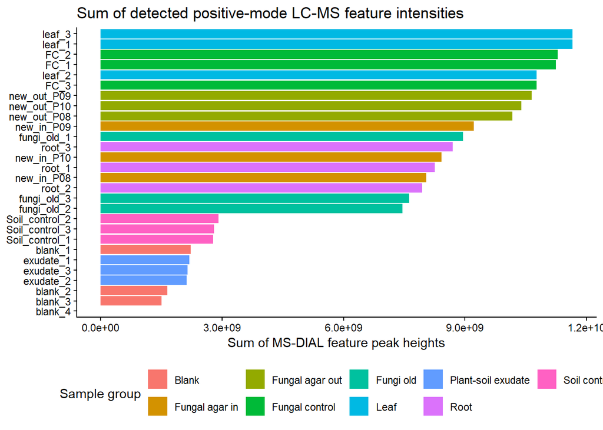

```r
signal_plot <- ggplot(
  sample_qc,
  aes(
    x = reorder(
      sample,
      summed_feature_intensity
    ),
    y = summed_feature_intensity,
    fill = group
  )
) +
  geom_col() +
  coord_flip() +
  labs(
    title =
      "Sum of detected positive-mode LC-MS feature intensities",
    x = NULL,
    y =
      "Sum of MS-DIAL feature peak heights",
    fill = "Sample group"
  ) +
  theme_classic() +
  theme(
    legend.position = "bottom"
  )

signal_plot
```

9. Plot number of detected features

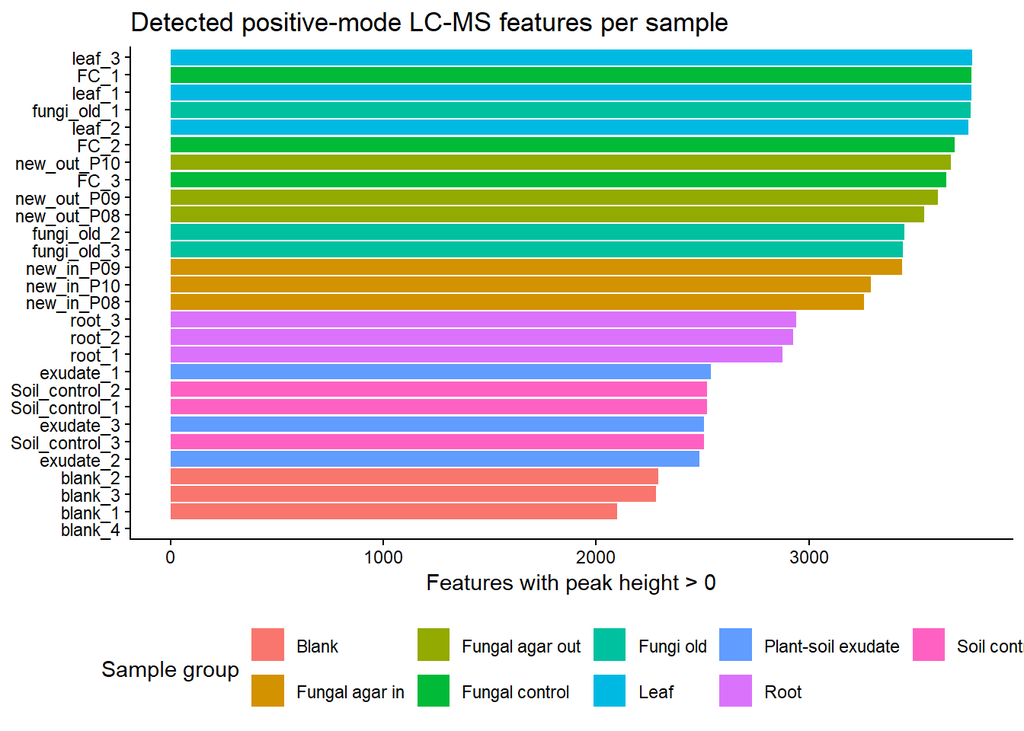

```r
feature_count_plot <- ggplot(
  sample_qc,
  aes(
    x = reorder(
      sample,
      detected_features
    ),
    y = detected_features,
    fill = group
  )
) +
  geom_col() +
  coord_flip() +
  labs(
    title =
      "Detected positive-mode LC-MS features per sample",
    x = NULL,
    y =
      "Features with peak height > 0",
    fill =
      "Sample group"
  ) +
  theme_classic() +
  theme(
    legend.position = "bottom"
  )

feature_count_plot
```

10. Calculate replicate QC and CV

```r
group_qc_summary <- sample_qc %>%
  filter(
    sample != "blank_4"
  ) %>%
  group_by(group) %>%
  summarise(

    n = n(),

    mean_features =
      mean(detected_features),

    sd_features =
      sd(detected_features),

    feature_CV_percent =
      100 *
      sd(detected_features) /
      mean(detected_features),

    mean_summed_signal =
      mean(summed_feature_intensity),

    sd_summed_signal =
      sd(summed_feature_intensity),

    signal_CV_percent =
      100 *
      sd(summed_feature_intensity) /
      mean(summed_feature_intensity),

    .groups = "drop"
  )

group_qc_summary
```

```
## # A tibble: 9 × 8
##   group        n mean_features sd_features feature_CV_percent mean_summed_signal
##   <chr>    <int>         <dbl>       <dbl>              <dbl>              <dbl>
## 1 Blank        3         2225.      108.                4.86         1798105062.
## 2 Fungal …     3         3331.       96.0               2.88         8563940809
## 3 Fungal …     3         3605.       62.0               1.72        10401688175.
## 4 Fungal …     3         3700.       60.7               1.64        11101006531
## 5 Fungi o…     3         3550       183.                5.15         8011949199.
## 6 Leaf         3         3760.       10.3               0.273       11362451996.
## 7 Plant-s…     3         2512        26.6               1.06         2156125555.
## 8 Root         3         2914.       33.8               1.16         8297253366
## 9 Soil co…     3         2516.        9.07              0.361        2833322383.
## # ℹ 2 more variables: sd_summed_signal <dbl>, signal_CV_percent <dbl>
```

11. Build the quantitative feature table

Now we shift from:

What does each sample look like overall?

to:

What happened to each individual LC-MS feature?

I would keep more annotation information now because we’ll need it later.

```r
feature_table <- msdial %>%
  select(

    `Alignment ID`,
    `Average Rt(min)`,
    `Average Mz`,
    `Metabolite name`,
    `Adduct type`,
    `Post curation result`,
    `Fill %`,
    `MS/MS assigned`,

    any_of(c(
      "Reference RT",
      "Reference m/z",
      "Formula",
      "Ontology",
      "INCHIKEY",
      "SMILES",
      "Annotation tag (VS1.0)",
      "RT matched",
      "m/z matched",
      "MS/MS matched",
      "Total score",
      "RT similarity",
      "Dot product",
      "Reverse dot product",
      "Fragment presence %",
      "S/N average"
    )),

    all_of(sample_columns)
  )
```

12. Give every feature a readable unique name

```r
feature_table <- feature_table %>%
  mutate(

    feature_name = paste0(

      "F",
      `Alignment ID`,

      "_mz",
      round(
        `Average Mz`,
        4
      ),

      "_rt",
      round(
        `Average Rt(min)`,
        2
      )
    )
  )
```

Example:

F1540_mz187.1078_rt0.74

means:

MS-DIAL Alignment ID = 1540 m/z ≈ 187.1078 RT ≈ 0.74 min

13. Define usable blanks and biological samples

```r
valid_blank_columns <- c(
  "blank_1",
  "blank_2",
  "blank_3"
)

biological_columns <- setdiff(
  sample_columns,
  c(
    valid_blank_columns,
    "blank_4"
  )
)
```

Check:

```r
length(biological_columns)
```

```
## [1] 24
```

14. Calculate blank/background information for every feature

```r
feature_qc <- feature_table %>%
  mutate(

    blank_mean = rowMeans(
      across(
        all_of(valid_blank_columns)
      ),
      na.rm = TRUE
    ),

    maximum_biological_signal = apply(
      as.matrix(
        pick(
          all_of(biological_columns)
        )
      ),
      1,
      max,
      na.rm = TRUE
    ),

    sample_to_blank_ratio =
      (
        maximum_biological_signal + 1
      ) /
      (
        blank_mean + 1
      )
  )
```

15. Examine different blank thresholds

Before filtering, save a copy:

```r
feature_qc_unfiltered <- feature_qc
```

Then compare 3×, 5× and 10×:

```r
blank_filter_summary <- tibble(

  threshold = c(
    "3x",
    "5x",
    "10x"
  ),

  retained_features = c(

    sum(
      feature_qc_unfiltered$
        sample_to_blank_ratio >= 3,
      na.rm = TRUE
    ),

    sum(
      feature_qc_unfiltered$
        sample_to_blank_ratio >= 5,
      na.rm = TRUE
    ),

    sum(
      feature_qc_unfiltered$
        sample_to_blank_ratio >= 10,
      na.rm = TRUE
    )
  )
)

blank_filter_summary
```

```
## # A tibble: 3 × 2
##   threshold retained_features
##   <chr>                 <int>
## 1 3x                     4274
## 2 5x                     4160
## 3 10x                    4008
```

For our main exploratory analysis:

```r
feature_qc <- feature_qc_unfiltered %>%
  filter(
    sample_to_blank_ratio >= 5
  )
```

This preserves the 5× choice you’ve already used.

16. Group-aware prevalence filter

```r
group_columns <- list(

  exudate = c(
    "exudate_1",
    "exudate_2",
    "exudate_3"
  ),

  fungal_control = c(
    "FC_1",
    "FC_2",
    "FC_3"
  ),

  fungi_old = c(
    "fungi_old_1",
    "fungi_old_2",
    "fungi_old_3"
  ),

  leaf = c(
    "leaf_1",
    "leaf_2",
    "leaf_3"
  ),

  fungal_agar_in = c(
    "new_in_P08",
    "new_in_P09",
    "new_in_P10"
  ),

  fungal_agar_out = c(
    "new_out_P08",
    "new_out_P09",
    "new_out_P10"
  ),

  root = c(
    "root_1",
    "root_2",
    "root_3"
  ),

  soil_control = c(
    "Soil_control_1",
    "Soil_control_2",
    "Soil_control_3"
  )
)
```

The group-specific rule is better.

Calculate detection:

```r
presence_by_group <- sapply(

  group_columns,

  function(cols) {

    rowSums(
      as.matrix(
        feature_qc[, cols]
      ) > 0,
      na.rm = TRUE
    ) >= 2
  }
)
```

Keep features detected in at least 2 of 3 replicates in at least one biological group:

```r
feature_qc$present_in_any_group <-
  apply(
    presence_by_group,
    1,
    any
  )

feature_qc <- feature_qc %>%
  filter(
    present_in_any_group
  )
```

Now calculate overall detection count just for reporting:

```r
feature_qc <- feature_qc %>%
  mutate(

    number_detected = rowSums(

      across(
        all_of(biological_columns),
        ~ .x > 0
      ),

      na.rm = TRUE
    )
  )
```

Check filtering:

```r
nrow(feature_table)
```

```
## [1] 5169
```

```r
nrow(feature_qc)
```

```
## [1] 4144
```

17. Build the PCA intensity matrix

```r
intensity_matrix <- feature_qc %>%
  select(
    feature_name,
    all_of(biological_columns)
  ) %>%
  column_to_rownames(
    "feature_name"
  ) %>%
  as.matrix()
```

Transpose:

```r
pca_matrix_raw <- t(
  intensity_matrix
)

dim(pca_matrix_raw)
```

```
## [1]   24 4144
```

Now:

rows = samples columns = LC-MS features.

18. Replace zeros

For PCA only, replace zeros/missing values with half of that feature’s smallest positive measurement.

```r
replace_zero_half_min <- function(x) {

  positive_values <-
    x[
      x > 0 &
        is.finite(x)
    ]

  if (
    length(positive_values) == 0
  ) {

    return(
      rep(
        NA_real_,
        length(x)
      )
    )
  }

  replacement <-
    min(positive_values) / 2

  x[
    x == 0 |
      is.na(x)
  ] <- replacement

  x
}
```

Apply:

```r
pca_matrix_imputed <- apply(
  pca_matrix_raw,
  2,
  replace_zero_half_min
)
```

Remove anything that still cannot be analyzed:

```r
pca_matrix_imputed <-
  pca_matrix_imputed[
    ,
    colSums(
      is.na(
        pca_matrix_imputed
      )
    ) == 0,
    drop = FALSE
  ]
```

19. Median normalize

We’re choosing one normalization method for this pipeline.

Your previous code calculated median normalization and TIC normalization but then only used median normalization.

So remove the unused TIC block.

```r
sample_medians <- apply(
  pca_matrix_imputed,
  1,
  median,
  na.rm = TRUE
)

global_median <-
  median(
    sample_medians
  )

pca_matrix_normalized <- sweep(
  pca_matrix_imputed,
  1,
  sample_medians,
  "/"
) * global_median
```

20. Log2 transformation

```r
pca_matrix_log <- log2(
  pca_matrix_normalized + 1
)
```

21. Remove zero-variance features

```r
feature_variance <- apply(
  pca_matrix_log,
  2,
  var,
  na.rm = TRUE
)

keep_variable_features <-
  is.finite(
    feature_variance
  ) &
  feature_variance > 0

pca_matrix_log <-
  pca_matrix_log[
    ,
    keep_variable_features,
    drop = FALSE
  ]
```

22. Run broad PCA

```r
pca_result <- prcomp(
  pca_matrix_log,
  center = TRUE,
  scale. = TRUE
)

summary(pca_result)
```

```
## Importance of components:
##                            PC1     PC2      PC3      PC4      PC5    PC6    PC7
## Standard deviation     44.3057 30.5913 19.32190 17.40387 11.82203 7.5345 6.8138
## Proportion of Variance  0.4737  0.2258  0.09009  0.07309  0.03373 0.0137 0.0112
## Cumulative Proportion   0.4737  0.6995  0.78961  0.86270  0.89643 0.9101 0.9213
##                            PC8     PC9    PC10    PC11    PC12   PC13   PC14
## Standard deviation     6.04376 5.88750 5.65514 5.27158 5.06108 4.9463 4.5971
## Proportion of Variance 0.00881 0.00836 0.00772 0.00671 0.00618 0.0059 0.0051
## Cumulative Proportion  0.93015 0.93851 0.94623 0.95294 0.95912 0.9650 0.9701
##                           PC15    PC16    PC17    PC18    PC19    PC20    PC21
## Standard deviation     4.52484 4.49582 4.24552 4.12879 3.61444 3.32005 3.02688
## Proportion of Variance 0.00494 0.00488 0.00435 0.00411 0.00315 0.00266 0.00221
## Cumulative Proportion  0.97506 0.97994 0.98429 0.98840 0.99155 0.99421 0.99643
##                          PC22    PC23      PC24
## Standard deviation     2.8788 2.55433 3.718e-14
## Proportion of Variance 0.0020 0.00157 0.000e+00
## Cumulative Proportion  0.9984 1.00000 1.000e+00
```

23. Variance explained

```r
variance_explained <-
  (
    pca_result$sdev^2 /
      sum(
        pca_result$sdev^2
      )
  ) * 100

variance_explained[1:10]
```

```
##  [1] 47.3695252 22.5826592  9.0090698  7.3092390  3.3725985  1.3699149
##  [7]  1.1203796  0.8814433  0.8364539  0.7717335
```

Create table:

```r
variance_table <- tibble(

  PC = paste0(
    "PC",
    seq_along(
      variance_explained
    )
  ),

  variance_percent =
    variance_explained,

  cumulative_percent =
    cumsum(
      variance_explained
    )
)

head(
  variance_table,
  10
)
```

```
## # A tibble: 10 × 3
##    PC    variance_percent cumulative_percent
##    <chr>            <dbl>              <dbl>
##  1 PC1             47.4                 47.4
##  2 PC2             22.6                 70.0
##  3 PC3              9.01                79.0
##  4 PC4              7.31                86.3
##  5 PC5              3.37                89.6
##  6 PC6              1.37                91.0
##  7 PC7              1.12                92.1
##  8 PC8              0.881               93.0
##  9 PC9              0.836               93.9
## 10 PC10             0.772               94.6
```

24. PCA sample scores

```r
pca_scores <-
  as.data.frame(
    pca_result$x
  ) %>%
  rownames_to_column(
    "sample"
  ) %>%
  left_join(
    sample_metadata,
    by = "sample"
  )
```

25. Broad PC1 versus PC2 plot

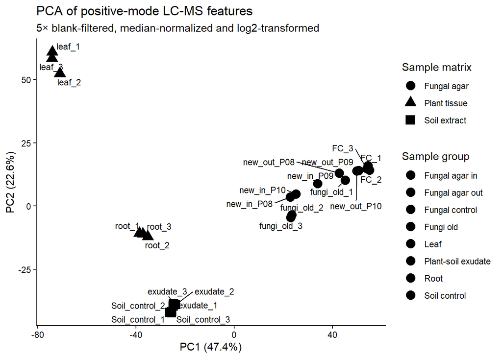

```r
broad_pca_plot <- ggplot(
  pca_scores,
  aes(
    x = PC1,
    y = PC2,
    fill = group,
    shape = broad_matrix
  )
) +
  geom_point(
    size = 4,
    color = "black"
  ) +
  geom_text_repel(
    aes(label = sample),
    size = 3,
    max.overlaps = Inf
  ) +
  labs(

    title =
      "PCA of positive-mode LC-MS features",

    subtitle =
      "5× blank-filtered, median-normalized and log2-transformed",

    x = paste0(
      "PC1 (",
      round(
        variance_explained[1],
        1
      ),
      "%)"
    ),

    y = paste0(
      "PC2 (",
      round(
        variance_explained[2],
        1
      ),
      "%)"
    ),

    fill =
      "Sample group",

    shape =
      "Sample matrix"
  ) +
  theme_classic()

broad_pca_plot
```

26. PC1 vs PC3

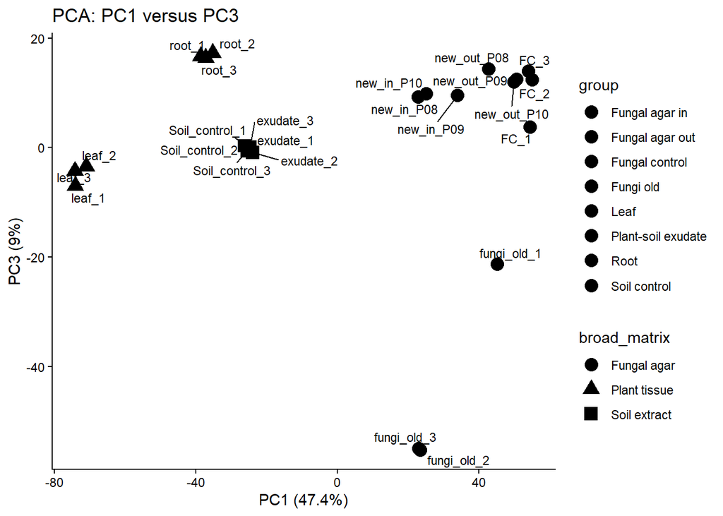

```r
pc1_pc3_plot <- ggplot(
  pca_scores,
  aes(
    x = PC1,
    y = PC3,
    fill = group,
    shape = broad_matrix
  )
) +
  geom_point(
    size = 4,
    color = "black"
  ) +
  geom_text_repel(
    aes(label = sample),
    size = 3,
    max.overlaps = Inf
  ) +
  labs(

    title =
      "PCA: PC1 versus PC3",

    x = paste0(
      "PC1 (",
      round(
        variance_explained[1],
        1
      ),
      "%)"
    ),

    y = paste0(
      "PC3 (",
      round(
        variance_explained[3],
        1
      ),
      "%)"
    )
  ) +
  theme_classic()

pc1_pc3_plot
```

27. Scree plot

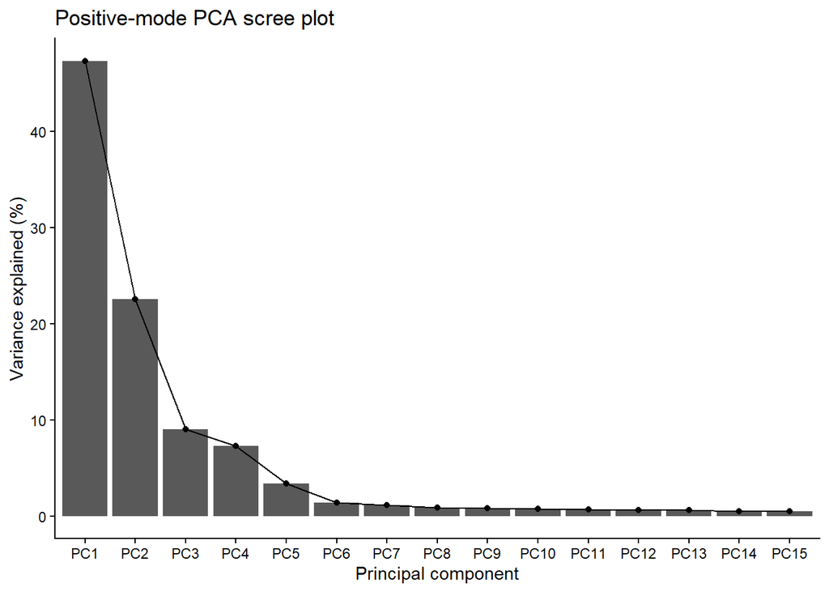

```r
scree_plot <- variance_table %>%
  slice_head(
    n = 15
  ) %>%
  ggplot(
    aes(
      x = factor(
        PC,
        levels = PC
      ),
      y = variance_percent,
      group = 1
    )
  ) +
  geom_col() +
  geom_point() +
  geom_line() +
  labs(
    title =
      "Positive-mode PCA scree plot",
    x =
      "Principal component",
    y =
      "Variance explained (%)"
  ) +
  theme_classic()

scree_plot
```

28. Create reusable focused-PCA function

Instead of repeating the same code three times:

```r
run_focused_pca <- function(
    groups_to_use,
    title_text
) {

  samples_to_use <-
    sample_metadata %>%
    filter(
      group %in% groups_to_use
    ) %>%
    pull(sample)

  matrix_subset <-
    pca_matrix_log[
      samples_to_use,
      ,
      drop = FALSE
    ]

  variances <- apply(
    matrix_subset,
    2,
    var,
    na.rm = TRUE
  )

  matrix_subset <-
    matrix_subset[
      ,
      is.finite(variances) &
        variances > 0,
      drop = FALSE
    ]

  result <- prcomp(
    matrix_subset,
    center = TRUE,
    scale. = TRUE
  )

  variance <-
    (
      result$sdev^2 /
        sum(
          result$sdev^2
        )
    ) * 100

  scores <-
    as.data.frame(
      result$x
    ) %>%
    rownames_to_column(
      "sample"
    ) %>%
    left_join(
      sample_metadata,
      by = "sample"
    )

  plot <- ggplot(
    scores,
    aes(
      x = PC1,
      y = PC2,
      fill = group
    )
  ) +
    geom_point(
      shape = 21,
      size = 5,
      color = "black"
    ) +
    geom_text_repel(
      aes(label = sample)
    ) +
    labs(
      title = title_text,

      x = paste0(
        "PC1 (",
        round(
          variance[1],
          1
        ),
        "%)"
      ),

      y = paste0(
        "PC2 (",
        round(
          variance[2],
          1
        ),
        "%)"
      )
    ) +
    theme_classic()

  list(
    pca = result,
    scores = scores,
    variance = variance,
    plot = plot
  )
}
```

29. Exudate versus soil PCA

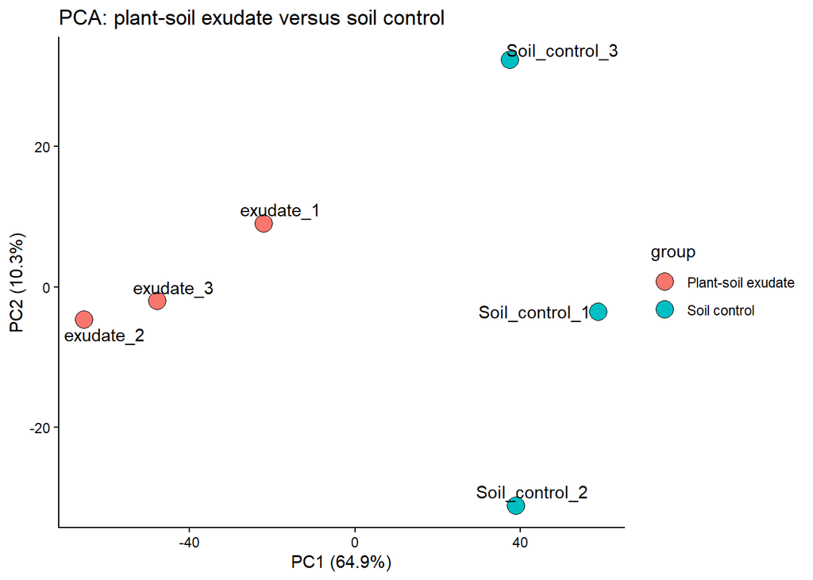

```r
exudate_soil_pca <-
  run_focused_pca(
    groups_to_use = c(
      "Plant-soil exudate",
      "Soil control"
    ),
    title_text =
      "PCA: plant-soil exudate versus soil control"
  )

exudate_soil_pca$plot
```

30. Fungal agar PCA

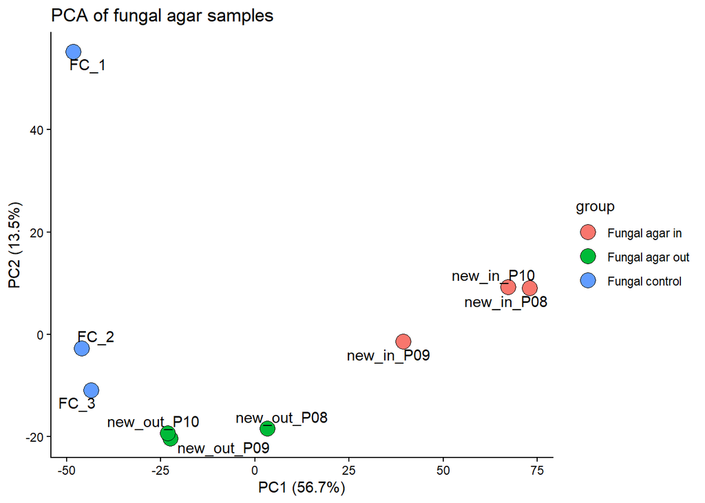

```r
fungal_pca <-
  run_focused_pca(
    groups_to_use = c(
      "Fungal control",
      "Fungal agar in",
      "Fungal agar out"
    ),
    title_text =
      "PCA of fungal agar samples"
  )

fungal_pca$plot
```

31. Leaf versus root PCA

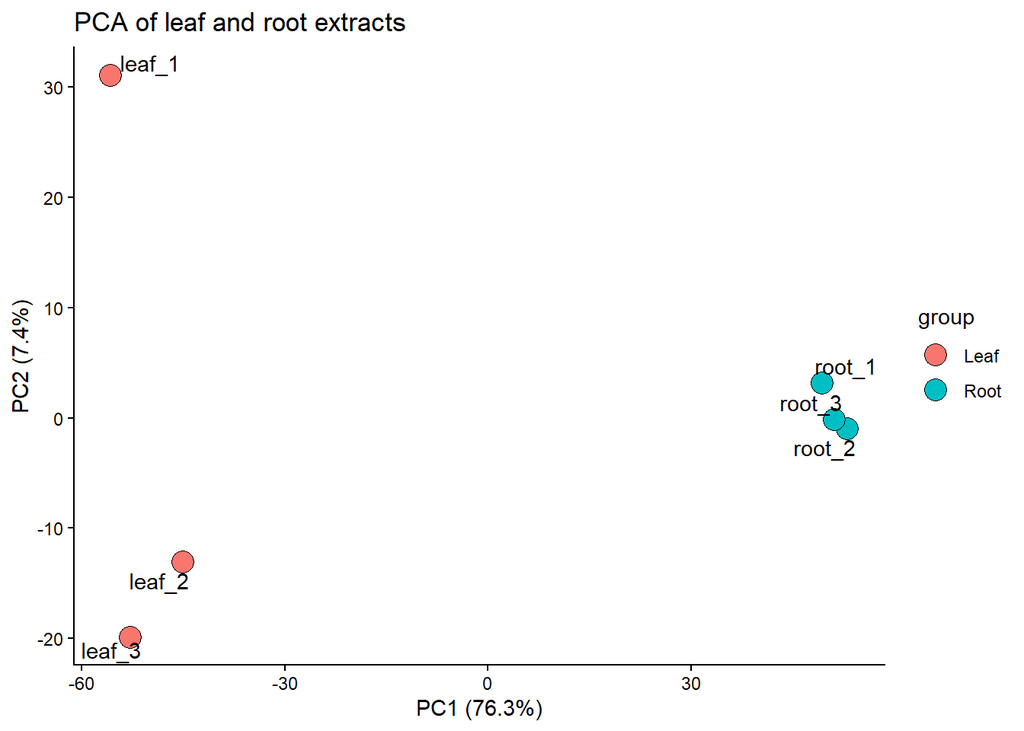

```r
tissue_pca <-
  run_focused_pca(
    groups_to_use = c(
      "Leaf",
      "Root"
    ),
    title_text =
      "PCA of leaf and root extracts"
  )

tissue_pca$plot
```

32. Extract PCA loadings

```r
pca_loadings <-
  as.data.frame(
    pca_result$rotation
  ) %>%
  rownames_to_column(
    "feature_name"
  )
```

Create annotation table:

```r
feature_annotations <- feature_qc %>%
  select(
    feature_name,
    `Alignment ID`,
    `Average Rt(min)`,
    `Average Mz`,
    `Metabolite name`,
    `Adduct type`,
    `Post curation result`,
    `Fill %`,
    `MS/MS assigned`,
    any_of(c(
      "Formula",
      "Ontology",
      "INCHIKEY",
      "SMILES",
      "Annotation tag (VS1.0)",
      "RT matched",
      "m/z matched",
      "MS/MS matched",
      "Total score",
      "RT similarity",
      "Dot product",
      "Reverse dot product",
      "Fragment presence %",
      "S/N average"
    )),
    blank_mean,
    sample_to_blank_ratio,
    number_detected
  )
```

Join:

```r
pca_loadings <- pca_loadings %>%
  left_join(
    feature_annotations,
    by = "feature_name"
  )
```

33. Identify strongest PC1, PC2 and PC3 features

Reusable function:

```r
get_top_loadings <- function(
    loading_table,
    pc_column,
    number_to_keep = 30
) {

  loading_table %>%
    mutate(
      selected_loading =
        .data[[pc_column]],

      absolute_loading =
        abs(
          .data[[pc_column]]
        )
    ) %>%
    arrange(
      desc(
        absolute_loading
      )
    ) %>%
    slice_head(
      n = number_to_keep
    )
}
```

Run:

```r
top_pc1_loadings <-
  get_top_loadings(
    pca_loadings,
    "PC1"
  )

top_pc2_loadings <-
  get_top_loadings(
    pca_loadings,
    "PC2"
  )

top_pc3_loadings <-
  get_top_loadings(
    pca_loadings,
    "PC3"
  )
```

Inspect:

```r
top_pc1_loadings %>%
  select(
    feature_name,
    PC1,
    `Average Rt(min)`,
    `Average Mz`,
    `Metabolite name`,
    `Adduct type`,
    `MS/MS assigned`,
    `Total score`,
    sample_to_blank_ratio
  )
```

```
##               feature_name         PC1 Average Rt(min) Average Mz
## 1  F1540_mz187.1078_rt0.74  0.02248574           0.738   187.1078
## 2   F2962_mz290.135_rt0.76  0.02245567           0.757   290.1350
## 3  F2947_mz289.2165_rt2.58 -0.02244972           2.575   289.2165
## 4   F4792_mz574.2658_rt1.2 -0.02244366           1.196   574.2658
## 5   F2509_mz258.109_rt0.71  0.02243978           0.710   258.1089
## 6     F3171_mz305.0661_rt1 -0.02243147           1.002   305.0661
## 7  F2476_mz255.2112_rt5.92 -0.02241575           5.916   255.2112
## 8   F4171_mz407.117_rt0.49 -0.02240368           0.486   407.1170
## 9  F1813_mz205.1186_rt0.83  0.02239955           0.827   205.1186
## 10 F3627_mz346.1979_rt1.02  0.02239104           1.020   346.1979
## 11 F2017_mz219.1343_rt0.78  0.02236977           0.782   219.1343
## 12 F4147_mz403.2455_rt2.58 -0.02235985           2.576   403.2455
## 13 F4736_mz546.3563_rt3.71 -0.02235006           3.707   546.3563
## 14  F998_mz147.5556_rt0.46 -0.02234104           0.457   147.5556
```

[output cut: 47 more lines]

And:

```r
top_pc2_loadings %>%
  select(
    feature_name,
    PC2,
    `Average Rt(min)`,
    `Average Mz`,
    `Metabolite name`,
    `Adduct type`,
    `MS/MS assigned`,
    `Total score`,
    sample_to_blank_ratio
  )
```

```
##               feature_name         PC2 Average Rt(min) Average Mz
## 1   F1302_mz170.958_rt0.41 -0.03219109           0.411   170.9580
## 2  F3103_mz301.1627_rt0.42 -0.03212591           0.421   301.1627
## 3  F2031_mz220.9355_rt0.41 -0.03207162           0.408   220.9355
## 4  F3166_mz304.8961_rt0.41 -0.03180513           0.413   304.8961
## 5  F3905_mz372.8828_rt0.41 -0.03150581           0.412   372.8828
## 6  F3507_mz334.9143_rt0.41 -0.03146620           0.410   334.9143
## 7  F1057_mz152.9473_rt0.41 -0.03133150           0.410   152.9473
## 8   F2611_mz266.928_rt0.41 -0.03122706           0.406   266.9280
## 9  F4140_mz402.9017_rt0.41 -0.03120089           0.408   402.9017
## 10 F1803_mz204.9574_rt0.41 -0.03088462           0.410   204.9574
## 11 F1021_mz149.1073_rt0.66 -0.03079202           0.659   149.1073
## 12  F4421_mz449.349_rt2.14 -0.03074170           2.140   449.3490
## 13 F4264_mz421.3178_rt2.14 -0.03071827           2.140   421.3178
## 14 F4248_mz418.8769_rt0.41 -0.03061512           0.410   418.8769
```

[output cut: 47 more lines]

34. Check suspicious very-early RT loadings

This is important because we previously noticed many high-loading features around RT 0.4–0.8 min.

Don’t automatically delete them yet.

Quantify them first:

```r
pca_loadings %>%
  mutate(
    important_PC12 =
      pmax(
        abs(PC1),
        abs(PC2)
      )
  ) %>%
  arrange(
    desc(
      important_PC12
    )
  ) %>%
  slice_head(
    n = 100
  ) %>%
  count(
    early_RT =
      `Average Rt(min)` < 1
  )
```

```
##   early_RT  n
## 1    FALSE 10
## 2     TRUE 90
```

And inspect:

```r
pca_loadings %>%
  filter(
    `Average Rt(min)` < 1
  ) %>%
  arrange(
    desc(
      abs(PC1)
    )
  ) %>%
  select(
    feature_name,
    `Average Rt(min)`,
    `Average Mz`,
    `Metabolite name`,
    PC1,
    PC2,
    sample_to_blank_ratio
  ) %>%
  head(30)
```

```
##               feature_name Average Rt(min) Average Mz Metabolite name
## 1  F1540_mz187.1078_rt0.74           0.738   187.1078         Unknown
## 2   F2962_mz290.135_rt0.76           0.757   290.1350         Unknown
## 3   F2509_mz258.109_rt0.71           0.710   258.1089         Unknown
## 4   F4171_mz407.117_rt0.49           0.486   407.1170         Unknown
## 5  F1813_mz205.1186_rt0.83           0.827   205.1186         Unknown
## 6  F2017_mz219.1343_rt0.78           0.782   219.1343         Unknown
## 7   F998_mz147.5556_rt0.46           0.457   147.5556         Unknown
## 8  F3269_mz314.2084_rt0.97           0.971   314.2084         Unknown
## 9  F3477_mz332.1817_rt0.98           0.976   332.1817         Unknown
## 10 F2598_mz265.1122_rt0.48           0.478   265.1121         Unknown
## 11 F3561_mz339.0598_rt0.53           0.533   339.0598         Unknown
## 12 F1393_mz176.1646_rt0.92           0.920   176.1646         Unknown
## 13  F4447_mz456.2082_rt0.9           0.897   456.2082         Unknown
## 14 F2628_mz267.8584_rt0.42           0.416   267.8584         Unknown
```

[output cut: 47 more lines]

This should happen before interpreting PCA-driving metabolites.

35. Create combined PCA candidate table

```r
important_pca_features <-
  pca_loadings %>%
  mutate(

    maximum_absolute_loading =
      pmax(
        abs(PC1),
        abs(PC2),
        abs(PC3),
        na.rm = TRUE
      )

  ) %>%
  arrange(
    desc(
      maximum_absolute_loading
    )
  )
```

Inspect top 50:

```r
important_pca_features %>%
  slice_head(
    n = 50
  )
```

```
##               feature_name           PC1           PC2         PC3
## 1  F2021_mz219.1749_rt1.21 -0.0023124257 -0.0031873182 -0.04765649
## 2    F181_mz86.0602_rt0.45  0.0035232699 -0.0020643142  0.04751207
## 3  F2587_mz264.0986_rt1.08 -0.0008101837  0.0047912913 -0.04657358
## 4  F1754_mz201.1642_rt1.21 -0.0009097643 -0.0063153075 -0.04619582
## 5   F362_mz104.0707_rt0.55 -0.0059197744  0.0018646139  0.04479748
## 6  F3461_mz331.1297_rt1.01  0.0055679372  0.0062541742 -0.04433748
## 7     F1765_mz202.1078_rt1  0.0071619844 -0.0057968487 -0.04425191
## 8   F1789_mz203.1798_rt1.6 -0.0001207470 -0.0108908202 -0.04380014
## 9   F958_mz145.1015_rt1.21 -0.0077919335 -0.0011051580 -0.04377972
## 10  F2350_mz245.181_rt0.44 -0.0016008983  0.0024934151 -0.04375792
## 11 F2125_mz227.1434_rt1.54  0.0006878993 -0.0129972221 -0.04366255
## 12  F2323_mz244.095_rt1.18  0.0096405515  0.0022942639 -0.04359272
## 13 F3172_mz305.1348_rt0.66 -0.0011750135  0.0004084759 -0.04310667
## 14   F259_mz97.0286_rt1.01  0.0032809710 -0.0079873596 -0.04306262
```

[output cut: 648 more lines]

36. PCA feature heatmap

Since the annotated pheatmap continues to fail and the unannotated version works, leave the annotation problem alone for now. It is not blocking the analysis.

```r
top_feature_names <-
  important_pca_features %>%
  slice_head(
    n = 30
  ) %>%
  pull(
    feature_name
  )

heatmap_matrix <-
  t(
    pca_matrix_log[
      ,
      top_feature_names,
      drop = FALSE
    ]
  )
```

Plot:

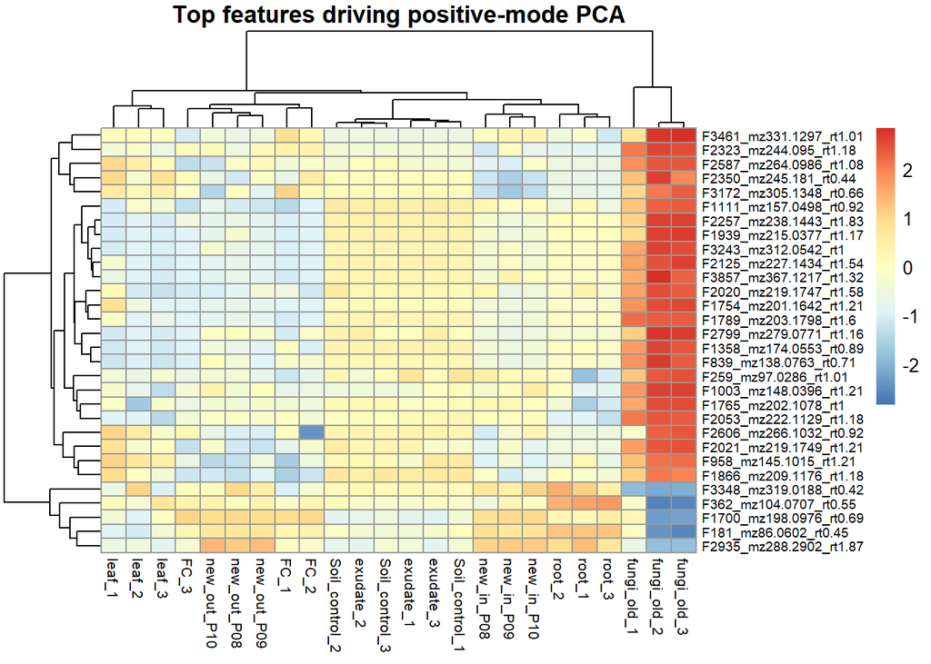

```r
pheatmap(
  heatmap_matrix,
  scale = "row",
  clustering_distance_rows =
    "euclidean",
  clustering_distance_cols =
    "euclidean",
  clustering_method =
    "complete",
  show_rownames = TRUE,
  show_colnames = TRUE,
  fontsize_row = 7,
  fontsize_col = 8,
  main =
    "Top features driving positive-mode PCA"
)
```

Your previous unannotated heatmap is the one that successfully rendered.

37. Presence/absence analysis across biological groups

Use feature_qc, not the imputed PCA matrix. Presence/absence must be based on actual observed peak heights.

First define all sample groups:

# ————————————————————

# PRESENCE / ABSENCE ANALYSIS

# ————————————————————

# Define sample columns for each biological group

```r
presence_groups <- list(

  Exudate = c(
    "exudate_1",
    "exudate_2",
    "exudate_3"
  ),

  Soil = c(
    "Soil_control_1",
    "Soil_control_2",
    "Soil_control_3"
  ),

  Leaf = c(
    "leaf_1",
    "leaf_2",
    "leaf_3"
  ),

  Root = c(
    "root_1",
    "root_2",
    "root_3"
  ),

  Fungal_in = c(
    "new_in_P08",
    "new_in_P09",
    "new_in_P10"
  ),

  Fungal_out = c(
    "new_out_P08",
    "new_out_P09",
    "new_out_P10"
  ),

  Fungal_control = c(
    "FC_1",
    "FC_2",
    "FC_3"
  ),

  Fungi_old = c(
    "fungi_old_1",
    "fungi_old_2",
    "fungi_old_3"
  )
)
```

38. Function for any pairwise presence/absence comparison

We’ll define a feature as present when it occurs in at least 2 of 3 biological replicates.

```r
run_presence_comparison <- function(
    data,
    group1_cols,
    group2_cols,
    group1_name,
    group2_name,
    min_replicates = 2
) {

  result <- data %>%
    mutate(

      group1_detected_n = rowSums(
        across(
          all_of(group1_cols),
          ~ .x > 0
        ),
        na.rm = TRUE
      ),

      group2_detected_n = rowSums(
        across(
          all_of(group2_cols),
          ~ .x > 0
        ),
        na.rm = TRUE
      ),

      group1_present =
        group1_detected_n >= min_replicates,

      group2_present =
        group2_detected_n >= min_replicates,

      presence_category = case_when(

        group1_present &
          group2_present ~
          "Shared",

        group1_present &
          !group2_present ~
          paste0(
            group1_name,
            " only"
          ),

        !group1_present &
          group2_present ~
          paste0(
            group2_name,
            " only"
          ),

        TRUE ~
          "Neither consistently detected"
      )
    )

  summary <- result %>%
    count(
      presence_category
    ) %>%
    mutate(

      percent =
        100 * n / sum(n),

      comparison =
        paste0(
          group1_name,
          " vs ",
          group2_name
        )
    ) %>%
    select(
      comparison,
      presence_category,
      n,
      percent
    )

  return(
    list(
      feature_table = result,
      summary = summary
    )
  )
}
```

39. Exudate vs soil

This asks:

Which features appear with the plant-containing soil extraction compared with soil alone?

```r
presence_exudate_soil <-
  run_presence_comparison(

    data = feature_qc,

    group1_cols =
      presence_groups$Exudate,

    group2_cols =
      presence_groups$Soil,

    group1_name =
      "Exudate",

    group2_name =
      "Soil"
  )

presence_exudate_soil$summary
```

```
## # A tibble: 4 × 4
##   comparison      presence_category                 n percent
##   <chr>           <chr>                         <int>   <dbl>
## 1 Exudate vs Soil Exudate only                    129    3.11
## 2 Exudate vs Soil Neither consistently detected  2505   60.4
## 3 Exudate vs Soil Shared                         1386   33.4
## 4 Exudate vs Soil Soil only                       124    2.99
```

40. Leaf vs root

This asks:

Which features are shared between aboveground and belowground plant tissue, and which are tissue-associated?

```r
presence_leaf_root <-
  run_presence_comparison(

    data = feature_qc,

    group1_cols =
      presence_groups$Leaf,

    group2_cols =
      presence_groups$Root,

    group1_name =
      "Leaf",

    group2_name =
      "Root"
  )

presence_leaf_root$summary
```

```
## # A tibble: 4 × 4
##   comparison   presence_category                 n percent
##   <chr>        <chr>                         <int>   <dbl>
## 1 Leaf vs Root Leaf only                      1024   24.7
## 2 Leaf vs Root Neither consistently detected  1162   28.0
## 3 Leaf vs Root Root only                       153    3.69
## 4 Leaf vs Root Shared                         1805   43.6
```

41. Exudate vs root

Yes, I definitely want this comparison.

It asks:

Which features detected in roots are also detectable in the plant-soil extract?

```r
presence_exudate_root <-
  run_presence_comparison(

    data = feature_qc,

    group1_cols =
      presence_groups$Exudate,

    group2_cols =
      presence_groups$Root,

    group1_name =
      "Exudate",

    group2_name =
      "Root"
  )

presence_exudate_root$summary
```

```
## # A tibble: 4 × 4
##   comparison      presence_category                 n percent
##   <chr>           <chr>                         <int>   <dbl>
## 1 Exudate vs Root Exudate only                    401    9.68
## 2 Exudate vs Root Neither consistently detected  1785   43.1
## 3 Exudate vs Root Root only                       844   20.4
## 4 Exudate vs Root Shared                         1114   26.9
```

A feature classified as:

Shared

means it occurred in ≥2/3 exudates and ≥2/3 roots.

That is potentially interesting.

But:

shared ≠ secreted.

It only establishes chemical correspondence at the aligned-feature level.

42. Exudate vs leaf

This comparison is also worthwhile:

```r
presence_exudate_leaf <-
  run_presence_comparison(

    data = feature_qc,

    group1_cols =
      presence_groups$Exudate,

    group2_cols =
      presence_groups$Leaf,

    group1_name =
      "Exudate",

    group2_name =
      "Leaf"
  )

presence_exudate_leaf$summary
```

```
## # A tibble: 4 × 4
##   comparison      presence_category                 n percent
##   <chr>           <chr>                         <int>   <dbl>
## 1 Exudate vs Leaf Exudate only                    301    7.26
## 2 Exudate vs Leaf Leaf only                      1615   39.0
## 3 Exudate vs Leaf Neither consistently detected  1014   24.5
## 4 Exudate vs Leaf Shared                         1214   29.3
```

This can help distinguish whether exudate-associated signals resemble general plant chemistry or are more strongly associated with roots.

43. Fungal agar in vs out

```r
presence_fungal_in_out <-
  run_presence_comparison(

    data = feature_qc,

    group1_cols =
      presence_groups$Fungal_in,

    group2_cols =
      presence_groups$Fungal_out,

    group1_name =
      "Fungal in",

    group2_name =
      "Fungal out"
  )

presence_fungal_in_out$summary
```

```
## # A tibble: 4 × 4
##   comparison              presence_category                 n percent
##   <chr>                   <chr>                         <int>   <dbl>
## 1 Fungal in vs Fungal out Fungal in only                   89    2.15
## 2 Fungal in vs Fungal out Fungal out only                 378    9.12
## 3 Fungal in vs Fungal out Neither consistently detected  1387   33.5
## 4 Fungal in vs Fungal out Shared                         2290   55.3
```

44. Fungal agar in vs agar control

```r
presence_fungal_in_control <-
  run_presence_comparison(

    data = feature_qc,

    group1_cols =
      presence_groups$Fungal_in,

    group2_cols =
      presence_groups$Fungal_control,

    group1_name =
      "Fungal in",

    group2_name =
      "Fungal control"
  )

presence_fungal_in_control$summary
```

```
## # A tibble: 4 × 4
##   comparison                  presence_category                 n percent
##   <chr>                       <chr>                         <int>   <dbl>
## 1 Fungal in vs Fungal control Fungal control only             482   11.6
## 2 Fungal in vs Fungal control Fungal in only                  109    2.63
## 3 Fungal in vs Fungal control Neither consistently detected  1283   31.0
## 4 Fungal in vs Fungal control Shared                         2270   54.8
```

45. Fungal agar out vs agar control

I would add this too.

It tells us whether the region outside visible fungal growth has nevertheless been chemically altered relative to the control.

```r
presence_fungal_out_control <-
  run_presence_comparison(

    data = feature_qc,

    group1_cols =
      presence_groups$Fungal_out,

    group2_cols =
      presence_groups$Fungal_control,

    group1_name =
      "Fungal out",

    group2_name =
      "Fungal control"
  )

presence_fungal_out_control$summary
```

```
## # A tibble: 4 × 4
##   comparison                   presence_category                 n percent
##   <chr>                        <chr>                         <int>   <dbl>
## 1 Fungal out vs Fungal control Fungal control only             196    4.73
## 2 Fungal out vs Fungal control Fungal out only                 112    2.70
## 3 Fungal out vs Fungal control Neither consistently detected  1280   30.9
## 4 Fungal out vs Fungal control Shared                         2556   61.7
```

That could actually be biologically interesting if diffusible metabolites extend beyond the visible colony.

46. Combine all pairwise presence results

```r
presence_summary_all <- bind_rows(

  presence_exudate_soil$summary,

  presence_leaf_root$summary,

  presence_exudate_root$summary,

  presence_exudate_leaf$summary,

  presence_fungal_in_out$summary,

  presence_fungal_in_control$summary,

  presence_fungal_out_control$summary
)

presence_summary_all
```

```
## # A tibble: 28 × 4
##    comparison      presence_category                 n percent
##    <chr>           <chr>                         <int>   <dbl>
##  1 Exudate vs Soil Exudate only                    129    3.11
##  2 Exudate vs Soil Neither consistently detected  2505   60.4
##  3 Exudate vs Soil Shared                         1386   33.4
##  4 Exudate vs Soil Soil only                       124    2.99
##  5 Leaf vs Root    Leaf only                      1024   24.7
##  6 Leaf vs Root    Neither consistently detected  1162   28.0
##  7 Leaf vs Root    Root only                       153    3.69
##  8 Leaf vs Root    Shared                         1805   43.6
##  9 Exudate vs Root Exudate only                    401    9.68
## 10 Exudate vs Root Neither consistently detected  1785   43.1
## # ℹ 18 more rows
```

Sort it:

```r
presence_summary_all <- presence_summary_all %>%
  arrange(
    comparison,
    desc(n)
  )

presence_summary_all
```

```
## # A tibble: 28 × 4
##    comparison      presence_category                 n percent
##    <chr>           <chr>                         <int>   <dbl>
##  1 Exudate vs Leaf Leaf only                      1615   39.0
##  2 Exudate vs Leaf Shared                         1214   29.3
##  3 Exudate vs Leaf Neither consistently detected  1014   24.5
##  4 Exudate vs Leaf Exudate only                    301    7.26
##  5 Exudate vs Root Neither consistently detected  1785   43.1
##  6 Exudate vs Root Shared                         1114   26.9
##  7 Exudate vs Root Root only                       844   20.4
##  8 Exudate vs Root Exudate only                    401    9.68
##  9 Exudate vs Soil Neither consistently detected  2505   60.4
## 10 Exudate vs Soil Shared                         1386   33.4
## # ℹ 18 more rows
```

Save:

```r
write.csv(
  presence_summary_all,
  "positive_mode_presence_absence_summary.csv",
  row.names = FALSE
)
```

47. Now do the more interesting three-way plant analysis

Pairwise comparisons are useful, but what you’re proposing is actually better expressed as:

Which features occur across leaf → root → exudate?

Let’s calculate presence in all three.

```r
plant_compartment_presence <- feature_qc %>%
  mutate(

    leaf_detected_n =
      rowSums(
        across(
          all_of(
            presence_groups$Leaf
          ),
          ~ .x > 0
        ),
        na.rm = TRUE
      ),

    root_detected_n =
      rowSums(
        across(
          all_of(
            presence_groups$Root
          ),
          ~ .x > 0
        ),
        na.rm = TRUE
      ),

    exudate_detected_n =
      rowSums(
        across(
          all_of(
            presence_groups$Exudate
          ),
          ~ .x > 0
        ),
        na.rm = TRUE
      ),

    soil_detected_n =
      rowSums(
        across(
          all_of(
            presence_groups$Soil
          ),
          ~ .x > 0
        ),
        na.rm = TRUE
      ),

    leaf_present =
      leaf_detected_n >= 2,

    root_present =
      root_detected_n >= 2,

    exudate_present =
      exudate_detected_n >= 2,

    soil_present =
      soil_detected_n >= 2
  )
```

48. Classify plant-compartment patterns

```r
plant_compartment_presence <-
  plant_compartment_presence %>%
  mutate(

    plant_pattern =
      case_when(

        leaf_present &
          root_present &
          exudate_present ~
          "Leaf + Root + Exudate",

        !leaf_present &
          root_present &
          exudate_present ~
          "Root + Exudate",

        leaf_present &
          !root_present &
          exudate_present ~
          "Leaf + Exudate",

        leaf_present &
          root_present &
          !exudate_present ~
          "Leaf + Root",

        leaf_present &
          !root_present &
          !exudate_present ~
          "Leaf only",

        !leaf_present &
          root_present &
          !exudate_present ~
          "Root only",

        !leaf_present &
          !root_present &
          exudate_present ~
          "Exudate only",

        TRUE ~
          "None consistently detected"
      )
  )
```

Summarize:

```r
plant_pattern_summary <-
  plant_compartment_presence %>%
  count(
    plant_pattern,
    sort = TRUE
  ) %>%
  mutate(
    percent =
      100 * n / sum(n)
  )

plant_pattern_summary
```

```
## # A tibble: 8 × 3
##   plant_pattern                  n percent
##   <chr>                      <int>   <dbl>
## 1 Leaf + Root + Exudate       1042   25.1
## 2 None consistently detected   933   22.5
## 3 Leaf only                    852   20.6
## 4 Leaf + Root                  763   18.4
## 5 Exudate only                 229    5.53
## 6 Leaf + Exudate               172    4.15
## 7 Root only                     81    1.95
## 8 Root + Exudate                72    1.74
```

This is probably one of the most useful exploratory tables for your plant samples.

49. Identify possible plant-associated exudate features

Now let’s get closer to your biological idea.

We want features that:

are present in exudate; are present in root and/or leaf; are not consistently detected in soil control.

That helps eliminate features that are simply normal soil-associated signals.

Root + exudate, absent from soil

```r
root_exudate_not_soil <-
  plant_compartment_presence %>%
  filter(
    root_present,
    exudate_present,
    !soil_present
  ) %>%
  arrange(
    desc(
      sample_to_blank_ratio
    )
  )

nrow(
  root_exudate_not_soil
)
```

```
## [1] 58
```

Inspect:

```r
root_exudate_not_soil %>%
  select(
    feature_name,
    `Average Rt(min)`,
    `Average Mz`,
    `Metabolite name`,
    `Adduct type`,
    `MS/MS assigned`,
    Formula,
    Ontology,
    `Total score`,
    sample_to_blank_ratio,
    leaf_present,
    root_present,
    exudate_present,
    soil_present
  ) %>%
  head(50)
```

```
## # A tibble: 50 × 14
##    feature_name   `Average Rt(min)` `Average Mz` `Metabolite name` `Adduct type`
##    <chr>                      <dbl>        <dbl> <chr>             <chr>
##  1 F3781_mz360.1…             0.549         360. Unknown           [M+H]+
##  2 F1621_mz193.0…             0.476         193. Unknown           [M+H]+
##  3 F387_mz106.05…             0.447         106. Unknown           [M+H]+
##  4 F3515_mz335.2…             3.55          335. Unknown           [M+H]+
##  5 F4676_mz522.2…             0.487         522. Unknown           [M+H]+
##  6 F1505_mz184.0…             0.466         184. Unknown           [M+H]+
##  7 F3309_mz317.1…             1.04          317. Unknown           [M+H]+
##  8 F2903_mz287.1…             0.482         287. Unknown           [M+H]+
##  9 F2902_mz287.1…             0.927         287. Unknown           [M+H]+
## 10 F3733_mz355.1…             1.17          355. Unknown           [M+H]+
## # ℹ 40 more rows
## # ℹ 9 more variables: `MS/MS assigned` <lgl>, Formula <chr>, Ontology <chr>,
## #   `Total score` <chr>, sample_to_blank_ratio <dbl>, leaf_present <lgl>,
## #   root_present <lgl>, exudate_present <lgl>, soil_present <lgl>
```

This is a very interesting candidate list.

50. Leaf + root + exudate, absent from soil

These may represent broadly plant-associated compounds detectable from the soil/exudate extraction.

```r
leaf_root_exudate_not_soil <-
  plant_compartment_presence %>%
  filter(
    leaf_present,
    root_present,
    exudate_present,
    !soil_present
  ) %>%
  arrange(
    desc(
      sample_to_blank_ratio
    )
  )

nrow(
  leaf_root_exudate_not_soil
)
```

```
## [1] 53
```

View:

```r
leaf_root_exudate_not_soil %>%
  select(
    feature_name,
    `Average Rt(min)`,
    `Average Mz`,
    `Metabolite name`,
    `Adduct type`,
    `MS/MS assigned`,
    Formula,
    Ontology,
    `Total score`,
    sample_to_blank_ratio
  ) %>%
  head(50)
```

```
## # A tibble: 50 × 10
##    feature_name   `Average Rt(min)` `Average Mz` `Metabolite name` `Adduct type`
##    <chr>                      <dbl>        <dbl> <chr>             <chr>
##  1 F3781_mz360.1…             0.549         360. Unknown           [M+H]+
##  2 F1621_mz193.0…             0.476         193. Unknown           [M+H]+
##  3 F387_mz106.05…             0.447         106. Unknown           [M+H]+
##  4 F3515_mz335.2…             3.55          335. Unknown           [M+H]+
##  5 F4676_mz522.2…             0.487         522. Unknown           [M+H]+
##  6 F1505_mz184.0…             0.466         184. Unknown           [M+H]+
##  7 F3309_mz317.1…             1.04          317. Unknown           [M+H]+
##  8 F2903_mz287.1…             0.482         287. Unknown           [M+H]+
##  9 F2902_mz287.1…             0.927         287. Unknown           [M+H]+
## 10 F3733_mz355.1…             1.17          355. Unknown           [M+H]+
## # ℹ 40 more rows
## # ℹ 5 more variables: `MS/MS assigned` <lgl>, Formula <chr>, Ontology <chr>,
## #   `Total score` <chr>, sample_to_blank_ratio <dbl>
```

51. Root + exudate but NOT leaf and NOT soil

This may be even more interesting for root-associated chemistry.

```r
root_exudate_specific_candidates <-
  plant_compartment_presence %>%
  filter(
    !leaf_present,
    root_present,
    exudate_present,
    !soil_present
  ) %>%
  arrange(
    desc(
      sample_to_blank_ratio
    )
  )

nrow(
  root_exudate_specific_candidates
)
```

```
## [1] 5
```

Inspect:

```r
root_exudate_specific_candidates %>%
  select(
    feature_name,
    `Average Rt(min)`,
    `Average Mz`,
    `Metabolite name`,
    `Adduct type`,
    `MS/MS assigned`,
    Formula,
    Ontology,
    `Total score`,
    sample_to_blank_ratio
  ) %>%
  head(50)
```

```
## # A tibble: 5 × 10
##   feature_name    `Average Rt(min)` `Average Mz` `Metabolite name` `Adduct type`
##   <chr>                       <dbl>        <dbl> <chr>             <chr>
## 1 F4601_mz494.81…             0.417         495. Unknown           [M+H]+
## 2 F2544_mz260.19…             0.897         260. Unknown           [M+H]+
## 3 F1207_mz164.10…             1.26          164. Unknown           [M+H]+
## 4 F1085_mz155.04…             0.441         155. Unknown           [M+H]+
## 5 F5091_mz739.74…             9.70          740. Unknown           [M+H]+
## # ℹ 5 more variables: `MS/MS assigned` <lgl>, Formula <chr>, Ontology <chr>,
## #   `Total score` <chr>, sample_to_blank_ratio <dbl>
```

This category would get my attention.

Conceptually:

Leaf absent Root present Exudate present Soil absent

That pattern is consistent with a root-associated compound appearing in the rhizosphere/exudate extraction.

Still not proof of secretion—but much stronger biological prioritization than just “exudate peak high.”

52. Exudate-only candidates absent from soil

You should also keep these.

A compound doesn’t have to accumulate strongly inside root tissue to be released outside the plant.

```r
exudate_only_not_soil <-
  plant_compartment_presence %>%
  filter(
    !leaf_present,
    !root_present,
    exudate_present,
    !soil_present
  ) %>%
  arrange(
    desc(
      sample_to_blank_ratio
    )
  )

nrow(
  exudate_only_not_soil
)
```

```
## [1] 42
```

Those could potentially include:

low-abundance secreted compounds; compounds rapidly exported from roots; root-derived transformation products; microbially transformed plant compounds; compounds produced specifically in the rhizosphere.

So do not discard them simply because they aren’t detected in root tissue.

53. Save the plant-compartment candidate tables

```r
write.csv(
  plant_compartment_presence,
  "positive_mode_plant_compartment_presence.csv",
  row.names = FALSE
)
```

```r
write.csv(
  plant_pattern_summary,
  "positive_mode_plant_pattern_summary.csv",
  row.names = FALSE
)
```

```r
write.csv(
  root_exudate_not_soil,
  "positive_mode_root_exudate_not_soil.csv",
  row.names = FALSE
)
```

```r
write.csv(
  leaf_root_exudate_not_soil,
  "positive_mode_leaf_root_exudate_not_soil.csv",
  row.names = FALSE
)
```

```r
write.csv(
  root_exudate_specific_candidates,
  "positive_mode_root_exudate_specific_candidates.csv",
  row.names = FALSE
)
```

```r
write.csv(
  exudate_only_not_soil,
  "positive_mode_exudate_only_not_soil.csv",
  row.names = FALSE
)
```

54. Define all quantitative comparisons # ———————————————————— # COMPARISON-SPECIFIC QUANTITATIVE ANALYSIS # ————————————————————

```r
quantitative_comparisons <- list(

  # -------------------------
  # PLANT / SOIL COMPARISONS
  # -------------------------

  Exudate_vs_Soil = list(
    group1_cols = presence_groups$Exudate,
    group2_cols = presence_groups$Soil,
    group1_name = "Exudate",
    group2_name = "Soil"
  ),

  Exudate_vs_Root = list(
    group1_cols = presence_groups$Exudate,
    group2_cols = presence_groups$Root,
    group1_name = "Exudate",
    group2_name = "Root"
  ),

  Exudate_vs_Leaf = list(
    group1_cols = presence_groups$Exudate,
    group2_cols = presence_groups$Leaf,
    group1_name = "Exudate",
    group2_name = "Leaf"
  ),

  Leaf_vs_Root = list(
    group1_cols = presence_groups$Leaf,
    group2_cols = presence_groups$Root,
    group1_name = "Leaf",
    group2_name = "Root"
  ),

  # -------------------------
  # FUNGAL COMPARISONS
  # -------------------------

  Fungal_in_vs_out = list(
    group1_cols = presence_groups$Fungal_in,
    group2_cols = presence_groups$Fungal_out,
    group1_name = "Fungal in",
    group2_name = "Fungal out"
  ),

  Fungal_in_vs_control = list(
    group1_cols = presence_groups$Fungal_in,
    group2_cols = presence_groups$Fungal_control,
    group1_name = "Fungal in",
    group2_name = "Fungal control"
  ),

  Fungal_out_vs_control = list(
    group1_cols = presence_groups$Fungal_out,
    group2_cols = presence_groups$Fungal_control,
    group1_name = "Fungal out",
    group2_name = "Fungal control"
  ),

  # old fungal sample vs agar control
  Fungi_old_vs_control = list(
    group1_cols = presence_groups$Fungi_old,
    group2_cols = presence_groups$Fungal_control,
    group1_name = "Fungi old",
    group2_name = "Fungal control"
  ),

  # directly tests whether old and newer colony-underneath agar differ
  Fungi_old_vs_Fungal_in = list(
    group1_cols = presence_groups$Fungi_old,
    group2_cols = presence_groups$Fungal_in,
    group1_name = "Fungi old",
    group2_name = "Fungal in"
  ),

  # optional spatial comparison with older fungus
  Fungi_old_vs_Fungal_out = list(
    group1_cols = presence_groups$Fungi_old,
    group2_cols = presence_groups$Fungal_out,
    group1_name = "Fungi old",
    group2_name = "Fungal out"
  )
)
```

The most biologically direct fungal age comparison is:

Fungi old vs Fungal in

because both represent fungus-associated agar. If those are very similar, age/maturity may matter less than the mere presence of fungal growth.

55. Function to prepare each comparison

This separates:

detection/presence patterns; features suitable for quantitative abundance testing.

```r
prepare_quantitative_comparison <- function(
    data,
    group1_cols,
    group2_cols,
    group1_name,
    group2_name,
    min_replicates = 2
) {

  detection_table <- data %>%
    mutate(

      group1_n = rowSums(
        across(
          all_of(group1_cols),
          ~ .x > 0
        ),
        na.rm = TRUE
      ),

      group2_n = rowSums(
        across(
          all_of(group2_cols),
          ~ .x > 0
        ),
        na.rm = TRUE
      ),

      detection_category = case_when(

        group1_n >= min_replicates &
          group2_n >= min_replicates ~
          "Quantifiable in both",

        group1_n >= min_replicates &
          group2_n < min_replicates ~
          paste0(
            group1_name,
            "-associated detection"
          ),

        group1_n < min_replicates &
          group2_n >= min_replicates ~
          paste0(
            group2_name,
            "-associated detection"
          ),

        TRUE ~
          "Not consistently detected in either"
      )
    )

  detection_summary <- detection_table %>%
    count(
      detection_category
    ) %>%
    mutate(
      percent =
        100 * n / sum(n)
    )

  abundance_features <- detection_table %>%
    filter(
      detection_category ==
        "Quantifiable in both"
    )

  sample_cols <- c(
    group1_cols,
    group2_cols
  )

  raw_matrix <- abundance_features %>%
    select(
      feature_name,
      all_of(sample_cols)
    ) %>%
    column_to_rownames(
      "feature_name"
    ) %>%
    as.matrix() %>%
    t()

  list(

    detection_table =
      detection_table,

    detection_summary =
      detection_summary,

    abundance_features =
      abundance_features,

    raw_matrix =
      raw_matrix,

    group1_name =
      group1_name,

    group2_name =
      group2_name,

    group1_cols =
      group1_cols,

    group2_cols =
      group2_cols
  )
}
```

56. Run all comparisons

```r
prepared_comparisons <- lapply(

  quantitative_comparisons,

  function(x) {

    prepare_quantitative_comparison(

      data =
        feature_qc,

      group1_cols =
        x$group1_cols,

      group2_cols =
        x$group2_cols,

      group1_name =
        x$group1_name,

      group2_name =
        x$group2_name
    )
  }
)
```

Check exudate vs soil:

```r
prepared_comparisons$
  Exudate_vs_Soil$
  detection_summary
```

```
## # A tibble: 4 × 3
##   detection_category                      n percent
##   <chr>                               <int>   <dbl>
## 1 Exudate-associated detection          129    3.11
## 2 Not consistently detected in either  2505   60.4
## 3 Quantifiable in both                 1386   33.4
## 4 Soil-associated detection             124    2.99
```

Check fungi old vs control:

```r
prepared_comparisons$
  Fungi_old_vs_control$
  detection_summary
```

```
## # A tibble: 4 × 3
##   detection_category                      n percent
##   <chr>                               <int>   <dbl>
## 1 Fungal control-associated detection   483   11.7
## 2 Fungi old-associated detection        300    7.24
## 3 Not consistently detected in either  1092   26.4
## 4 Quantifiable in both                 2269   54.8
```

```r
# Create combined detection summary across all comparisons

detection_summary_all <- bind_rows(
  lapply(
    names(prepared_comparisons),
    function(comparison_name) {

      prepared_comparisons[[comparison_name]]$detection_summary %>%
        mutate(
          comparison = comparison_name
        )
    }
  )
) %>%
  select(
    comparison,
    detection_category,
    n,
    percent
  )

detection_summary_all
```

```
## # A tibble: 40 × 4
##    comparison      detection_category                      n percent
##    <chr>           <chr>                               <int>   <dbl>
##  1 Exudate_vs_Soil Exudate-associated detection          129    3.11
##  2 Exudate_vs_Soil Not consistently detected in either  2505   60.4
##  3 Exudate_vs_Soil Quantifiable in both                 1386   33.4
##  4 Exudate_vs_Soil Soil-associated detection             124    2.99
##  5 Exudate_vs_Root Exudate-associated detection          401    9.68
##  6 Exudate_vs_Root Not consistently detected in either  1785   43.1
##  7 Exudate_vs_Root Quantifiable in both                 1114   26.9
##  8 Exudate_vs_Root Root-associated detection             844   20.4
##  9 Exudate_vs_Leaf Exudate-associated detection          301    7.26
## 10 Exudate_vs_Leaf Leaf-associated detection            1615   39.0
## # ℹ 30 more rows
```

Save

```r
write.csv(
  detection_summary_all,
  "positive_mode_all_detection_summaries.csv",
  row.names = FALSE
)
```

Check old vs new/in:

```r
prepared_comparisons$
  Fungi_old_vs_Fungal_in$
  detection_summary
```

```
## # A tibble: 4 × 3
##   detection_category                      n percent
##   <chr>                               <int>   <dbl>
## 1 Fungal in-associated detection        326    7.87
## 2 Fungi old-associated detection        516   12.5
## 3 Not consistently detected in either  1249   30.1
## 4 Quantifiable in both                 2053   49.5
```

57. Combine detection summaries for all comparisons

```r
detection_summary_all <- bind_rows(

  lapply(
    names(prepared_comparisons),

    function(comparison_name) {

      prepared_comparisons[[comparison_name]]$detection_summary %>%
        mutate(
          comparison = comparison_name
        )
    }
  )

) %>%
  select(
    comparison,
    detection_category,
    n,
    percent
  )

detection_summary_all
```

```
## # A tibble: 40 × 4
##    comparison      detection_category                      n percent
##    <chr>           <chr>                               <int>   <dbl>
##  1 Exudate_vs_Soil Exudate-associated detection          129    3.11
##  2 Exudate_vs_Soil Not consistently detected in either  2505   60.4
##  3 Exudate_vs_Soil Quantifiable in both                 1386   33.4
##  4 Exudate_vs_Soil Soil-associated detection             124    2.99
##  5 Exudate_vs_Root Exudate-associated detection          401    9.68
##  6 Exudate_vs_Root Not consistently detected in either  1785   43.1
##  7 Exudate_vs_Root Quantifiable in both                 1114   26.9
##  8 Exudate_vs_Root Root-associated detection             844   20.4
##  9 Exudate_vs_Leaf Exudate-associated detection          301    7.26
## 10 Exudate_vs_Leaf Leaf-associated detection            1615   39.0
## # ℹ 30 more rows
```

```r
prepared_comparisons$Fungi_old_vs_Fungal_in$detection_summary
```

```
## # A tibble: 4 × 3
##   detection_category                      n percent
##   <chr>                               <int>   <dbl>
## 1 Fungal in-associated detection        326    7.87
## 2 Fungi old-associated detection        516   12.5
## 3 Not consistently detected in either  1249   30.1
## 4 Quantifiable in both                 2053   49.5
```

58. Count quantifiable features in every comparison

```r
quantifiable_feature_counts <- tibble(

  comparison = names(prepared_comparisons),

  quantifiable_features = sapply(
    prepared_comparisons,
    function(x) {
      nrow(x$abundance_features)
    }
  )
)

quantifiable_feature_counts
```

```
## # A tibble: 10 × 2
##    comparison              quantifiable_features
##    <chr>                                   <int>
##  1 Exudate_vs_Soil                          1386
##  2 Exudate_vs_Root                          1114
##  3 Exudate_vs_Leaf                          1214
##  4 Leaf_vs_Root                             1805
##  5 Fungal_in_vs_out                         2290
##  6 Fungal_in_vs_control                     2270
##  7 Fungal_out_vs_control                    2556
##  8 Fungi_old_vs_control                     2269
##  9 Fungi_old_vs_Fungal_in                   2053
## 10 Fungi_old_vs_Fungal_out                  2236
```

This table will be very useful. It tells you how much chemical overlap is available for actual abundance testing.

For example:

# 59. Summarize remaining zero values

```r
zero_summary_all <- bind_rows(

  lapply(
    names(prepared_comparisons),

    function(comparison_name) {

      x <- prepared_comparisons[[comparison_name]]$raw_matrix

      tibble(

        comparison = comparison_name,

        total_values = length(x),

        zero_values = sum(
          x == 0,
          na.rm = TRUE
        ),

        zero_percent = 100 *
          sum(
            x == 0,
            na.rm = TRUE
          ) /
          length(x)
      )
    }
  )
)

zero_summary_all
```

```
## # A tibble: 10 × 4
##    comparison              total_values zero_values zero_percent
##    <chr>                          <int>       <int>        <dbl>
##  1 Exudate_vs_Soil                 8316         283         3.40
##  2 Exudate_vs_Root                 6684         248         3.71
##  3 Exudate_vs_Leaf                 7284         251         3.45
##  4 Leaf_vs_Root                   10830         392         3.62
##  5 Fungal_in_vs_out               13740         371         2.70
##  6 Fungal_in_vs_control           13620         365         2.68
##  7 Fungal_out_vs_control          15336         350         2.28
##  8 Fungi_old_vs_control           13614         402         2.95
##  9 Fungi_old_vs_Fungal_in         12318         434         3.52
## 10 Fungi_old_vs_Fungal_out        13416         424         3.16
```

Save:

```r
write.csv(
  zero_summary_all,
  "positive_mode_quantitative_zero_summary.csv",
  row.names = FALSE
)
```

60. Normalize each comparison separately

```r
normalize_comparison_matrix <- function(
    raw_matrix
) {

  sample_medians <- apply(
    raw_matrix,
    1,
    function(x) {

      positive_values <-
        x[
          x > 0 &
            is.finite(x)
        ]

      median(
        positive_values,
        na.rm = TRUE
      )
    }
  )

  global_median <-
    median(
      sample_medians,
      na.rm = TRUE
    )

  normalized_matrix <-
    sweep(
      raw_matrix,
      1,
      sample_medians,
      "/"
    ) *
    global_median

  log_matrix <-
    log2(
      normalized_matrix + 1
    )

  list(

    normalized =
      normalized_matrix,

    log =
      log_matrix,

    sample_medians =
      sample_medians,

    global_median =
      global_median
  )
}
```

Run:

```r
normalized_comparisons <- lapply(

  prepared_comparisons,

  function(x) {

    normalize_comparison_matrix(
      x$raw_matrix
    )
  }
)
```

61. Comparison-specific PCA function

```r
run_quantitative_pca <- function(
    log_matrix,
    metadata,
    title_text
) {

  feature_var <- apply(
    log_matrix,
    2,
    var,
    na.rm = TRUE
  )

  matrix_use <-
    log_matrix[
      ,
      is.finite(feature_var) &
        feature_var > 0,
      drop = FALSE
    ]

  pca <-
    prcomp(
      matrix_use,
      center = TRUE,
      scale. = TRUE
    )

  variance <-
    (
      pca$sdev^2 /
        sum(
          pca$sdev^2
        )
    ) * 100

  scores <-
    as.data.frame(
      pca$x
    ) %>%
    rownames_to_column(
      "sample"
    ) %>%
    left_join(
      metadata,
      by = "sample"
    )

  plot <-
    ggplot(
      scores,
      aes(
        x = PC1,
        y = PC2,
        fill = group
      )
    ) +
    geom_point(
      shape = 21,
      size = 5,
      color = "black"
    ) +
    geom_text_repel(
      aes(label = sample)
    ) +
    labs(

      title =
        title_text,

      x = paste0(
        "PC1 (",
        round(
          variance[1],
          1
        ),
        "%)"
      ),

      y = paste0(
        "PC2 (",
        round(
          variance[2],
          1
        ),
        "%)"
      )
    ) +
    theme_classic()

  list(
    pca = pca,
    variance = variance,
    scores = scores,
    plot = plot
  )
}
```

62. Run PCA for every quantitative comparison

```r
quantitative_pca_results <- lapply(

  names(
    normalized_comparisons
  ),

  function(comparison_name) {

    run_quantitative_pca(

      log_matrix =
        normalized_comparisons
          [[comparison_name]]
        $log,

      metadata =
        sample_metadata,

      title_text =
        paste0(
          "PCA: ",
          gsub(
            "_",
            " ",
            comparison_name
          ),
          "\nQuantifiable features only"
        )
    )
  }
)

names(
  quantitative_pca_results
) <-
  names(
    normalized_comparisons
  )
```

Inspect fungal-age PCAs

Old vs agar control:

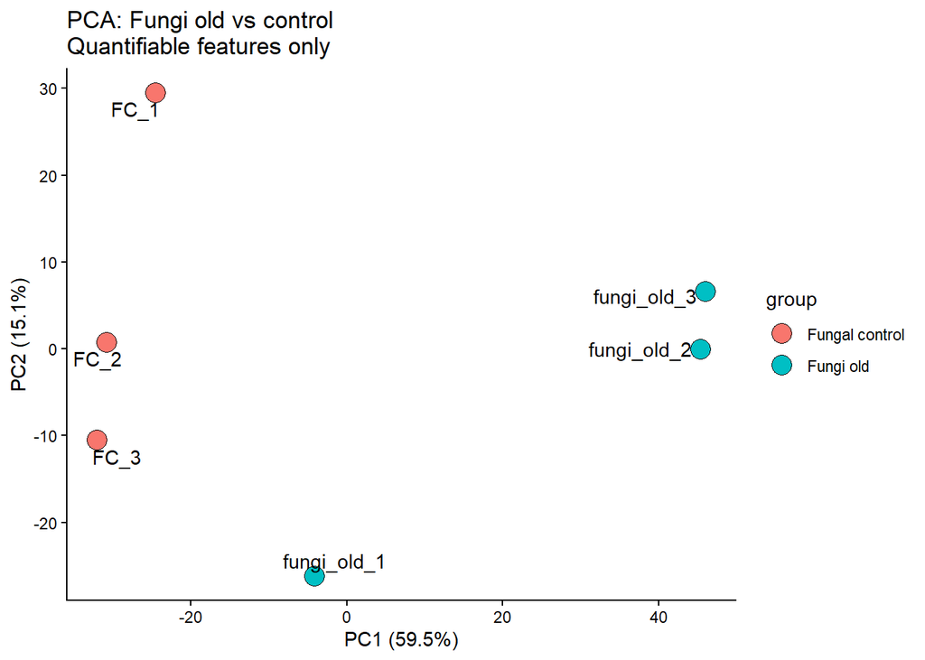

```r
quantitative_pca_results$
  Fungi_old_vs_control$plot
```

Old vs new/in:

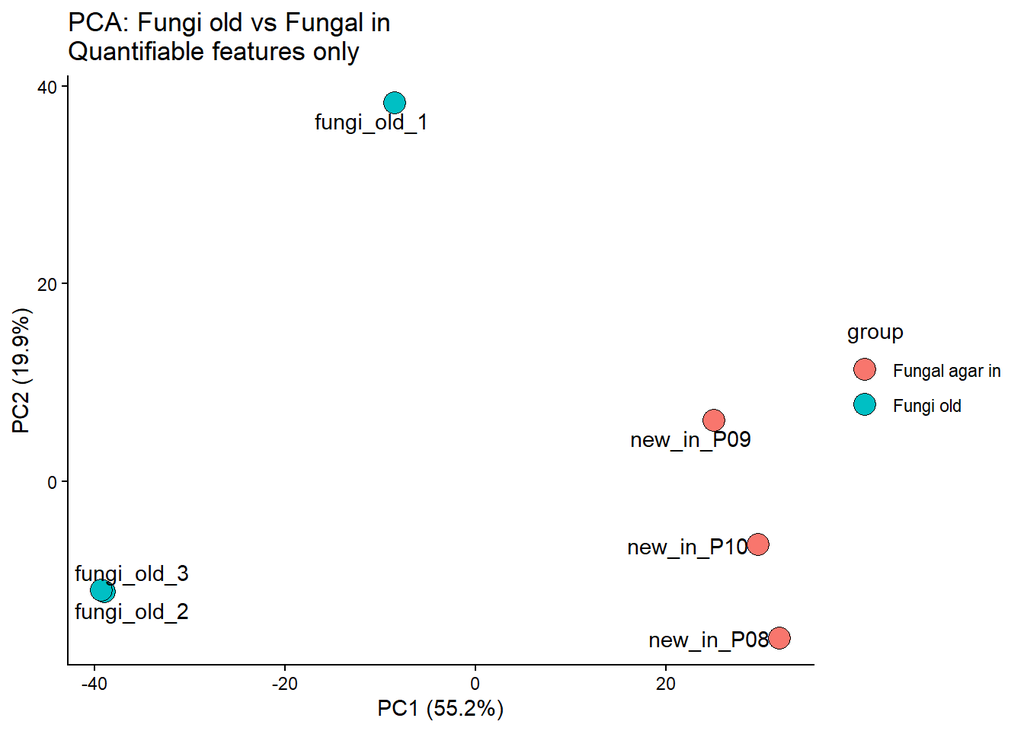

```r
quantitative_pca_results$
  Fungi_old_vs_Fungal_in$plot
```

Old vs new/out:

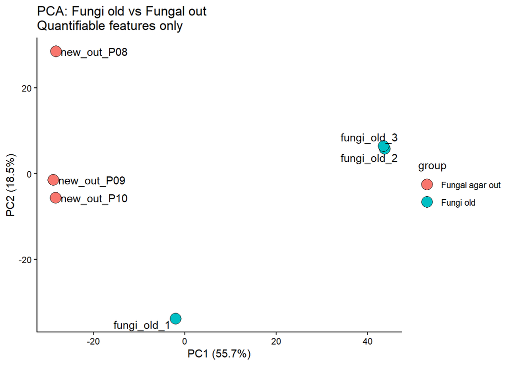

```r
quantitative_pca_results$
  Fungi_old_vs_Fungal_out$plot
```

These three together are particularly informative.

Conceptually:

Old vs control → Does older fungal growth alter the agar metabolome?

New/in vs control → Does current fungal growth alter the agar metabolome?

Old vs new/in → Does colony age/maturity alter the fungal-associated metabolome?

Old vs new/out → How does older fungus-associated agar compare with agar outside the newer colony?

63. Load limma

Install once in Console if necessary:

```r
if (!requireNamespace("BiocManager", quietly = TRUE)) {
  install.packages("BiocManager")
}

BiocManager::install("limma")
```

Then add near your other library() calls:

```r
library(limma)
```

64. Reusable limma function

```r
run_limma_comparison <- function(
    log_matrix,
    group1_cols,
    group2_cols,
    group1_name,
    group2_name,
    annotation_table
) {

  # limma requires rows = features,
  # columns = samples

  limma_matrix <-
    t(
      log_matrix
    )

  sample_order <-
    colnames(
      limma_matrix
    )

  comparison_group <-
    ifelse(
      sample_order %in%
        group1_cols,
      group1_name,
      group2_name
    )

  comparison_group <-
    factor(
      comparison_group,
      levels = c(
        group2_name,
        group1_name
      )
    )

  design <-
    model.matrix(
      ~ comparison_group
    )

  fit <-
    lmFit(
      limma_matrix,
      design
    )

  fit <-
    eBayes(
      fit
    )

  results <-
    topTable(
      fit,
      coef = 2,
      number = Inf,
      adjust.method = "BH",
      sort.by = "P"
    ) %>%
    rownames_to_column(
      "feature_name"
    ) %>%
    left_join(
      annotation_table,
      by = "feature_name"
    ) %>%
    mutate(

      comparison =
        paste0(
          group1_name,
          " vs ",
          group2_name
        ),

      higher_in =
        case_when(

          logFC > 0 ~
            group1_name,

          logFC < 0 ~
            group2_name,

          TRUE ~
            "Equal"
        ),

      result_category =
        case_when(

          adj.P.Val < 0.05 &
            logFC >= 1 ~
            paste0(
              group1_name,
              " enriched - FDR supported"
            ),

          adj.P.Val < 0.05 &
            logFC <= -1 ~
            paste0(
              group2_name,
              " enriched - FDR supported"
            ),

          P.Value < 0.05 &
            logFC >= 1 ~
            paste0(
              group1_name,
              " enriched - exploratory"
            ),

          P.Value < 0.05 &
            logFC <= -1 ~
            paste0(
              group2_name,
              " enriched - exploratory"
            ),

          TRUE ~
            "Not selected"
        )
    )

  results
}
```

65. Run limma for all comparisons

```r
limma_results <- lapply(
  names(normalized_comparisons),

  function(comparison_name) {

    comparison_info <- quantitative_comparisons[[comparison_name]]

    run_limma_comparison(

      log_matrix =
        normalized_comparisons[[comparison_name]]$log,

      group1_cols =
        comparison_info$group1_cols,

      group2_cols =
        comparison_info$group2_cols,

      group1_name =
        comparison_info$group1_name,

      group2_name =
        comparison_info$group2_name,

      annotation_table =
        feature_annotations
    )
  }
)

names(limma_results) <- names(normalized_comparisons)
```

66. Inspect the fungal-old statistical comparisons

Old vs control:

```r
head(
  limma_results$
    Fungi_old_vs_control,
  20
)
```

```
##               feature_name     logFC  AveExpr         t      P.Value  adj.P.Val
## 1  F2053_mz222.1129_rt1.18  5.152462 19.19795 16.302037 1.423468e-05 0.01966830
## 2  F2247_mz237.1852_rt1.58  8.103483 15.24967 14.154766 2.873491e-05 0.01966830
## 3  F2481_mz256.0819_rt0.65  8.978030 18.14663 13.572778 3.538052e-05 0.01966830
## 4   F650_mz125.0236_rt1.02  8.117728 17.64571 13.428817 3.729794e-05 0.01966830
## 5  F1578_mz190.0502_rt1.03  5.798827 19.04082 13.027112 4.334134e-05 0.01966830
## 6   F2323_mz244.095_rt1.18  3.999527 16.82617 12.245229 5.881783e-05 0.02224294
## 7   F1306_mz171.0655_rt1.1 10.589724 18.42494 11.766885 7.155466e-05 0.02319393
## 8  F1207_mz164.1072_rt1.26  5.053455 18.97947 11.351529 8.535668e-05 0.02406475
## 9  F1003_mz148.0396_rt1.21  6.981601 15.72617 10.614671 1.185244e-04 0.02406475
## 10 F1866_mz209.1176_rt1.18  4.183145 16.65052 10.614363 1.185412e-04 0.02406475
## 11  F885_mz141.0549_rt1.07  8.711202 19.25571 10.458123 1.274320e-04 0.02406475
## 12 F1259_mz167.1069_rt1.06  3.103585 16.27433 10.351966 1.339268e-04 0.02406475
## 13 F2392_mz248.1497_rt1.19  5.561651 16.86255 10.290360 1.378765e-04 0.02406475
## 14    F1765_mz202.1078_rt1  4.912713 17.95407  9.549646 1.981297e-04 0.03211116
```

[output cut: 195 more lines]

Old vs new/in:

```r
head(
  limma_results$
    Fungi_old_vs_Fungal_in,
  20
)
```

```
##               feature_name     logFC  AveExpr          t      P.Value
## 1  F4756_mz555.4051_rt3.42  6.037349 14.67659  22.084259 3.347906e-06
## 2  F2053_mz222.1129_rt1.18  4.545771 18.78020  20.172263 5.255943e-06
## 3  F4086_mz393.2866_rt2.14 11.173873 19.01125  20.161792 5.269541e-06
## 4   F2331_mz244.264_rt2.03 -4.952738 16.39831 -17.630557 1.026241e-05
## 5  F1476_mz182.0814_rt0.52 -5.065613 20.39236 -17.247546 1.144322e-05
## 6   F2420_mz251.1605_rt0.4  3.453614 20.64873  14.060743 3.139564e-05
## 7  F1910_mz213.0761_rt0.97 -5.302245 15.66974 -13.638792 3.647140e-05
## 8  F2330_mz244.2639_rt1.89 -4.898287 15.79211 -13.348149 4.054252e-05
## 9  F2997_mz293.1824_rt0.43  2.685749 18.30819  11.944295 6.985868e-05
## 10  F886_mz141.0549_rt0.94 -2.682389 18.31508 -11.685705 7.773111e-05
## 11  F1728_mz200.1034_rt0.8  3.426546 15.98694  11.359503 8.922543e-05
## 12   F260_mz97.0287_rt0.94 -2.527842 18.78600 -11.303912 9.138102e-05
## 13   F2934_mz288.29_rt1.99 -3.532579 14.65110 -11.268571 9.278373e-05
## 14 F1386_mz176.0558_rt0.69  2.386311 16.49629  11.160650 9.722883e-05
```

[output cut: 174 more lines]

Old vs new/out:

```r
head(
  limma_results$
    Fungi_old_vs_Fungal_out,
  20
)
```

```
##               feature_name     logFC  AveExpr          t      P.Value
## 1  F2053_mz222.1129_rt1.18  4.971373 18.96909  24.497732 2.022574e-06
## 2   F2331_mz244.264_rt2.03 -5.138599 16.89291 -23.576038 2.448658e-06
## 3   F2816_mz280.155_rt1.08  5.896853 18.29125  19.117247 6.947178e-06
## 4  F2481_mz256.0819_rt0.65  5.661341 19.48557  16.821607 1.309578e-05
## 5  F2330_mz244.2639_rt1.89 -5.294833 16.39204 -14.324405 2.893730e-05
## 6   F650_mz125.0236_rt1.02  6.890391 17.93997  13.520127 3.843746e-05
## 7   F636_mz124.0396_rt1.02 -2.583304 19.15789 -13.453240 3.938421e-05
## 8  F2997_mz293.1824_rt0.43  2.849215 18.62815  13.080578 4.519927e-05
## 9  F2247_mz237.1852_rt1.58  7.384637 15.28969  12.762393 5.099112e-05
## 10  F2420_mz251.1605_rt0.4  2.650753 21.45185  12.462111 5.728755e-05
## 11   F2934_mz288.29_rt1.99 -3.756156 15.16453 -12.127411 6.543331e-05
## 12 F2004_mz218.1501_rt0.45 -2.333876 18.69544 -12.126371 6.546069e-05
## 13 F1504_mz184.0608_rt1.02  5.394661 16.91627  11.801912 7.471549e-05
## 14 F1578_mz190.0502_rt1.03  5.581090 18.83029  11.271012 9.346774e-05
```

[output cut: 174 more lines]

67. Summarize all limma comparisons

```r
limma_summary_all <- bind_rows(

  lapply(

    names(
      limma_results
    ),

    function(comparison_name) {

      x <-limma_results[[comparison_name]]


      tibble(

        comparison =
          comparison_name,

        tested_features =
          nrow(x),

        raw_p_under_05 =
          sum(
            x$P.Value < 0.05,
            na.rm = TRUE
          ),

        FDR_under_05 =
          sum(
            x$adj.P.Val < 0.05,
            na.rm = TRUE
          ),

        FDR_and_twofold =
          sum(
            x$adj.P.Val < 0.05 &
              abs(
                x$logFC
              ) >= 1,
            na.rm = TRUE
          ),

        group1_enriched_FDR =
          sum(
            x$adj.P.Val < 0.05 &
              x$logFC >= 1,
            na.rm = TRUE
          ),

        group2_enriched_FDR =
          sum(
            x$adj.P.Val < 0.05 &
              x$logFC <= -1,
            na.rm = TRUE
          )
      )
    }
  )
)

limma_summary_all
```

```
## # A tibble: 10 × 7
##    comparison        tested_features raw_p_under_05 FDR_under_05 FDR_and_twofold
##    <chr>                       <int>          <int>        <int>           <int>
##  1 Exudate_vs_Soil              1386            294            1               1
##  2 Exudate_vs_Root              1114            648          592             547
##  3 Exudate_vs_Leaf              1214            771          728             681
##  4 Leaf_vs_Root                 1805           1000          892             854
##  5 Fungal_in_vs_out             2290            919          456             267
##  6 Fungal_in_vs_con…            2270           1051          807             583
##  7 Fungal_out_vs_co…            2556            429           30              26
##  8 Fungi_old_vs_con…            2269            841           52              52
##  9 Fungi_old_vs_Fun…            2053            822          262             261
## 10 Fungi_old_vs_Fun…            2236            839          162             162
## # ℹ 2 more variables: group1_enriched_FDR <int>, group2_enriched_FDR <int>
```

68. Create a fungal-only statistical summary

```r
fungal_limma_summary <-
  limma_summary_all %>%
  filter(
    comparison %in% c(
      "Fungal_in_vs_out",
      "Fungal_in_vs_control",
      "Fungal_out_vs_control",
      "Fungi_old_vs_control",
      "Fungi_old_vs_Fungal_in",
      "Fungi_old_vs_Fungal_out"
    )
  )

fungal_limma_summary
```

```
## # A tibble: 6 × 7
##   comparison         tested_features raw_p_under_05 FDR_under_05 FDR_and_twofold
##   <chr>                        <int>          <int>        <int>           <int>
## 1 Fungal_in_vs_out              2290            919          456             267
## 2 Fungal_in_vs_cont…            2270           1051          807             583
## 3 Fungal_out_vs_con…            2556            429           30              26
## 4 Fungi_old_vs_cont…            2269            841           52              52
## 5 Fungi_old_vs_Fung…            2053            822          262             261
## 6 Fungi_old_vs_Fung…            2236            839          162             162
## # ℹ 2 more variables: group1_enriched_FDR <int>, group2_enriched_FDR <int>
```

This will let you compare, side by side, how many features differ in each fungal contrast.

69. Find features shared between old and new fungal effects

This is especially useful for your age question.

First get features significantly different from control in the old fungal group:

```r
old_vs_control_sig <-
  limma_results$
    Fungi_old_vs_control %>%
  filter(
    adj.P.Val < 0.05,
    abs(logFC) >= 1
  ) %>%
  pull(
    feature_name
  )
```

Get features significantly different from control in new/in:

```r
new_in_vs_control_sig <-
  limma_results$
    Fungal_in_vs_control %>%
  filter(
    adj.P.Val < 0.05,
    abs(logFC) >= 1
  ) %>%
  pull(
    feature_name
  )
```

Shared fungal-effect features:

```r
shared_old_new_fungal_features <-
  intersect(
    old_vs_control_sig,
    new_in_vs_control_sig
  )

length(
  shared_old_new_fungal_features
)
```

```
## [1] 24
```

Inspect them:

```r
shared_old_new_fungal_results <-
  feature_annotations %>%
  filter(
    feature_name %in%
      shared_old_new_fungal_features
  )

shared_old_new_fungal_results
```

```
## # A tibble: 24 × 26
##    feature_name  `Alignment ID` `Average Rt(min)` `Average Mz` `Metabolite name`
##    <chr>                  <dbl>             <dbl>        <dbl> <chr>
##  1 F64_mz72.081…             64             0.393         72.1 Unknown
##  2 F259_mz97.02…            259             1.01          97.0 Unknown
##  3 F489_mz114.0…            489             1.00         114.  Unknown
##  4 F650_mz125.0…            650             1.02         125.  Unknown
##  5 F885_mz141.0…            885             1.07         141.  Unknown
##  6 F990_mz147.0…            990             0.459        147.  Unknown
##  7 F1150_mz160.…           1150             0.776        160.  Unknown
##  8 F1207_mz164.…           1207             1.26         164.  Unknown
##  9 F1259_mz167.…           1259             1.06         167.  Unknown
## 10 F1306_mz171.…           1306             1.1          171.  Unknown
## # ℹ 14 more rows
## # ℹ 21 more variables: `Adduct type` <chr>, `Post curation result` <chr>,
## #   `Fill %` <dbl>, `MS/MS assigned` <lgl>, Formula <chr>, Ontology <chr>,
## #   INCHIKEY <chr>, SMILES <chr>, `Annotation tag (VS1.0)` <dbl>,
## #   `RT matched` <lgl>, `m/z matched` <lgl>, `MS/MS matched` <lgl>,
## #   `Total score` <chr>, `RT similarity` <chr>, `Dot product` <chr>,
## #   `Reverse dot product` <chr>, `Fragment presence %` <chr>, …
```

These are strong candidates for:

features associated with fungal growth regardless of colony age.

70. Features different between old and new fungal colonies

```r
age_sensitive_fungal_features <-
  limma_results$
    Fungi_old_vs_Fungal_in %>%
  filter(
    adj.P.Val < 0.05,
    abs(logFC) >= 1
  )

age_sensitive_fungal_features
```

```
##                feature_name     logFC  AveExpr          t      P.Value
## 1   F4756_mz555.4051_rt3.42  6.037349 14.67659  22.084259 3.347906e-06
## 2   F2053_mz222.1129_rt1.18  4.545771 18.78020  20.172263 5.255943e-06
## 3   F4086_mz393.2866_rt2.14 11.173873 19.01125  20.161792 5.269541e-06
## 4    F2331_mz244.264_rt2.03 -4.952738 16.39831 -17.630557 1.026241e-05
## 5   F1476_mz182.0814_rt0.52 -5.065613 20.39236 -17.247546 1.144322e-05
## 6    F2420_mz251.1605_rt0.4  3.453614 20.64873  14.060743 3.139564e-05
## 7   F1910_mz213.0761_rt0.97 -5.302245 15.66974 -13.638792 3.647140e-05
## 8   F2330_mz244.2639_rt1.89 -4.898287 15.79211 -13.348149 4.054252e-05
## 9   F2997_mz293.1824_rt0.43  2.685749 18.30819  11.944295 6.985868e-05
## 10   F886_mz141.0549_rt0.94 -2.682389 18.31508 -11.685705 7.773111e-05
## 11   F1728_mz200.1034_rt0.8  3.426546 15.98694  11.359503 8.922543e-05
## 12    F260_mz97.0287_rt0.94 -2.527842 18.78600 -11.303912 9.138102e-05
## 13    F2934_mz288.29_rt1.99 -3.532579 14.65110 -11.268571 9.278373e-05
## 14  F1386_mz176.0558_rt0.69  2.386311 16.49629  11.160650 9.722883e-05
```

[output cut: 2343 more lines]

If this table is small while both old-vs-control and new-in-vs-control are large, that would support:

fungal presence strongly affects the agar chemistry, while colony age has a smaller effect.

If this table is large, age/maturity matters more.

71. Quantify overlap between old and new fungal effects

```r
fungal_overlap_summary <- tibble(

  old_vs_control_significant =
    length(
      old_vs_control_sig
    ),

  new_in_vs_control_significant =
    length(
      new_in_vs_control_sig
    ),

  shared_significant_features =
    length(
      shared_old_new_fungal_features
    ),

  old_only =
    length(
      setdiff(
        old_vs_control_sig,
        new_in_vs_control_sig
      )
    ),

  new_only =
    length(
      setdiff(
        new_in_vs_control_sig,
        old_vs_control_sig
      )
    )
)

fungal_overlap_summary
```

```
## # A tibble: 1 × 5
##   old_vs_control_signif…¹ new_in_vs_control_si…² shared_significant_f…³ old_only
##                     <int>                  <int>                  <int>    <int>
## 1                      52                    583                     24       28
## # ℹ abbreviated names: ¹old_vs_control_significant,
## #   ²new_in_vs_control_significant, ³shared_significant_features
## # ℹ 1 more variable: new_only <int>
```

72. Save the new fungal outputs

```r
write.csv(
  fungal_limma_summary,
  "positive_mode_fungal_limma_summary.csv",
  row.names = FALSE
)

write.csv(
  shared_old_new_fungal_results,
  "positive_mode_shared_old_new_fungal_features.csv",
  row.names = FALSE
)

write.csv(
  age_sensitive_fungal_features,
  "positive_mode_age_sensitive_fungal_features.csv",
  row.names = FALSE
)

write.csv(
  fungal_overlap_summary,
  "positive_mode_fungal_overlap_summary.csv",
  row.names = FALSE
)
```

And save all limma tables:

```r
for (
  comparison_name in
  names(limma_results)
) {

  write.csv(

    limma_results
      [[comparison_name]]
    ,

    paste0(
      "positive_mode_limma_",
      comparison_name,
      ".csv"
    ),

    row.names = FALSE
  )
}
```

The first three outputs I’d examine after running this are:

```r
quantifiable_feature_counts
```

```
## # A tibble: 10 × 2
##    comparison              quantifiable_features
##    <chr>                                   <int>
##  1 Exudate_vs_Soil                          1386
##  2 Exudate_vs_Root                          1114
##  3 Exudate_vs_Leaf                          1214
##  4 Leaf_vs_Root                             1805
##  5 Fungal_in_vs_out                         2290
##  6 Fungal_in_vs_control                     2270
##  7 Fungal_out_vs_control                    2556
##  8 Fungi_old_vs_control                     2269
##  9 Fungi_old_vs_Fungal_in                   2053
## 10 Fungi_old_vs_Fungal_out                  2236
```

```r
fungal_limma_summary
```

```
## # A tibble: 6 × 7
##   comparison         tested_features raw_p_under_05 FDR_under_05 FDR_and_twofold
##   <chr>                        <int>          <int>        <int>           <int>
## 1 Fungal_in_vs_out              2290            919          456             267
## 2 Fungal_in_vs_cont…            2270           1051          807             583
## 3 Fungal_out_vs_con…            2556            429           30              26
## 4 Fungi_old_vs_cont…            2269            841           52              52
## 5 Fungi_old_vs_Fung…            2053            822          262             261
## 6 Fungi_old_vs_Fung…            2236            839          162             162
## # ℹ 2 more variables: group1_enriched_FDR <int>, group2_enriched_FDR <int>
```

and:

```r
fungal_overlap_summary
```

```
## # A tibble: 1 × 5
##   old_vs_control_signif…¹ new_in_vs_control_si…² shared_significant_f…³ old_only
##                     <int>                  <int>                  <int>    <int>
## 1                      52                    583                     24       28
## # ℹ abbreviated names: ¹old_vs_control_significant,
## #   ²new_in_vs_control_significant, ³shared_significant_features
## # ℹ 1 more variable: new_only <int>
```

73. Create common analytical flags for candidate features

We want to distinguish:

confidently retained RTs from very early RTs; features with MS/MS; features with an actual MS-DIAL metabolite annotation.

# ————————————————————

# ————————————————————

```r
candidate_annotations <- feature_annotations %>%
  mutate(

    RT_flag = case_when(
      `Average Rt(min)` < 0.5 ~
        "Very early RT",

      `Average Rt(min)` < 1.0 ~
        "Early RT",

      TRUE ~
        "RT >= 1 min"
    ),

    MSMS_flag = case_when(
      `MS/MS assigned` == TRUE ~
        "MS/MS available",

      TRUE ~
        "No MS/MS assignment"
    ),

    annotation_flag = case_when(

      !is.na(`Metabolite name`) &
        `Metabolite name` != "" &
        `Metabolite name` != "Unknown" ~
        "Annotated",

      TRUE ~
        "Unknown"
    )
  )
```

Check:

```r
candidate_annotations %>%
  count(
    RT_flag,
    MSMS_flag,
    annotation_flag
  )
```

```
## # A tibble: 6 × 4
##   RT_flag       MSMS_flag           annotation_flag     n
##   <chr>         <chr>               <chr>           <int>
## 1 Early RT      MS/MS available     Unknown           304
## 2 Early RT      No MS/MS assignment Unknown          1013
## 3 RT >= 1 min   MS/MS available     Unknown           697
## 4 RT >= 1 min   No MS/MS assignment Unknown          1133
## 5 Very early RT MS/MS available     Unknown           132
## 6 Very early RT No MS/MS assignment Unknown           865
```

74. Create plant-compartment annotation table

This gives every feature its leaf/root/exudate/soil detection pattern.

```r
plant_compartment_flags <-
  plant_compartment_presence %>%
  select(
    feature_name,
    leaf_detected_n,
    root_detected_n,
    exudate_detected_n,
    soil_detected_n,
    leaf_present,
    root_present,
    exudate_present,
    soil_present,
    plant_pattern
  )
```

75. Rank abundance-based exudate vs soil candidates

These are different from the presence-only candidates.

These features were sufficiently detected in both exudate and soil to enter limma.

```r
exudate_soil_abundance_candidates <-
  limma_results$Exudate_vs_Soil %>%

  left_join(
    plant_compartment_flags,
    by = "feature_name"
  ) %>%

  left_join(
    candidate_annotations %>%
      select(
        feature_name,
        RT_flag,
        MSMS_flag,
        annotation_flag
      ),
    by = "feature_name"
  ) %>%

  mutate(

    evidence_tier = case_when(

      adj.P.Val < 0.05 &
        abs(logFC) >= 1 ~
        "Tier 1: FDR + >=2-fold",

      adj.P.Val < 0.05 ~
        "Tier 2: FDR supported",

      P.Value < 0.05 &
        abs(logFC) >= 1 ~
        "Tier 3: exploratory + >=2-fold",

      abs(logFC) >= 1 ~
        "Tier 4: large effect only",

      TRUE ~
        "Tier 5: low priority"
    )
  ) %>%

  arrange(
    factor(
      evidence_tier,
      levels = c(
        "Tier 1: FDR + >=2-fold",
        "Tier 2: FDR supported",
        "Tier 3: exploratory + >=2-fold",
        "Tier 4: large effect only",
        "Tier 5: low priority"
      )
    ),
    adj.P.Val,
    desc(abs(logFC))
  )
```

Inspect the strongest:

```r
exudate_soil_abundance_candidates %>%
  select(
    feature_name,
    `Average Rt(min)`,
    `Average Mz`,
    `Metabolite name`,
    `Adduct type`,
    `MS/MS assigned`,
    RT_flag,
    leaf_present,
    root_present,
    exudate_present,
    soil_present,
    logFC,
    P.Value,
    adj.P.Val,
    evidence_tier
  ) %>%
  head(50)
```

```
##               feature_name Average Rt(min) Average Mz Metabolite name
## 1  F2594_mz265.0235_rt0.44           0.443  265.02347         Unknown
## 2   F1906_mz212.852_rt0.43           0.430  212.85202         Unknown
## 3   F1209_mz164.921_rt0.43           0.428  164.92101         Unknown
## 4  F1682_mz196.8781_rt0.43           0.429  196.87810         Unknown
## 5  F1449_mz180.8948_rt0.43           0.427  180.89479         Unknown
## 6  F1034_mz150.4944_rt0.44           0.438  150.49442         Unknown
## 7    F808_mz136.484_rt0.43           0.433  136.48401         Unknown
## 8   F1744_mz201.0526_rt0.5           0.501  201.05261         Unknown
## 9   F4226_mz414.3914_rt0.4           0.398  414.39142         Unknown
## 10 F3537_mz337.1051_rt2.67           2.671  337.10507         Unknown
## 11 F1802_mz204.9095_rt0.43           0.433  204.90947         Unknown
## 12  F574_mz119.9606_rt0.47           0.474  119.96062         Unknown
## 13  F327_mz101.9501_rt0.47           0.473  101.95007         Unknown
## 14 F1158_mz160.9872_rt0.48           0.475  160.98715         Unknown
```

[output cut: 189 more lines]

76. Count exudate vs soil candidate tiers

```r
exudate_soil_abundance_candidates %>%
  count(
    evidence_tier
  )
```

```
##                    evidence_tier    n
## 1         Tier 1: FDR + >=2-fold    1
## 2 Tier 3: exploratory + >=2-fold  159
## 3      Tier 4: large effect only  215
## 4           Tier 5: low priority 1011
```

And specifically:

```r
sum(
  exudate_soil_abundance_candidates$
    adj.P.Val < 0.05,
  na.rm = TRUE
)
```

```
## [1] 1
```

77. Create detection-based plant candidate table

Now handle the features that may be biologically very interesting because of differential detection.

These do not need to be quantifiable in soil.

```r
plant_detection_candidates <-
  plant_compartment_presence %>%

  filter(
    exudate_present,
    !soil_present
  ) %>%

  left_join(
    candidate_annotations %>%
      select(
        feature_name,
        RT_flag,
        MSMS_flag,
        annotation_flag
      ),
    by = "feature_name"
  ) %>%

  mutate(

    plant_candidate_class = case_when(

      !leaf_present &
        root_present &
        exudate_present &
        !soil_present ~
        "Root + Exudate; absent Leaf/Soil",

      leaf_present &
        root_present &
        exudate_present &
        !soil_present ~
        "Leaf + Root + Exudate; absent Soil",

      !leaf_present &
        !root_present &
        exudate_present &
        !soil_present ~
        "Exudate only; absent Soil",

      leaf_present &
        !root_present &
        exudate_present &
        !soil_present ~
        "Leaf + Exudate; absent Root/Soil",

      TRUE ~
        "Other plant-associated pattern"
    )
  )
```

78. Add raw group means to detection-based plant candidates

For these candidates, it is useful to see the actual MS-DIAL peak-height pattern.

```r
plant_detection_candidates <-
  plant_detection_candidates %>%
  mutate(

    leaf_mean_raw =
      rowMeans(
        across(
          all_of(
            presence_groups$Leaf
          )
        ),
        na.rm = TRUE
      ),

    root_mean_raw =
      rowMeans(
        across(
          all_of(
            presence_groups$Root
          )
        ),
        na.rm = TRUE
      ),

    exudate_mean_raw =
      rowMeans(
        across(
          all_of(
            presence_groups$Exudate
          )
        ),
        na.rm = TRUE
      ),

    soil_mean_raw =
      rowMeans(
        across(
          all_of(
            presence_groups$Soil
          )
        ),
        na.rm = TRUE
      )
  )
```

Rank:

```r
plant_detection_candidates <-
  plant_detection_candidates %>%
  arrange(
    factor(
      plant_candidate_class,
      levels = c(
        "Root + Exudate; absent Leaf/Soil",
        "Leaf + Root + Exudate; absent Soil",
        "Exudate only; absent Soil",
        "Leaf + Exudate; absent Root/Soil",
        "Other plant-associated pattern"
      )
    ),
    desc(
      sample_to_blank_ratio
    )
  )
```

Inspect:

```r
plant_detection_candidates %>%
  select(
    feature_name,
    `Average Rt(min)`,
    `Average Mz`,
    `Metabolite name`,
    `Adduct type`,
    `MS/MS assigned`,
    RT_flag,
    plant_candidate_class,
    leaf_mean_raw,
    root_mean_raw,
    exudate_mean_raw,
    soil_mean_raw,
    sample_to_blank_ratio
  ) %>%
  head(50)
```

```
## # A tibble: 50 × 13
##    feature_name   `Average Rt(min)` `Average Mz` `Metabolite name` `Adduct type`
##    <chr>                      <dbl>        <dbl> <chr>             <chr>
##  1 F4601_mz494.8…             0.417         495. Unknown           [M+H]+
##  2 F2544_mz260.1…             0.897         260. Unknown           [M+H]+
##  3 F1207_mz164.1…             1.26          164. Unknown           [M+H]+
##  4 F1085_mz155.0…             0.441         155. Unknown           [M+H]+
##  5 F5091_mz739.7…             9.70          740. Unknown           [M+H]+
##  6 F3781_mz360.1…             0.549         360. Unknown           [M+H]+
##  7 F1621_mz193.0…             0.476         193. Unknown           [M+H]+
##  8 F387_mz106.05…             0.447         106. Unknown           [M+H]+
##  9 F3515_mz335.2…             3.55          335. Unknown           [M+H]+
## 10 F4676_mz522.2…             0.487         522. Unknown           [M+H]+
## # ℹ 40 more rows
## # ℹ 8 more variables: `MS/MS assigned` <lgl>, RT_flag <chr>,
## #   plant_candidate_class <chr>, leaf_mean_raw <dbl>, root_mean_raw <dbl>,
## #   exudate_mean_raw <dbl>, soil_mean_raw <dbl>, sample_to_blank_ratio <dbl>
```

79. Specifically rank root + exudate candidates

```r
ranked_root_exudate_candidates <-
  plant_detection_candidates %>%

  filter(
    plant_candidate_class ==
      "Root + Exudate; absent Leaf/Soil"
  ) %>%

  mutate(

    priority = case_when(

      `MS/MS assigned` == TRUE &
        `Average Rt(min)` >= 1 ~
        "Priority 1",

      `Average Rt(min)` >= 1 ~
        "Priority 2",

      `MS/MS assigned` == TRUE ~
        "Priority 3",

      TRUE ~
        "Priority 4"
    )
  ) %>%

  arrange(
    priority,
    desc(
      sample_to_blank_ratio
    )
  )
```

View:

```r
ranked_root_exudate_candidates %>%
  select(
    feature_name,
    `Average Rt(min)`,
    `Average Mz`,
    `Metabolite name`,
    `MS/MS assigned`,
    RT_flag,
    root_mean_raw,
    exudate_mean_raw,
    soil_mean_raw,
    sample_to_blank_ratio,
    priority
  )
```

```
## # A tibble: 5 × 11
##   feature_name `Average Rt(min)` `Average Mz` `Metabolite name` `MS/MS assigned`
##   <chr>                    <dbl>        <dbl> <chr>             <lgl>
## 1 F1207_mz164…             1.26          164. Unknown           TRUE
## 2 F5091_mz739…             9.70          740. Unknown           FALSE
## 3 F2544_mz260…             0.897         260. Unknown           TRUE
## 4 F4601_mz494…             0.417         495. Unknown           FALSE
## 5 F1085_mz155…             0.441         155. Unknown           FALSE
## # ℹ 6 more variables: RT_flag <chr>, root_mean_raw <dbl>,
## #   exudate_mean_raw <dbl>, soil_mean_raw <dbl>, sample_to_blank_ratio <dbl>,
## #   priority <chr>
```

This is where your earlier five root+exudate candidates should appear.

80. Rank exudate-only candidates

```r
ranked_exudate_only_candidates <-
  plant_detection_candidates %>%

  filter(
    plant_candidate_class ==
      "Exudate only; absent Soil"
  ) %>%

  mutate(

    priority = case_when(

      `MS/MS assigned` == TRUE &
        `Average Rt(min)` >= 1 ~
        "Priority 1",

      `Average Rt(min)` >= 1 ~
        "Priority 2",

      `MS/MS assigned` == TRUE ~
        "Priority 3",

      TRUE ~
        "Priority 4"
    )
  ) %>%

  arrange(
    priority,
    desc(
      sample_to_blank_ratio
    )
  )
```

81. Create fungal differential-detection candidate tables

Now do the same concept for fungi.

Helper:

```r
extract_detection_candidates <- function(
    comparison_name
) {

  prepared_comparisons[[comparison_name]] $detection_table %>%

    filter(
      detection_category !=
        "Quantifiable in both",

      detection_category !=
        "Not consistently detected in either"
    ) %>%

    left_join(
      candidate_annotations %>%
        select(
          feature_name,
          RT_flag,
          MSMS_flag,
          annotation_flag
        ),
      by = "feature_name"
    )
}
```

Important: keep [[comparison_name]] together. Use this exact corrected function instead:

```r
extract_detection_candidates <- function(comparison_name) {

  x <- prepared_comparisons[[comparison_name]]$detection_table

  x %>%
    filter(
      detection_category != "Quantifiable in both",
      detection_category != "Not consistently detected in either"
    ) %>%
    left_join(
      candidate_annotations %>%
        select(
          feature_name,
          RT_flag,
          MSMS_flag,
          annotation_flag
        ),
      by = "feature_name"
    )
}
```

Run:

```r
fungal_in_control_detection <-
  extract_detection_candidates(
    "Fungal_in_vs_control"
  )

fungal_out_control_detection <-
  extract_detection_candidates(
    "Fungal_out_vs_control"
  )

fungi_old_control_detection <-
  extract_detection_candidates(
    "Fungi_old_vs_control"
  )

fungi_old_new_detection <-
  extract_detection_candidates(
    "Fungi_old_vs_Fungal_in"
  )
```

82. Inspect old-fungus differential detection

```r
fungi_old_control_detection %>%
  count(
    detection_category
  )
```

```
## # A tibble: 2 × 2
##   detection_category                      n
##   <chr>                               <int>
## 1 Fungal control-associated detection   483
## 2 Fungi old-associated detection        300
```

View candidates:

```r
fungi_old_control_detection %>%
  select(
    feature_name,
    `Average Rt(min)`,
    `Average Mz`,
    `Metabolite name`,
    `MS/MS assigned`,
    detection_category,
    RT_flag,
    sample_to_blank_ratio
  ) %>%
  arrange(
    desc(
      sample_to_blank_ratio
    )
  ) %>%
  head(50)
```

```
## # A tibble: 50 × 8
##    feature_name            `Average Rt(min)` `Average Mz` `Metabolite name`
##    <chr>                               <dbl>        <dbl> <chr>
##  1 F3130_mz302.1756_rt1.13             1.13          302. Unknown
##  2 F3323_mz317.2117_rt2.08             2.08          317. Unknown
##  3 F2910_mz287.2011_rt1.36             1.36          287. Unknown
##  4 F3746_mz357.2039_rt2.08             2.08          357. Unknown
##  5 F3204_mz308.0915_rt0.7              0.699         308. Unknown
##  6 F3079_mz299.201_rt2.08              2.08          299. Unknown
##  7 F2946_mz289.1764_rt1.19             1.19          289. Unknown
##  8 F775_mz133.032_rt0.7                0.699         133. Unknown
##  9 F4900_mz621.2717_rt6.74             6.74          621. Unknown
## 10 F4472_mz460.203_rt0.5               0.502         460. Unknown
## # ℹ 40 more rows
## # ℹ 4 more variables: `MS/MS assigned` <lgl>, detection_category <chr>,
## #   RT_flag <chr>, sample_to_blank_ratio <dbl>
```

83. Build a master fungal abundance table

This is one of the most important fungal analyses.

We will combine:

old fungi vs control; new/in fungi vs control; old vs new/in.

First extract only the statistical columns.

```r
old_control_stats <-
  limma_results$Fungi_old_vs_control %>%
  select(
    feature_name,
    old_control_logFC = logFC,
    old_control_p = P.Value,
    old_control_FDR = adj.P.Val
  )
new_control_stats <-
  limma_results$Fungal_in_vs_control %>%
  select(
    feature_name,
    new_control_logFC = logFC,
    new_control_p = P.Value,
    new_control_FDR = adj.P.Val
  )
old_new_stats <-
  limma_results$Fungi_old_vs_Fungal_in %>%
  select(
    feature_name,
    old_new_logFC = logFC,
    old_new_p = P.Value,
    old_new_FDR = adj.P.Val
  )
```

Combine:

```r
fungal_age_master <-
  full_join(
    old_control_stats,
    new_control_stats,
    by = "feature_name"
  ) %>%

  full_join(
    old_new_stats,
    by = "feature_name"
  ) %>%

  left_join(
    candidate_annotations,
    by = "feature_name"
  )
```

84. Classify fungal age effects

This directly addresses your biological hypothesis.

```r
fungal_age_master <-
  fungal_age_master %>%

  mutate(

    old_significant =
      !is.na(old_control_FDR) &
      old_control_FDR < 0.05,

    new_significant =
      !is.na(new_control_FDR) &
      new_control_FDR < 0.05,

    age_significant =
      !is.na(old_new_FDR) &
      old_new_FDR < 0.05,

    same_direction =
      !is.na(old_control_logFC) &
      !is.na(new_control_logFC) &
      sign(old_control_logFC) ==
        sign(new_control_logFC),

    fungal_age_category =
      case_when(

        old_significant &
          new_significant &
          same_direction &
          !age_significant ~
          "Age-stable fungal effect",

        age_significant ~
          "Age-sensitive fungal effect",

        old_significant &
          !new_significant ~
          "Old-associated effect",

        !old_significant &
          new_significant ~
          "New-associated effect",

        old_significant &
          new_significant &
          !same_direction ~
          "Opposite old/new responses",

        TRUE ~
          "No strong fungal-age classification"
      )
  )
```

85. Summarize fungal age categories

```r
fungal_age_summary <-
  fungal_age_master %>%
  count(
    fungal_age_category,
    sort = TRUE
  )

fungal_age_summary
```

```
##                   fungal_age_category    n
## 1 No strong fungal-age classification 1697
## 2               New-associated effect  649
## 3         Age-sensitive fungal effect  262
## 4            Age-stable fungal effect   14
## 5               Old-associated effect    6
```

This is a major result.

If you see lots of:

Age-stable fungal effect

and relatively few:

Age-sensitive fungal effect

that supports:

The fungus changes agar chemistry, but colony age has a smaller effect.

86. Examine age-stable fungal features

```r
age_stable_fungal_features <-
  fungal_age_master %>%

  filter(
    fungal_age_category ==
      "Age-stable fungal effect"
  ) %>%

  arrange(
    pmax(
      old_control_FDR,
      new_control_FDR,
      na.rm = TRUE
    )
  )
```

View:

```r
age_stable_fungal_features %>%
  select(
    feature_name,
    `Average Rt(min)`,
    `Average Mz`,
    `Metabolite name`,
    `MS/MS assigned`,
    RT_flag,
    old_control_logFC,
    old_control_FDR,
    new_control_logFC,
    new_control_FDR,
    old_new_logFC,
    old_new_FDR
  ) %>%
  head(50)
```

```
##               feature_name Average Rt(min) Average Mz Metabolite name
## 1  F1259_mz167.1069_rt1.06           1.059  167.10687         Unknown
## 2   F3227_mz310.1765_rt0.8           0.799  310.17648         Unknown
## 3      F489_mz114.0552_rt1           1.005  114.05519         Unknown
## 4  F2598_mz265.1122_rt0.48           0.478  265.11215         Unknown
## 5  F1466_mz181.1226_rt1.14           1.140  181.12256         Unknown
## 6    F259_mz97.0286_rt1.01           1.015   97.02865         Unknown
## 7  F3480_mz332.2187_rt0.96           0.958  332.21869         Unknown
## 8  F3052_mz297.2428_rt2.49           2.493  297.24277         Unknown
## 9  F1150_mz160.0428_rt0.78           0.776  160.04276         Unknown
## 10  F990_mz147.0765_rt0.46           0.459  147.07654         Unknown
## 11  F2002_mz218.139_rt1.26           1.261  218.13898         Unknown
## 12 F3465_mz331.1983_rt0.97           0.968  331.19827         Unknown
## 13     F64_mz72.081_rt0.39           0.393   72.08096         Unknown
## 14  F1618_mz193.0476_rt1.1           1.098  193.04764         Unknown
```

[output cut: 30 more lines]

87. Examine age-sensitive fungal features

```r
age_sensitive_fungal_ranked <-
  fungal_age_master %>%

  filter(
    fungal_age_category ==
      "Age-sensitive fungal effect"
  ) %>%

  arrange(
    old_new_FDR,
    desc(
      abs(
        old_new_logFC
      )
    )
  )
```

View:

```r
age_sensitive_fungal_ranked %>%
  select(
    feature_name,
    `Average Rt(min)`,
    `Average Mz`,
    `Metabolite name`,
    `MS/MS assigned`,
    RT_flag,
    old_new_logFC,
    old_new_p,
    old_new_FDR,
    old_control_logFC,
    new_control_logFC
  ) %>%
  head(50)
```

```
##               feature_name Average Rt(min) Average Mz Metabolite name
## 1  F4086_mz393.2866_rt2.14           2.140  393.28659         Unknown
## 2  F4756_mz555.4051_rt3.42           3.420  555.40509         Unknown
## 3  F2053_mz222.1129_rt1.18           1.179  222.11288         Unknown
## 4  F1476_mz182.0814_rt0.52           0.518  182.08141         Unknown
## 5   F2331_mz244.264_rt2.03           2.033  244.26398         Unknown
## 6  F1910_mz213.0761_rt0.97           0.966  213.07605         Unknown
## 7  F2330_mz244.2639_rt1.89           1.893  244.26393         Unknown
## 8   F2420_mz251.1605_rt0.4           0.397  251.16052         Unknown
## 9    F2934_mz288.29_rt1.99           1.992  288.29001         Unknown
## 10  F1728_mz200.1034_rt0.8           0.801  200.10335         Unknown
## 11 F2997_mz293.1824_rt0.43           0.427  293.18243         Unknown
## 12  F886_mz141.0549_rt0.94           0.942  141.05487         Unknown
## 13   F260_mz97.0287_rt0.94           0.940   97.02866         Unknown
## 14 F1386_mz176.0558_rt0.69           0.687  176.05583         Unknown
```

[output cut: 138 more lines]

88. Create top plant abundance candidate heatmap

Take the top 30 exudate-vs-soil abundance candidates.

```r
top_exudate_soil_features <-
  exudate_soil_abundance_candidates %>%

  filter(
    adj.P.Val < 0.05
  ) %>%

  arrange(
    adj.P.Val,
    desc(
      abs(logFC)
    )
  ) %>%

  slice_head(
    n = 30
  ) %>%

  pull(
    feature_name
  )
```

Only keep features actually present in the quantitative matrix:

```r
top_exudate_soil_features <-
  intersect(
    top_exudate_soil_features,
    colnames(
      normalized_comparisons$
        Exudate_vs_Soil$log
    )
  )
```

Heatmap:

```r
if (
  length(
    top_exudate_soil_features
  ) >= 2
) {

  exudate_soil_heatmap <-
    t(
      normalized_comparisons$
        Exudate_vs_Soil$log[
          ,
          top_exudate_soil_features,
          drop = FALSE
        ]
    )

  pheatmap(
    exudate_soil_heatmap,
    scale = "row",
    clustering_distance_rows =
      "euclidean",
    clustering_distance_cols =
      "euclidean",
    clustering_method =
      "complete",
    show_rownames = TRUE,
    show_colnames = TRUE,
    fontsize_row = 7,
    main =
      "Top differential exudate vs soil features"
  )
}
```

```r
top_age_features <-
  age_sensitive_fungal_ranked %>%

  filter(
    old_new_FDR < 0.05
  ) %>%

  slice_head(
    n = 30
  ) %>%

  pull(
    feature_name
  )
```

Match:

```r
top_age_features <-
  intersect(
    top_age_features,
    colnames(
      normalized_comparisons$
        Fungi_old_vs_Fungal_in$log
    )
  )
```

Plot:

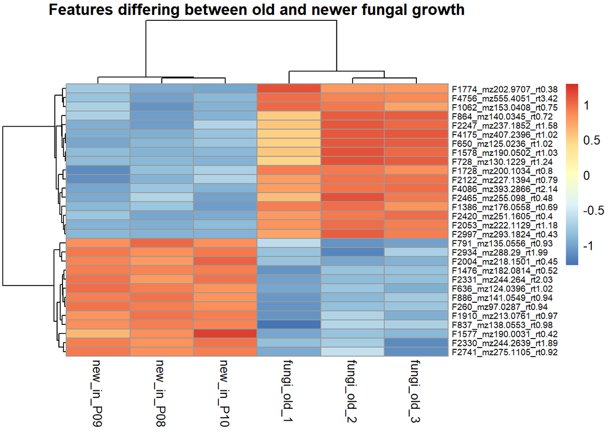

```r
if (
  length(
    top_age_features
  ) >= 2
) {

  fungal_age_heatmap <-
    t(
      normalized_comparisons$
        Fungi_old_vs_Fungal_in$log[
          ,
          top_age_features,
          drop = FALSE
        ]
    )

  pheatmap(
    fungal_age_heatmap,
    scale = "row",
    clustering_distance_rows =
      "euclidean",
    clustering_distance_cols =
      "euclidean",
    clustering_method =
      "complete",
    show_rownames = TRUE,
    show_colnames = TRUE,
    fontsize_row = 7,
    main =
      "Features differing between old and newer fungal growth"
  )
}
```

90. Create reusable individual-feature plot function

This lets you inspect actual replicates for any limma comparison.

```r
plot_comparison_feature <- function(
    comparison_name,
    feature_to_plot
) {

  x <-
    normalized_comparisons[[comparison_name]]$log

  plot_data <-
    as.data.frame(x) %>%
    rownames_to_column(
      "sample"
    ) %>%

    select(
      sample,
      all_of(
        feature_to_plot
      )
    ) %>%

    rename(
      log2_intensity =
        all_of(
          feature_to_plot
        )
    ) %>%

    left_join(
      sample_metadata,
      by = "sample"
    )

  ggplot(
    plot_data,
    aes(
      x = group,
      y = log2_intensity,
      fill = group
    )
  ) +

    geom_boxplot(
      width = 0.5,
      outlier.shape = NA,
      alpha = 0.5
    ) +

    geom_jitter(
      width = 0.08,
      size = 3
    ) +

    labs(
      title =
        feature_to_plot,
      x = NULL,
      y =
        "Log2 normalized intensity"
    ) +

    theme_classic() +

    theme(
      axis.text.x =
        element_text(
          angle = 45,
          hjust = 1
        ),
      legend.position =
        "none"
    )
}
```

Again, fix the indexing formatting to keep brackets together. Use this exact function:

```r
plot_comparison_feature <- function(
    comparison_name,
    feature_to_plot
) {

  x <- normalized_comparisons[[comparison_name]]$log

  plot_data <-
    as.data.frame(x) %>%
    rownames_to_column("sample") %>%
    select(
      sample,
      all_of(feature_to_plot)
    )

  names(plot_data)[2] <-
    "log2_intensity"

  plot_data <-
    plot_data %>%
    left_join(
      sample_metadata,
      by = "sample"
    )

  ggplot(
    plot_data,
    aes(
      x = group,
      y = log2_intensity,
      fill = group
    )
  ) +
    geom_boxplot(
      width = 0.5,
      outlier.shape = NA,
      alpha = 0.5
    ) +
    geom_jitter(
      width = 0.08,
      size = 3
    ) +
    labs(
      title = feature_to_plot,
      x = NULL,
      y = "Log2 normalized intensity"
    ) +
    theme_classic() +
    theme(
      axis.text.x =
        element_text(
          angle = 45,
          hjust = 1
        ),
      legend.position = "none"
    )
}
```

91. Plot strongest exudate vs soil feature

```r
top_exudate_abundance_feature <-
  exudate_soil_abundance_candidates %>%

  filter(
    adj.P.Val < 0.05
  ) %>%

  arrange(
    adj.P.Val,
    desc(
      abs(logFC)
    )
  ) %>%

  slice(1) %>%

  pull(
    feature_name
  )
```

Plot:

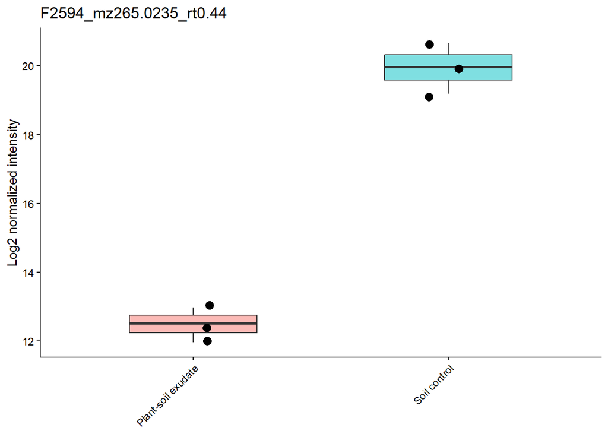

```r
plot_comparison_feature(
  "Exudate_vs_Soil",
  top_exudate_abundance_feature
)
```

92. Plot strongest fungal-age feature

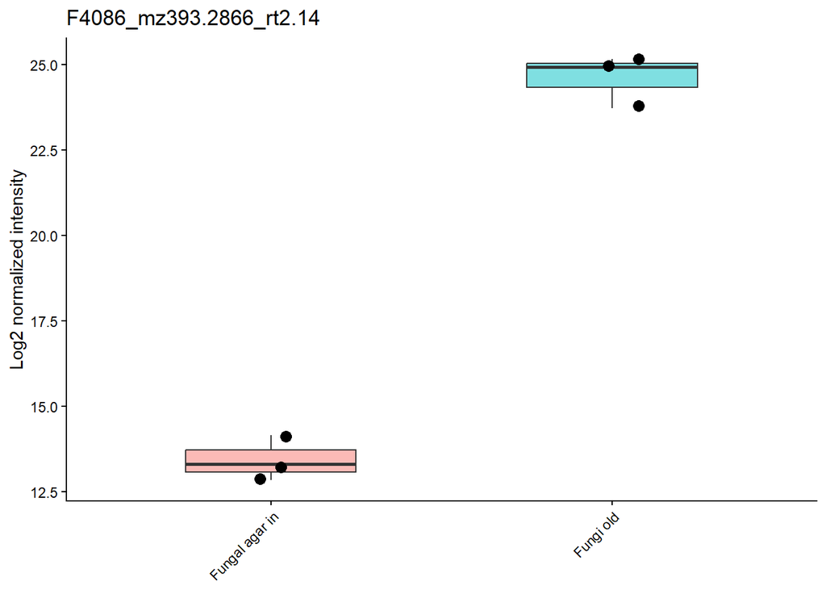

```r
top_fungal_age_feature <-
  age_sensitive_fungal_ranked %>%

  slice(1) %>%

  pull(
    feature_name
  )
plot_comparison_feature(
  "Fungi_old_vs_Fungal_in",
  top_fungal_age_feature
)
```

93. Create annotation-priority subset

Now identify candidates for actual chemical-identification work.

```r
annotated_exudate_candidates <-
  exudate_soil_abundance_candidates %>%

  filter(
    annotation_flag ==
      "Annotated" |
      `MS/MS assigned` ==
        TRUE
  ) %>%

  arrange(
    adj.P.Val,
    desc(
      abs(logFC)
    )
  )
```

View:

```r
annotated_exudate_candidates %>%
  select(
    feature_name,
    `Average Rt(min)`,
    `Average Mz`,
    `Metabolite name`,
    `Adduct type`,
    Formula,
    Ontology,
    `MS/MS assigned`,
    `Total score`,
    RT_flag,
    logFC,
    P.Value,
    adj.P.Val
  ) %>%
  head(50)
```

```
##               feature_name Average Rt(min) Average Mz Metabolite name
## 1  F1682_mz196.8781_rt0.43           0.429  196.87810         Unknown
## 2   F1744_mz201.0526_rt0.5           0.501  201.05261         Unknown
## 3  F3537_mz337.1051_rt2.67           2.671  337.10507         Unknown
## 4  F1158_mz160.9872_rt0.48           0.475  160.98715         Unknown
## 5  F2296_mz241.9999_rt0.39           0.393  241.99988         Unknown
## 6  F2231_mz236.1049_rt0.52           0.521  236.10490         Unknown
## 7  F2223_mz235.0928_rt0.49           0.486  235.09285         Unknown
## 8  F2006_mz218.9839_rt0.39           0.391  218.98390         Unknown
## 9      F222_mz90.526_rt0.4           0.396   90.52601         Unknown
## 10  F1974_mz216.951_rt0.39           0.393  216.95103         Unknown
## 11   F306_mz99.5314_rt0.41           0.406   99.53137         Unknown
## 12  F2198_mz232.9286_rt0.4           0.397  232.92859         Unknown
## 13   F691_mz128.0194_rt0.4           0.395  128.01941         Unknown
## 14 F3354_mz319.2272_rt2.82           2.821  319.22717         Unknown
```

[output cut: 138 more lines]

94. Annotation-priority fungal candidates

```r
annotated_fungal_candidates <-
  fungal_age_master %>%

  filter(
    annotation_flag ==
      "Annotated" |
      `MS/MS assigned` ==
        TRUE
  ) %>%

  filter(
    fungal_age_category !=
      "No strong fungal-age classification"
  ) %>%

  arrange(
    old_new_FDR
  )
```

95. Build a master candidate table

This gives you a compact set of high-interest positive-mode LC-MS candidates.

First abundance-based plant candidates:

```r
master_plant_abundance_candidates <-
  exudate_soil_abundance_candidates %>%

  filter(
    evidence_tier %in% c(
      "Tier 1: FDR + >=2-fold",
      "Tier 2: FDR supported",
      "Tier 3: exploratory + >=2-fold"
    )
  ) %>%

  mutate(
    candidate_source =
      "Exudate vs Soil abundance"
  )
```

Detection candidates:

```r
master_plant_detection_candidates <-
  plant_detection_candidates %>%

  filter(
    plant_candidate_class %in% c(
      "Root + Exudate; absent Leaf/Soil",
      "Leaf + Root + Exudate; absent Soil",
      "Exudate only; absent Soil"
    )
  ) %>%

  mutate(
    candidate_source =
      "Plant compartment detection"
  )
```

Because these tables have different statistical columns, keep them as separate master outputs rather than forcing them into one malformed table.

96. Create a standards-review table

This is the table you will eventually use to ask:

Is this candidate sufficiently interesting and sufficiently identified to justify an authentic chemical standard?

For abundance candidates:

```r
standards_review_abundance <-
  exudate_soil_abundance_candidates %>%

  filter(
    evidence_tier %in% c(
      "Tier 1: FDR + >=2-fold",
      "Tier 2: FDR supported",
      "Tier 3: exploratory + >=2-fold"
    )
  ) %>%

  transmute(

    feature_name,

    RT =
      `Average Rt(min)`,

    mz =
      `Average Mz`,

    metabolite_name =
      `Metabolite name`,

    adduct =
      `Adduct type`,

    formula =
      Formula,

    ontology =
      Ontology,

    MSMS =
      `MS/MS assigned`,

    RT_flag,

    blank_ratio =
      sample_to_blank_ratio,

    log2_fold_change =
      logFC,

    raw_p =
      P.Value,

    FDR =
      adj.P.Val,

    evidence_tier,

    possible_standard =
      case_when(

        annotation_flag ==
          "Annotated" &
          `MS/MS assigned` ==
          TRUE &
          RT_flag ==
          "RT >= 1 min" ~
          "High priority to investigate standard",

        annotation_flag ==
          "Annotated" ~
          "Investigate annotation first",

        `MS/MS assigned` ==
          TRUE ~
          "Unknown feature - investigate MS/MS",

        TRUE ~
          "Identification needed first"
      )
  )
```

View:

```r
standards_review_abundance
```

```
##                feature_name    RT        mz metabolite_name   adduct formula
## 1   F2594_mz265.0235_rt0.44 0.443 265.02347         Unknown   [M+H]+    null
## 2    F1906_mz212.852_rt0.43 0.430 212.85202         Unknown   [M+H]+    null
## 3    F1209_mz164.921_rt0.43 0.428 164.92101         Unknown   [M+H]+    null
## 4   F1682_mz196.8781_rt0.43 0.429 196.87810         Unknown   [M+H]+    null
## 5   F1449_mz180.8948_rt0.43 0.427 180.89479         Unknown   [M+H]+    null
## 6   F1034_mz150.4944_rt0.44 0.438 150.49442         Unknown   [M+H]+    null
## 7     F808_mz136.484_rt0.43 0.433 136.48401         Unknown   [M+H]+    null
## 8    F1744_mz201.0526_rt0.5 0.501 201.05261         Unknown   [M+H]+    null
## 9    F4226_mz414.3914_rt0.4 0.398 414.39142         Unknown [M+2H]2+    null
## 10  F3537_mz337.1051_rt2.67 2.671 337.10507         Unknown   [M+H]+    null
## 11  F1802_mz204.9095_rt0.43 0.433 204.90947         Unknown   [M+H]+    null
## 12   F574_mz119.9606_rt0.47 0.474 119.96062         Unknown   [M+H]+    null
## 13   F327_mz101.9501_rt0.47 0.473 101.95007         Unknown   [M+H]+    null
## 14  F1158_mz160.9872_rt0.48 0.475 160.98715         Unknown   [M+H]+    null
```

[output cut: 629 more lines]

97. Save all candidate tables

```r
write.csv(
  exudate_soil_abundance_candidates,
  "positive_mode_ranked_exudate_soil_abundance_candidates.csv",
  row.names = FALSE
)

write.csv(
  plant_detection_candidates,
  "positive_mode_plant_detection_candidates.csv",
  row.names = FALSE
)

write.csv(
  ranked_root_exudate_candidates,
  "positive_mode_ranked_root_exudate_candidates.csv",
  row.names = FALSE
)

write.csv(
  ranked_exudate_only_candidates,
  "positive_mode_ranked_exudate_only_candidates.csv",
  row.names = FALSE
)

write.csv(
  fungal_age_master,
  "positive_mode_fungal_age_master.csv",
  row.names = FALSE
)

write.csv(
  fungal_age_summary,
  "positive_mode_fungal_age_summary.csv",
  row.names = FALSE
)

write.csv(
  age_stable_fungal_features,
  "positive_mode_age_stable_fungal_features.csv",
  row.names = FALSE
)

write.csv(
  age_sensitive_fungal_ranked,
  "positive_mode_age_sensitive_fungal_features.csv",
  row.names = FALSE
)

write.csv(
  annotated_exudate_candidates,
  "positive_mode_annotated_exudate_candidates.csv",
  row.names = FALSE
)

write.csv(
  annotated_fungal_candidates,
  "positive_mode_annotated_fungal_candidates.csv",
  row.names = FALSE
)

write.csv(
  standards_review_abundance,
  "positive_mode_candidates_for_standard_review.csv",
  row.names = FALSE
)
```

98. Save fungal differential-detection tables

```r
write.csv(
  fungal_in_control_detection,
  "positive_mode_fungal_in_control_detection_candidates.csv",
  row.names = FALSE
)

write.csv(
  fungal_out_control_detection,
  "positive_mode_fungal_out_control_detection_candidates.csv",
  row.names = FALSE
)

write.csv(
  fungi_old_control_detection,
  "positive_mode_fungi_old_control_detection_candidates.csv",
  row.names = FALSE
)

write.csv(
  fungi_old_new_detection,
  "positive_mode_fungi_old_vs_new_detection_candidates.csv",
  row.names = FALSE
)
```

99. Save important R objects

This is useful because you now have a lot of analysis objects.

```r
saveRDS(
  limma_results,
  "positive_mode_limma_results.rds"
)

saveRDS(
  prepared_comparisons,
  "positive_mode_prepared_comparisons.rds"
)

saveRDS(
  normalized_comparisons,
  "positive_mode_normalized_comparisons.rds"
)

saveRDS(
  fungal_age_master,
  "positive_mode_fungal_age_master.rds"
)
```

Later you can reload one with:

```r
limma_results <-
  readRDS(
    "positive_mode_limma_results.rds"
  )
```

Save:

```r
writeLines(
  capture.output(
    sessionInfo()
  ),
  "positive_mode_R_session_info.txt"
)
```

After you run these sections, the most useful outputs to show me are:

```r
fungal_age_summary
```

```
##                   fungal_age_category    n
## 1 No strong fungal-age classification 1697
## 2               New-associated effect  649
## 3         Age-sensitive fungal effect  262
## 4            Age-stable fungal effect   14
## 5               Old-associated effect    6
```

```r
exudate_soil_abundance_candidates %>%
  count(evidence_tier)
```

```
##                    evidence_tier    n
## 1         Tier 1: FDR + >=2-fold    1
## 2 Tier 3: exploratory + >=2-fold  159
## 3      Tier 4: large effect only  215
## 4           Tier 5: low priority 1011
```

```r
ranked_root_exudate_candidates %>%
  select(
    feature_name,
    `Average Rt(min)`,
    `Average Mz`,
    `Metabolite name`,
    `MS/MS assigned`,
    sample_to_blank_ratio,
    priority
  )
```

```
## # A tibble: 5 × 7
##   feature_name `Average Rt(min)` `Average Mz` `Metabolite name` `MS/MS assigned`
##   <chr>                    <dbl>        <dbl> <chr>             <lgl>
## 1 F1207_mz164…             1.26          164. Unknown           TRUE
## 2 F5091_mz739…             9.70          740. Unknown           FALSE
## 3 F2544_mz260…             0.897         260. Unknown           TRUE
## 4 F4601_mz494…             0.417         495. Unknown           FALSE
## 5 F1085_mz155…             0.441         155. Unknown           FALSE
## # ℹ 2 more variables: sample_to_blank_ratio <dbl>, priority <chr>
```

and:

```r
standards_review_abundance %>%
  head(30)
```

```
##               feature_name    RT        mz metabolite_name   adduct formula
## 1  F2594_mz265.0235_rt0.44 0.443 265.02347         Unknown   [M+H]+    null
## 2   F1906_mz212.852_rt0.43 0.430 212.85202         Unknown   [M+H]+    null
## 3   F1209_mz164.921_rt0.43 0.428 164.92101         Unknown   [M+H]+    null
## 4  F1682_mz196.8781_rt0.43 0.429 196.87810         Unknown   [M+H]+    null
## 5  F1449_mz180.8948_rt0.43 0.427 180.89479         Unknown   [M+H]+    null
## 6  F1034_mz150.4944_rt0.44 0.438 150.49442         Unknown   [M+H]+    null
## 7    F808_mz136.484_rt0.43 0.433 136.48401         Unknown   [M+H]+    null
## 8   F1744_mz201.0526_rt0.5 0.501 201.05261         Unknown   [M+H]+    null
## 9   F4226_mz414.3914_rt0.4 0.398 414.39142         Unknown [M+2H]2+    null
## 10 F3537_mz337.1051_rt2.67 2.671 337.10507         Unknown   [M+H]+    null
## 11 F1802_mz204.9095_rt0.43 0.433 204.90947         Unknown   [M+H]+    null
## 12  F574_mz119.9606_rt0.47 0.474 119.96062         Unknown   [M+H]+    null
## 13  F327_mz101.9501_rt0.47 0.473 101.95007         Unknown   [M+H]+    null
## 14 F1158_mz160.9872_rt0.48 0.475 160.98715         Unknown   [M+H]+    null
```

[output cut: 109 more lines]

Plot the 5 candidate features across plant compartments # ———————————————————— # Plot 5 root-exudate candidate features across compartments # ————————————————————

```r
five_candidate_features <- c(
  "F1207_mz164.1072_rt1.26",
  "F5091_mz739.7451_rt9.7",
  "F2544_mz260.1973_rt0.9",
  "F4601_mz494.8109_rt0.42",
  "F1085_mz155.0428_rt0.44"
)

plant_sample_cols <- c(
  presence_groups$Leaf,
  presence_groups$Root,
  presence_groups$Exudate,
  presence_groups$Soil
)
```

Now reshape the raw intensity data:

```r
five_feature_plot_data <- feature_qc %>%

  filter(
    feature_name %in% five_candidate_features
  ) %>%

  select(
    feature_name,
    all_of(plant_sample_cols)
  ) %>%

  pivot_longer(
    cols = all_of(plant_sample_cols),
    names_to = "sample",
    values_to = "raw_intensity"
  ) %>%

  left_join(
    sample_metadata %>%
      select(
        sample,
        group
      ),
    by = "sample"
  )
```

Check it:

five_feature_plot_data Give the compartments a biological order

```r
five_feature_plot_data <- five_feature_plot_data %>%
  mutate(

    group = factor(
      group,
      levels = c(
        "Leaf",
        "Root",
        "Plant-soil exudate",
        "Soil control"
      )
    ),

    feature_name = factor(
      feature_name,
      levels = five_candidate_features
    )
  )
```

Plot raw LC-MS intensities

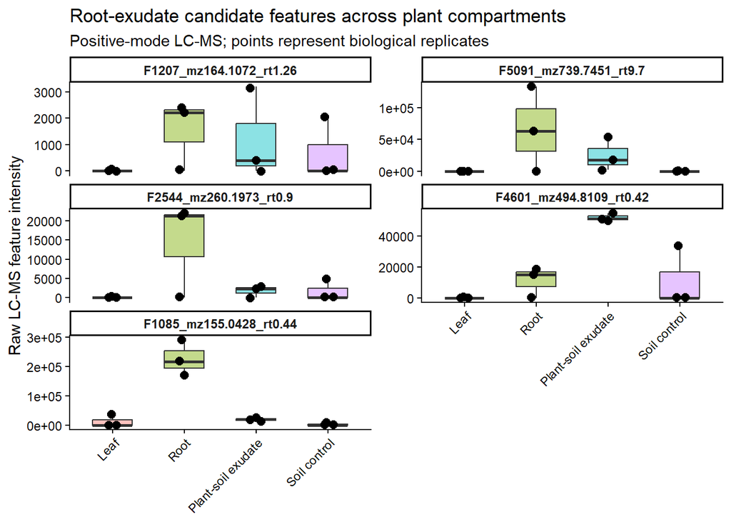

```r
ggplot(
  five_feature_plot_data,
  aes(
    x = group,
    y = raw_intensity,
    fill = group
  )
) +

  geom_boxplot(
    width = 0.55,
    outlier.shape = NA,
    alpha = 0.45
  ) +

  geom_jitter(
    width = 0.08,
    size = 2.5
  ) +

  facet_wrap(
    ~ feature_name,
    scales = "free_y",
    ncol = 2
  ) +

  labs(
    title = "Root-exudate candidate features across plant compartments",
    subtitle = "Positive-mode LC-MS; points represent biological replicates",
    x = NULL,
    y = "Raw LC-MS feature intensity"
  ) +

  theme_classic() +

  theme(
    legend.position = "none",

    axis.text.x = element_text(
      angle = 45,
      hjust = 1
    ),

    strip.text = element_text(
      face = "bold"
    )
  )
```

I also want you to make a log2 version

This will probably be much easier to interpret, because LC-MS peak heights can differ by orders of magnitude.

Use log2(intensity + 1) so zeros remain zeros:

```r
five_feature_plot_data <- five_feature_plot_data %>%
  mutate(
    log2_intensity =
      log2(raw_intensity + 1)
  )
```

Then:

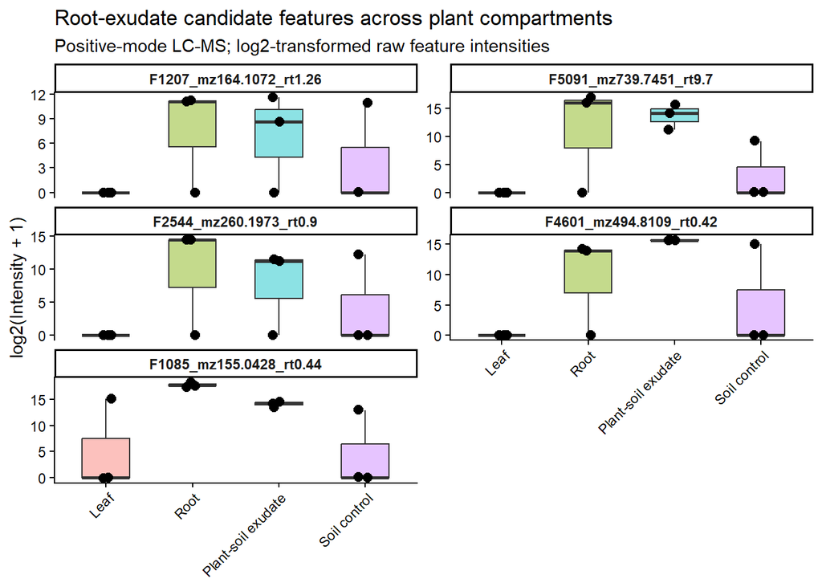

```r
ggplot(
  five_feature_plot_data,
  aes(
    x = group,
    y = log2_intensity,
    fill = group
  )
) +

  geom_boxplot(
    width = 0.55,
    outlier.shape = NA,
    alpha = 0.45
  ) +

  geom_jitter(
    width = 0.08,
    size = 2.5
  ) +

  facet_wrap(
    ~ feature_name,
    scales = "free_y",
    ncol = 2
  ) +

  labs(
    title = "Root-exudate candidate features across plant compartments",
    subtitle = "Positive-mode LC-MS; log2-transformed raw feature intensities",
    x = NULL,
    y = "log2(Intensity + 1)"
  ) +

  theme_classic() +

  theme(
    legend.position = "none",

    axis.text.x = element_text(
      angle = 45,
      hjust = 1
    ),

    strip.text = element_text(
      face = "bold"
    )
  )
```

And make one summary table

This will let us see the numbers behind the plots:

```r
five_feature_summary <- five_feature_plot_data %>%
  group_by(
    feature_name,
    group
  ) %>%
  summarise(

    n_detected =
      sum(
        raw_intensity > 0,
        na.rm = TRUE
      ),

    mean_intensity =
      mean(
        raw_intensity,
        na.rm = TRUE
      ),

    median_intensity =
      median(
        raw_intensity,
        na.rm = TRUE
      ),

    sd_intensity =
      sd(
        raw_intensity,
        na.rm = TRUE
      ),

    .groups = "drop"
  )

five_feature_summary
```

```
## # A tibble: 20 × 6
##    feature_name    group n_detected mean_intensity median_intensity sd_intensity
##    <fct>           <fct>      <int>          <dbl>            <dbl>        <dbl>
##  1 F1207_mz164.10… Leaf           0             0                 0           0
##  2 F1207_mz164.10… Root           2          1542.             2223        1339.
##  3 F1207_mz164.10… Plan…          2          1204               395        1754.
##  4 F1207_mz164.10… Soil…          1           664.                0        1150.
##  5 F5091_mz739.74… Leaf           0             0                 0           0
##  6 F5091_mz739.74… Root           2         65360.            62880       66635.
##  7 F5091_mz739.74… Plan…          3         24607.            17666       26384.
##  8 F5091_mz739.74… Soil…          1           191.                0         331.
##  9 F2544_mz260.19… Leaf           0             0                 0           0
## 10 F2544_mz260.19… Root           2         14407             21217       12483.
## 11 F2544_mz260.19… Plan…          2          1744.             2337        1536.
## 12 F2544_mz260.19… Soil…          1          1597.                0        2766.
## 13 F4601_mz494.81… Leaf           0             0                 0           0
## 14 F4601_mz494.81… Root           2         11209.            15057        9865.
## 15 F4601_mz494.81… Plan…          3         52070             51386        2561.
## 16 F4601_mz494.81… Soil…          1         11239.                0       19467.
## 17 F1085_mz155.04… Leaf           1         11361                 0       19678.
## 18 F1085_mz155.04… Root           3        226070.           217155       60318.
## 19 F1085_mz155.04… Plan…          3         18674             19102        6543.
## 20 F1085_mz155.04… Soil…          1          2510.                0        4348.
```

Plot the 5 candidate features across plant compartments # ———————————————————— # Plot 5 root-exudate candidate features across compartments # ————————————————————

```r
five_candidate_features <- c(
  "F1207_mz164.1072_rt1.26",
  "F5091_mz739.7451_rt9.7",
  "F2544_mz260.1973_rt0.9",
  "F4601_mz494.8109_rt0.42",
  "F1085_mz155.0428_rt0.44"
)

plant_sample_cols <- c(
  presence_groups$Leaf,
  presence_groups$Root,
  presence_groups$Exudate,
  presence_groups$Soil
)
```

Now reshape the raw intensity data:

```r
five_feature_plot_data <- feature_qc %>%

  filter(
    feature_name %in% five_candidate_features
  ) %>%

  select(
    feature_name,
    all_of(plant_sample_cols)
  ) %>%

  pivot_longer(
    cols = all_of(plant_sample_cols),
    names_to = "sample",
    values_to = "raw_intensity"
  ) %>%

  left_join(
    sample_metadata %>%
      select(
        sample,
        group
      ),
    by = "sample"
  )
```

Check it: five_feature_plot_data Give the compartments a biological order

```r
five_feature_plot_data <- five_feature_plot_data %>%
  mutate(

    group = factor(
      group,
      levels = c(
        "Leaf",
        "Root",
        "Plant-soil exudate",
        "Soil control"
      )
    ),

    feature_name = factor(
      feature_name,
      levels = five_candidate_features
    )
  )
```

Plot raw LC-MS intensities

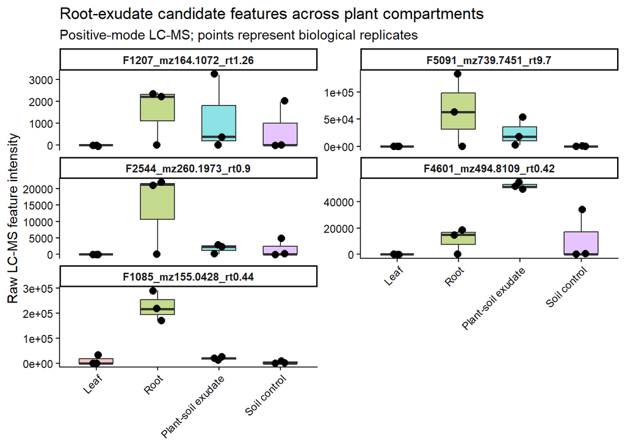

```r
ggplot(
  five_feature_plot_data,
  aes(
    x = group,
    y = raw_intensity,
    fill = group
  )
) +

  geom_boxplot(
    width = 0.55,
    outlier.shape = NA,
    alpha = 0.45
  ) +

  geom_jitter(
    width = 0.08,
    size = 2.5
  ) +

  facet_wrap(
    ~ feature_name,
    scales = "free_y",
    ncol = 2
  ) +

  labs(
    title = "Root-exudate candidate features across plant compartments",
    subtitle = "Positive-mode LC-MS; points represent biological replicates",
    x = NULL,
    y = "Raw LC-MS feature intensity"
  ) +

  theme_classic() +

  theme(
    legend.position = "none",

    axis.text.x = element_text(
      angle = 45,
      hjust = 1
    ),

    strip.text = element_text(
      face = "bold"
    )
  )
```

I also want you to make a log2 version

This will probably be much easier to interpret, because LC-MS peak heights can differ by orders of magnitude.

Use log2(intensity + 1) so zeros remain zeros:

```r
five_feature_plot_data <- five_feature_plot_data %>%
  mutate(
    log2_intensity =
      log2(raw_intensity + 1)
  )
```

Then:

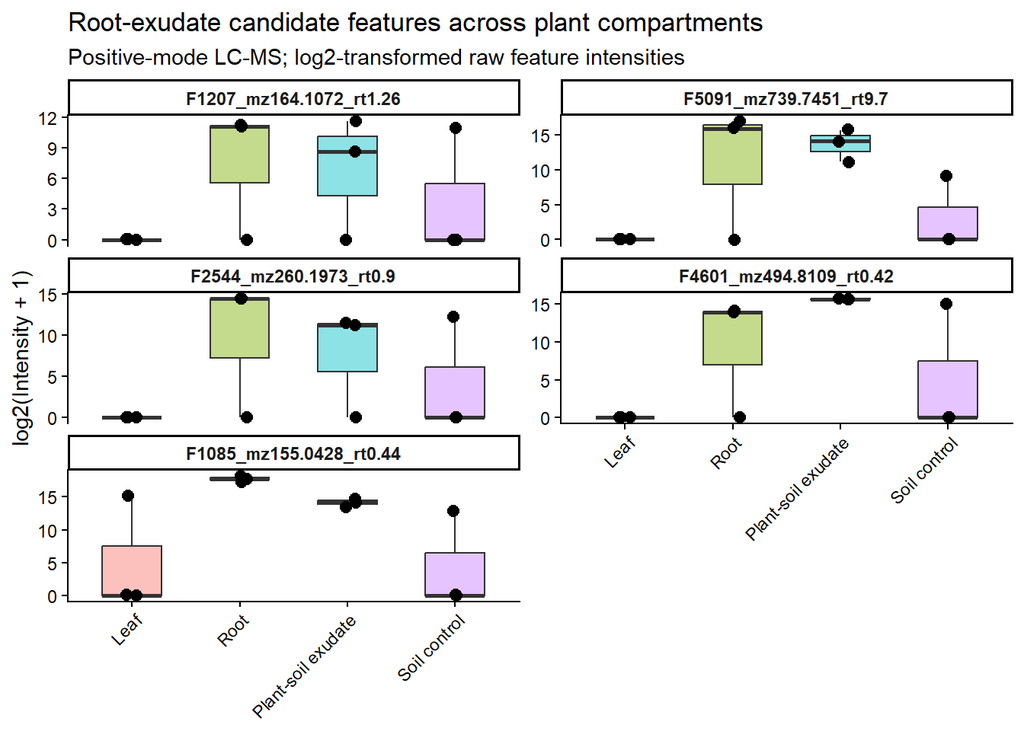

```r
ggplot(
  five_feature_plot_data,
  aes(
    x = group,
    y = log2_intensity,
    fill = group
  )
) +

  geom_boxplot(
    width = 0.55,
    outlier.shape = NA,
    alpha = 0.45
  ) +

  geom_jitter(
    width = 0.08,
    size = 2.5
  ) +

  facet_wrap(
    ~ feature_name,
    scales = "free_y",
    ncol = 2
  ) +

  labs(
    title = "Root-exudate candidate features across plant compartments",
    subtitle = "Positive-mode LC-MS; log2-transformed raw feature intensities",
    x = NULL,
    y = "log2(Intensity + 1)"
  ) +

  theme_classic() +

  theme(
    legend.position = "none",

    axis.text.x = element_text(
      angle = 45,
      hjust = 1
    ),

    strip.text = element_text(
      face = "bold"
    )
  )
```

And make one summary table

This will let us see the numbers behind the plots:

```r
five_feature_summary <- five_feature_plot_data %>%
  group_by(
    feature_name,
    group
  ) %>%
  summarise(

    n_detected =
      sum(
        raw_intensity > 0,
        na.rm = TRUE
      ),

    mean_intensity =
      mean(
        raw_intensity,
        na.rm = TRUE
      ),

    median_intensity =
      median(
        raw_intensity,
        na.rm = TRUE
      ),

    sd_intensity =
      sd(
        raw_intensity,
        na.rm = TRUE
      ),

    .groups = "drop"
  )

five_feature_summary
```

```
## # A tibble: 20 × 6
##    feature_name    group n_detected mean_intensity median_intensity sd_intensity
##    <fct>           <fct>      <int>          <dbl>            <dbl>        <dbl>
##  1 F1207_mz164.10… Leaf           0             0                 0           0
##  2 F1207_mz164.10… Root           2          1542.             2223        1339.
##  3 F1207_mz164.10… Plan…          2          1204               395        1754.
##  4 F1207_mz164.10… Soil…          1           664.                0        1150.
##  5 F5091_mz739.74… Leaf           0             0                 0           0
##  6 F5091_mz739.74… Root           2         65360.            62880       66635.
##  7 F5091_mz739.74… Plan…          3         24607.            17666       26384.
##  8 F5091_mz739.74… Soil…          1           191.                0         331.
##  9 F2544_mz260.19… Leaf           0             0                 0           0
## 10 F2544_mz260.19… Root           2         14407             21217       12483.
## 11 F2544_mz260.19… Plan…          2          1744.             2337        1536.
## 12 F2544_mz260.19… Soil…          1          1597.                0        2766.
## 13 F4601_mz494.81… Leaf           0             0                 0           0
## 14 F4601_mz494.81… Root           2         11209.            15057        9865.
## 15 F4601_mz494.81… Plan…          3         52070             51386        2561.
## 16 F4601_mz494.81… Soil…          1         11239.                0       19467.
## 17 F1085_mz155.04… Leaf           1         11361                 0       19678.
## 18 F1085_mz155.04… Root           3        226070.           217155       60318.
## 19 F1085_mz155.04… Plan…          3         18674             19102        6543.
## 20 F1085_mz155.04… Soil…          1          2510.                0        4348.
```

101. create fungal sample columns

```r
# ------------------------------------------------------------
# FUNGAL COMPARTMENT / AGE FEATURE PLOTS
# ------------------------------------------------------------

fungal_sample_cols <- c(
  presence_groups$Fungal_control,
  presence_groups$Fungal_out,
  presence_groups$Fungal_in,
  presence_groups$Fungi_old
)

fungal_sample_cols
```

```
##  [1] "FC_1"        "FC_2"        "FC_3"        "new_out_P08" "new_out_P09"
##  [6] "new_out_P10" "new_in_P08"  "new_in_P09"  "new_in_P10"  "fungi_old_1"
## [11] "fungi_old_2" "fungi_old_3"
```

102. Make fungal data long-format

```r
fungal_long <- feature_qc %>%

  select(
    feature_name,
    `Average Rt(min)`,
    `Average Mz`,
    `Metabolite name`,
    `Adduct type`,
    `MS/MS assigned`,
    all_of(fungal_sample_cols)
  ) %>%

  pivot_longer(
    cols = all_of(fungal_sample_cols),
    names_to = "sample",
    values_to = "raw_intensity"
  ) %>%

  left_join(
    sample_metadata %>%
      select(
        sample,
        group
      ),
    by = "sample"
  )
```

check

```r
fungal_long %>%
  count(group)
```

```
## # A tibble: 4 × 2
##   group               n
##   <chr>           <int>
## 1 Fungal agar in  12432
## 2 Fungal agar out 12432
## 3 Fungal control  12432
## 4 Fungi old       12432
```

103 Put the fungal conditions in biological order

```r
fungal_long <- fungal_long %>%
  mutate(

    group = factor(
      group,
      levels = c(
        "Fungal control",
        "Fungal agar out",
        "Fungal agar in",
        "Fungi old"
      )
    ),

    log2_intensity =
      log2(raw_intensity + 1)
  )
```

104. First identify the strongest old-vs-new features

```r
top_fungal_age_candidates <-
  age_sensitive_fungal_ranked %>%

  filter(
    old_new_FDR < 0.05
  ) %>%

  arrange(
    old_new_FDR,
    desc(abs(old_new_logFC))
  ) %>%

  slice_head(
    n = 10
  ) %>%

  pull(feature_name)

top_fungal_age_candidates
```

```
##  [1] "F4086_mz393.2866_rt2.14" "F4756_mz555.4051_rt3.42"
##  [3] "F2053_mz222.1129_rt1.18" "F1476_mz182.0814_rt0.52"
##  [5] "F2331_mz244.264_rt2.03"  "F1910_mz213.0761_rt0.97"
##  [7] "F2330_mz244.2639_rt1.89" "F2420_mz251.1605_rt0.4"
##  [9] "F2934_mz288.29_rt1.99"   "F1728_mz200.1034_rt0.8"
```

105. Plot the top 10 across all foud fungal conditions

```r
top_fungal_plot_data <-
  fungal_long %>%

  filter(
    feature_name %in%
      top_fungal_age_candidates
  )
```

plot the raw intensities Which metabolites/features change as the fungus ages?

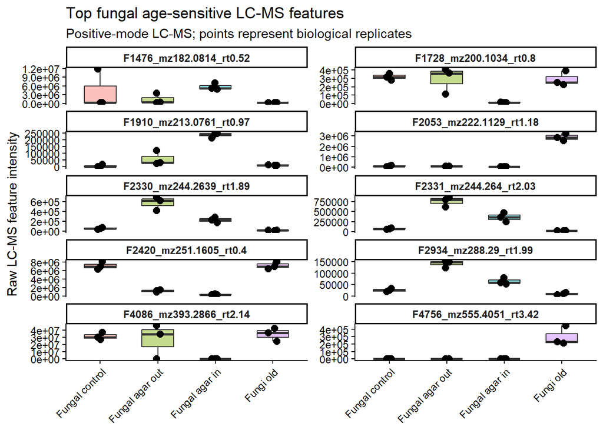

```r
ggplot(
  top_fungal_plot_data,
  aes(
    x = group,
    y = raw_intensity,
    fill = group
  )
) +

  geom_boxplot(
    width = 0.55,
    outlier.shape = NA,
    alpha = 0.45
  ) +

  geom_jitter(
    width = 0.08,
    size = 2.5
  ) +

  facet_wrap(
    ~ feature_name,
    scales = "free_y",
    ncol = 2
  ) +

  labs(
    title = "Top fungal age-sensitive LC-MS features",
    subtitle =
      "Positive-mode LC-MS; points represent biological replicates",
    x = NULL,
    y = "Raw LC-MS feature intensity"
  ) +

  theme_classic() +

  theme(
    legend.position = "none",

    axis.text.x =
      element_text(
        angle = 45,
        hjust = 1
      ),

    strip.text =
      element_text(
        face = "bold"
      )
  )
```

106 make the log2 version Which metabolites/features change as the fungus ages?

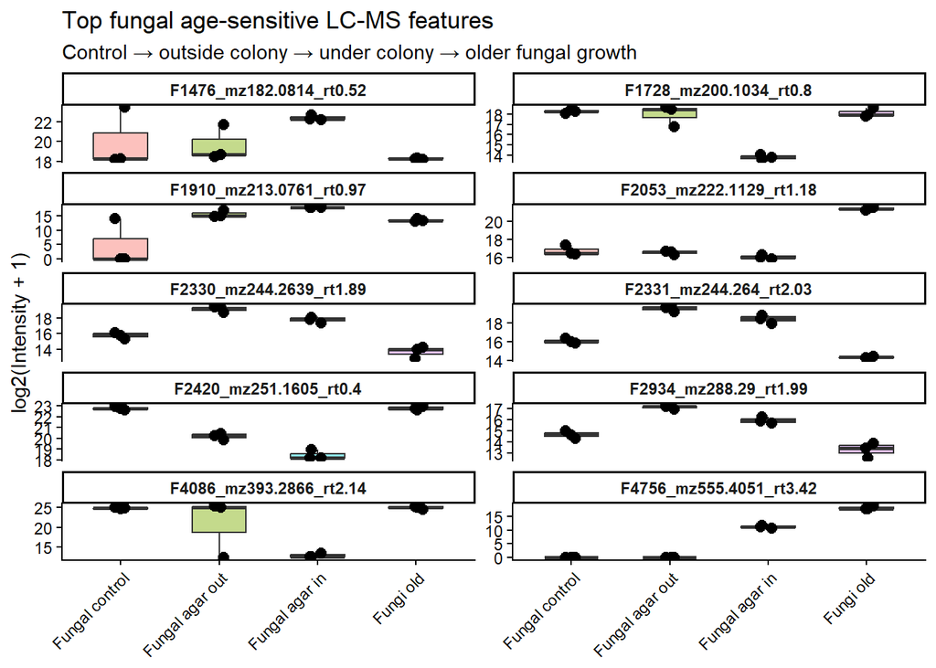

```r
ggplot(
  top_fungal_plot_data,
  aes(
    x = group,
    y = log2_intensity,
    fill = group
  )
) +

  geom_boxplot(
    width = 0.55,
    outlier.shape = NA,
    alpha = 0.45
  ) +

  geom_jitter(
    width = 0.08,
    size = 2.5
  ) +

  facet_wrap(
    ~ feature_name,
    scales = "free_y",
    ncol = 2
  ) +

  labs(
    title =
      "Top fungal age-sensitive LC-MS features",

    subtitle =
      "Control → outside colony → under colony → older fungal growth",

    x = NULL,
    y = "log2(Intensity + 1)"
  ) +

  theme_classic() +

  theme(
    legend.position = "none",

    axis.text.x =
      element_text(
        angle = 45,
        hjust = 1
      ),

    strip.text =
      element_text(
        face = "bold"
      )
  )
```

107 make a summary table

```r
fungal_candidate_summary <-
  top_fungal_plot_data %>%

  group_by(
    feature_name,
    group
  ) %>%

  summarise(

    detected_n =
      sum(
        raw_intensity > 0,
        na.rm = TRUE
      ),

    mean_intensity =
      mean(
        raw_intensity,
        na.rm = TRUE
      ),

    median_intensity =
      median(
        raw_intensity,
        na.rm = TRUE
      ),

    sd_intensity =
      sd(
        raw_intensity,
        na.rm = TRUE
      ),

    .groups = "drop"
  )

fungal_candidate_summary
```

```
## # A tibble: 40 × 6
##    feature_name    group detected_n mean_intensity median_intensity sd_intensity
##    <chr>           <fct>      <int>          <dbl>            <dbl>        <dbl>
##  1 F1476_mz182.08… Fung…          3       4132126.           319172     6619082.
##  2 F1476_mz182.08… Fung…          3       1436054.           427040     1799969.
##  3 F1476_mz182.08… Fung…          3       5783593.          5291086     1158264.
##  4 F1476_mz182.08… Fung…          3        312977.           317827       15507.
##  5 F1728_mz200.10… Fung…          3        315530.           312815       38891.
##  6 F1728_mz200.10… Fung…          3        292369            358189      157724.
##  7 F1728_mz200.10… Fung…          3         14327.            13930        2355.
##  8 F1728_mz200.10… Fung…          3        288272            251843       88026.
##  9 F1910_mz213.07… Fung…          1          5312.                0        9200.
## 10 F1910_mz213.07… Fung…          3         58690             30935       53449.
## # ℹ 30 more rows
```

108 and we should do the 14 age-stable features separately

```r
age_stable_feature_names <-
  age_stable_fungal_features %>%
  pull(feature_name)

length(age_stable_feature_names)
```

```
## [1] 14
```

then

```r
age_stable_plot_data <-
  fungal_long %>%
  filter(
    feature_name %in%
      age_stable_feature_names
  )
```

plot Which metabolites/features appear to be consistently associated with fungal growth regardless of age?

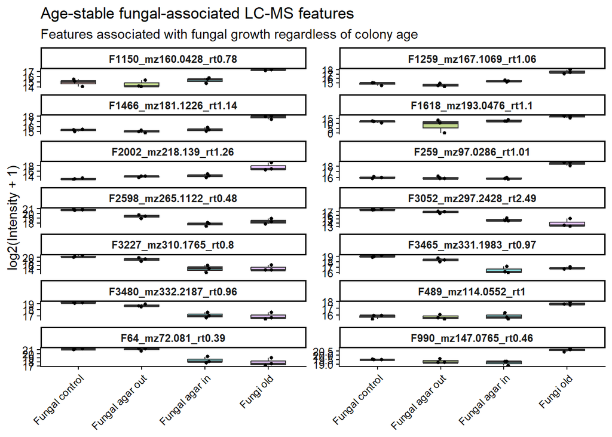

```r
ggplot(
  age_stable_plot_data,
  aes(
    x = group,
    y = log2_intensity,
    fill = group
  )
) +

  geom_boxplot(
    width = 0.55,
    outlier.shape = NA,
    alpha = 0.45
  ) +

  geom_jitter(
    width = 0.08,
    size = 1.0
  ) +

  facet_wrap(
    ~ feature_name,
    scales = "free_y",
    ncol = 2
  ) +

  labs(
    title =
      "Age-stable fungal-associated LC-MS features",

    subtitle =
      "Features associated with fungal growth regardless of colony age",

    x = NULL,
    y = "log2(Intensity + 1)"
  ) +

  theme_classic() +

  theme(
    legend.position = "none",

    axis.text.x =
      element_text(
        angle = 45,
        hjust = 1
      ),

    strip.text =
      element_text(
        face = "bold"
      )
  )
```

109 define all biological compartments

```r
# ------------------------------------------------------------
# CROSS-COMPARTMENT FEATURE OVERLAP
# Plant tissues + exudate + fungal samples
# ------------------------------------------------------------

cross_compartment_groups <- list(

  Leaf =
    presence_groups$Leaf,

  Root =
    presence_groups$Root,

  Exudate =
    presence_groups$Exudate,

  Soil =
    presence_groups$Soil,

  Fungal_control =
    presence_groups$Fungal_control,

  Fungal_out =
    presence_groups$Fungal_out,

  Fungal_in =
    presence_groups$Fungal_in,

  Fungi_old =
    presence_groups$Fungi_old
)
```

110 count detection in every compartment

```r
cross_compartment_presence <- feature_qc %>%

  mutate(

    leaf_n =
      rowSums(
        across(
          all_of(cross_compartment_groups$Leaf),
          ~ .x > 0
        ),
        na.rm = TRUE
      ),

    root_n =
      rowSums(
        across(
          all_of(cross_compartment_groups$Root),
          ~ .x > 0
        ),
        na.rm = TRUE
      ),

    exudate_n =
      rowSums(
        across(
          all_of(cross_compartment_groups$Exudate),
          ~ .x > 0
        ),
        na.rm = TRUE
      ),

    soil_n =
      rowSums(
        across(
          all_of(cross_compartment_groups$Soil),
          ~ .x > 0
        ),
        na.rm = TRUE
      ),

    fungal_control_n =
      rowSums(
        across(
          all_of(cross_compartment_groups$Fungal_control),
          ~ .x > 0
        ),
        na.rm = TRUE
      ),

    fungal_out_n =
      rowSums(
        across(
          all_of(cross_compartment_groups$Fungal_out),
          ~ .x > 0
        ),
        na.rm = TRUE
      ),

    fungal_in_n =
      rowSums(
        across(
          all_of(cross_compartment_groups$Fungal_in),
          ~ .x > 0
        ),
        na.rm = TRUE
      ),

    fungi_old_n =
      rowSums(
        across(
          all_of(cross_compartment_groups$Fungi_old),
          ~ .x > 0
        ),
        na.rm = TRUE
      )
  )
```

111 convert those counts into presence/absence

```r
cross_compartment_presence <-
  cross_compartment_presence %>%

  mutate(

    leaf_present =
      leaf_n >= 2,

    root_present =
      root_n >= 2,

    exudate_present =
      exudate_n >= 2,

    soil_present =
      soil_n >= 2,

    fungal_control_present =
      fungal_control_n >= 2,

    fungal_out_present =
      fungal_out_n >= 2,

    fungal_in_present =
      fungal_in_n >= 2,

    fungi_old_present =
      fungi_old_n >= 2
  )
```

112 how many features overlap plant and fungal samples. how many features are consistenly detected somewhere in the plant system and somewhere in fungus-associated samples?

```r
cross_compartment_presence <-
  cross_compartment_presence %>%

  mutate(

    plant_present =
      leaf_present |
      root_present |
      exudate_present,

    fungus_present =
      fungal_in_present |
      fungal_out_present |
      fungi_old_present,

    plant_and_fungus =
      plant_present &
      fungus_present
  )
```

count them

```r
cross_compartment_presence %>%
  summarise(

    total_features =
      n(),

    plant_features =
      sum(
        plant_present
      ),

    fungal_features =
      sum(
        fungus_present
      ),

    plant_and_fungal_features =
      sum(
        plant_and_fungus
      )
  )
```

```
## # A tibble: 1 × 4
##   total_features plant_features fungal_features plant_and_fungal_features
##            <int>          <int>           <int>                     <int>
## 1           4144           3211            3037                      2124
```

113 look specifically for root + exudate + fungus

```r
root_exudate_fungal_features <-
  cross_compartment_presence %>%

  filter(

    root_present,

    exudate_present,

    fungal_in_present |
      fungi_old_present
  )
```

count

```r
nrow(
  root_exudate_fungal_features
)
```

```
## [1] 1063
```

114 exclude things also consistently present in controls

```r
root_exudate_fungal_not_controls <-
  cross_compartment_presence %>%

  filter(

    root_present,

    exudate_present,

    fungal_in_present |
      fungi_old_present,

    !soil_present,

    !fungal_control_present
  )
```

count

```r
nrow(
  root_exudate_fungal_not_controls
)
```

```
## [1] 4
```

115 look for exudate +fungus but not root

```r
exudate_fungal_not_root <-
  cross_compartment_presence %>%

  filter(

    exudate_present,

    fungal_in_present |
      fungi_old_present,

    !root_present,

    !soil_present,

    !fungal_control_present
  )
```

count

```r
nrow(
  exudate_fungal_not_root
)
```

```
## [1] 5
```

116 look for root + fungus but not exudate

```r
root_fungal_not_exudate <-
  cross_compartment_presence %>%

  filter(

    root_present,

    fungal_in_present |
      fungi_old_present,

    !exudate_present
  )
```

count

```r
nrow(
  root_fungal_not_exudate
)
```

```
## [1] 379
```

117 create a biologicallt useful classification

```r
cross_compartment_presence <-
  cross_compartment_presence %>%

  mutate(

    cross_pattern = case_when(

      root_present &
        exudate_present &
        fungal_in_present &
        !soil_present &
        !fungal_control_present ~
        "Root + Exudate + Fungal in",

      root_present &
        exudate_present &
        fungi_old_present &
        !soil_present &
        !fungal_control_present ~
        "Root + Exudate + Fungi old",

      root_present &
        exudate_present &
        fungal_in_present &
        fungi_old_present &
        !soil_present &
        !fungal_control_present ~
        "Root + Exudate + New and Old fungus",

      exudate_present &
        fungal_in_present &
        !root_present &
        !soil_present &
        !fungal_control_present ~
        "Exudate + Fungal in",

      root_present &
        fungal_in_present &
        !exudate_present ~
        "Root + Fungal in",

      leaf_present &
        root_present &
        exudate_present &
        fungus_present ~
        "Leaf + Root + Exudate + Fungus",

      TRUE ~
        "Other pattern"
    )
  )
```

alternative: chooses the first condition that matches. the most specific category should come first.

```r
cross_compartment_presence <-
  cross_compartment_presence %>%

  mutate(

    cross_pattern = case_when(

      root_present &
        exudate_present &
        fungal_in_present &
        fungi_old_present &
        !soil_present &
        !fungal_control_present ~
        "Root + Exudate + New and Old fungus",

      root_present &
        exudate_present &
        fungal_in_present &
        !soil_present &
        !fungal_control_present ~
        "Root + Exudate + Fungal in",

      root_present &
        exudate_present &
        fungi_old_present &
        !soil_present &
        !fungal_control_present ~
        "Root + Exudate + Fungi old",

      exudate_present &
        fungal_in_present &
        !root_present &
        !soil_present &
        !fungal_control_present ~
        "Exudate + Fungal in",

      root_present &
        fungal_in_present &
        !exudate_present ~
        "Root + Fungal in",

      leaf_present &
        root_present &
        exudate_present &
        fungus_present ~
        "Leaf + Root + Exudate + Fungus",

      TRUE ~
        "Other pattern"
    )
  )
```

118 count those biological patterns

```r
cross_pattern_summary <-
  cross_compartment_presence %>%

  count(
    cross_pattern,
    sort = TRUE
  ) %>%

  mutate(
    percent =
      100 * n / sum(n)
  )

cross_pattern_summary
```

```
## # A tibble: 6 × 3
##   cross_pattern                           n percent
##   <chr>                               <int>   <dbl>
## 1 Other pattern                        2839 68.5
## 2 Leaf + Root + Exudate + Fungus       1003 24.2
## 3 Root + Fungal in                      297  7.17
## 4 Root + Exudate + New and Old fungus     3  0.0724
## 5 Exudate + Fungal in                     1  0.0241
## 6 Root + Exudate + Fungal in              1  0.0241
```

119 check whether our five root-exudate candidates occur in fungal samples

```r
five_cross_compartment <-
  cross_compartment_presence %>%

  filter(
    feature_name %in%
      five_candidate_features
  ) %>%

  select(

    feature_name,

    `Average Rt(min)`,

    `Average Mz`,

    `MS/MS assigned`,

    leaf_n,
    root_n,
    exudate_n,
    soil_n,

    fungal_control_n,
    fungal_out_n,
    fungal_in_n,
    fungi_old_n,

    leaf_present,
    root_present,
    exudate_present,
    soil_present,

    fungal_control_present,
    fungal_out_present,
    fungal_in_present,
    fungi_old_present
  )

five_cross_compartment
```

```
## # A tibble: 5 × 20
##   feature_name     `Average Rt(min)` `Average Mz` `MS/MS assigned` leaf_n root_n
##   <chr>                        <dbl>        <dbl> <lgl>             <dbl>  <dbl>
## 1 F1085_mz155.042…             0.441         155. FALSE                 1      3
## 2 F1207_mz164.107…             1.26          164. TRUE                  0      2
## 3 F2544_mz260.197…             0.897         260. TRUE                  0      2
## 4 F4601_mz494.810…             0.417         495. FALSE                 0      2
## 5 F5091_mz739.745…             9.70          740. FALSE                 0      2
## # ℹ 14 more variables: exudate_n <dbl>, soil_n <dbl>, fungal_control_n <dbl>,
## #   fungal_out_n <dbl>, fungal_in_n <dbl>, fungi_old_n <dbl>,
## #   leaf_present <lgl>, root_present <lgl>, exudate_present <lgl>,
## #   soil_present <lgl>, fungal_control_present <lgl>, fungal_out_present <lgl>,
## #   fungal_in_present <lgl>, fungi_old_present <lgl>
```

120 save the cross-compartment results

```r
write.csv(
  cross_compartment_presence,
  "positive_mode_cross_compartment_presence.csv",
  row.names = FALSE
)

write.csv(
  cross_pattern_summary,
  "positive_mode_cross_compartment_pattern_summary.csv",
  row.names = FALSE
)

write.csv(
  root_exudate_fungal_not_controls,
  "positive_mode_root_exudate_fungal_candidates.csv",
  row.names = FALSE
)

write.csv(
  five_cross_compartment,
  "positive_mode_five_candidates_cross_compartment.csv",
  row.names = FALSE
)
```

inspect the 4 features Notice that only one of your original five candidates appears to meet this stricter fungal-control criterion: F5091. The other three candidates among the four must therefore be features elsewhere in the dataset that weren’t part of your original five-feature root/exudate shortlist.

I would inspect those four next

```r
root_exudate_fungal_not_controls %>%
  select(
    feature_name,
    `Average Rt(min)`,
    `Average Mz`,
    `Metabolite name`,
    `Adduct type`,
    `MS/MS assigned`,
    Formula,
    Ontology,
    `Total score`,
    sample_to_blank_ratio,

    leaf_n,
    root_n,
    exudate_n,
    soil_n,

    fungal_control_n,
    fungal_out_n,
    fungal_in_n,
    fungi_old_n
  )
```

```
## # A tibble: 4 × 18
##   feature_name    `Average Rt(min)` `Average Mz` `Metabolite name` `Adduct type`
##   <chr>                       <dbl>        <dbl> <chr>             <chr>
## 1 F1105_mz156.98…             0.514         157. Unknown           [M+H]+
## 2 F3005_mz294.00…             0.456         294. Unknown           [M+H]+
## 3 F3515_mz335.22…             3.55          335. Unknown           [M+H]+
## 4 F5091_mz739.74…             9.70          740. Unknown           [M+H]+
## # ℹ 13 more variables: `MS/MS assigned` <lgl>, Formula <chr>, Ontology <chr>,
## #   `Total score` <chr>, sample_to_blank_ratio <dbl>, leaf_n <dbl>,
## #   root_n <dbl>, exudate_n <dbl>, soil_n <dbl>, fungal_control_n <dbl>,
## #   fungal_out_n <dbl>, fungal_in_n <dbl>, fungi_old_n <dbl>
```

make boxplotsa

```r
cross_candidate_names <-
  root_exudate_fungal_not_controls %>%
  pull(feature_name)
```

creat long daya

```r
cross_candidate_samples <- c(
  presence_groups$Leaf,
  presence_groups$Root,
  presence_groups$Exudate,
  presence_groups$Soil,
  presence_groups$Fungal_control,
  presence_groups$Fungal_out,
  presence_groups$Fungal_in,
  presence_groups$Fungi_old
)

cross_candidate_plot_data <- feature_qc %>%

  filter(
    feature_name %in%
      cross_candidate_names
  ) %>%

  select(
    feature_name,
    all_of(
      cross_candidate_samples
    )
  ) %>%

  pivot_longer(
    cols =
      all_of(
        cross_candidate_samples
      ),
    names_to =
      "sample",
    values_to =
      "raw_intensity"
  ) %>%

  left_join(
    sample_metadata %>%
      select(
        sample,
        group
      ),
    by = "sample"
  ) %>%

  mutate(
    group = factor(
      group,
      levels = c(
        "Leaf",
        "Root",
        "Plant-soil exudate",
        "Soil control",
        "Fungal control",
        "Fungal agar out",
        "Fungal agar in",
        "Fungi old"
      )
    ),

    log2_intensity =
      log2(
        raw_intensity + 1
      )
  )
```

plot

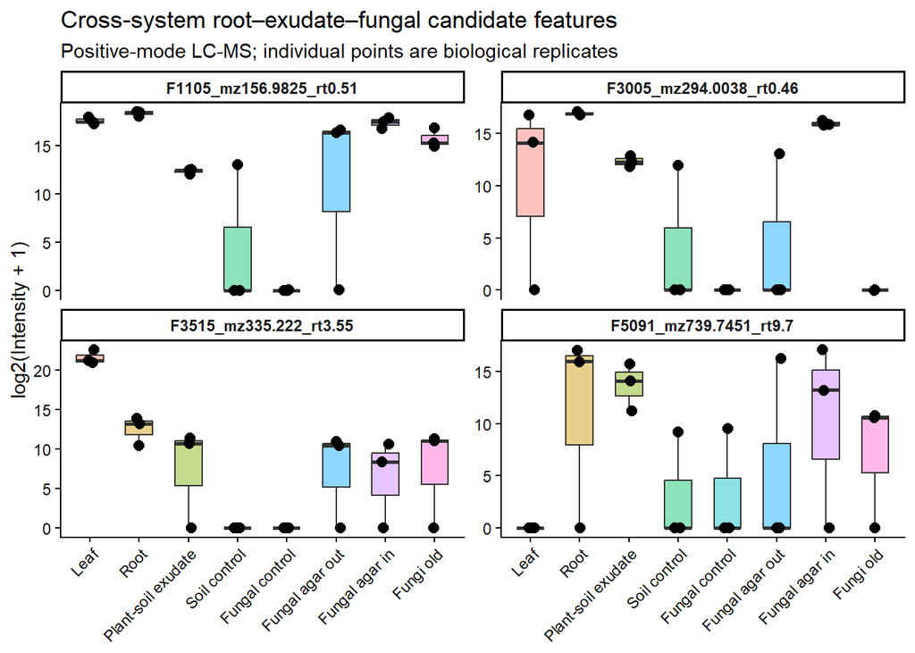

```r
ggplot(
  cross_candidate_plot_data,
  aes(
    x = group,
    y = log2_intensity,
    fill = group
  )
) +

  geom_boxplot(
    width = 0.55,
    outlier.shape = NA,
    alpha = 0.45
  ) +

  geom_jitter(
    width = 0.08,
    size = 2.5
  ) +

  facet_wrap(
    ~ feature_name,
    scales = "free_y",
    ncol = 2
  ) +

  labs(
    title =
      "Cross-system root–exudate–fungal candidate features",

    subtitle =
      "Positive-mode LC-MS; individual points are biological replicates",

    x = NULL,

    y =
      "log2(Intensity + 1)"
  ) +

  theme_classic() +

  theme(
    legend.position =
      "none",

    axis.text.x =
      element_text(
        angle = 45,
        hjust = 1
      ),

    strip.text =
      element_text(
        face = "bold"
      )
  )
```

#simplified statistics

121. Master feature-count table by biological compartment

This tells you how many of the 4,144 filtered features are reproducibly detected in each individual sample type.

# ————————————————————

# PI PRESENTATION: RESULTS SUMMARY

# ————————————————————

```r
compartment_feature_counts <- tibble(

  compartment = c(
    "Leaf",
    "Root",
    "Plant-soil exudate",
    "Soil control",
    "Fungal control",
    "Fungal agar out",
    "Fungal agar in",
    "Fungi old"
  ),

  detected_features = c(

    sum(
      cross_compartment_presence$leaf_present,
      na.rm = TRUE
    ),

    sum(
      cross_compartment_presence$root_present,
      na.rm = TRUE
    ),

    sum(
      cross_compartment_presence$exudate_present,
      na.rm = TRUE
    ),

    sum(
      cross_compartment_presence$soil_present,
      na.rm = TRUE
    ),

    sum(
      cross_compartment_presence$fungal_control_present,
      na.rm = TRUE
    ),

    sum(
      cross_compartment_presence$fungal_out_present,
      na.rm = TRUE
    ),

    sum(
      cross_compartment_presence$fungal_in_present,
      na.rm = TRUE
    ),

    sum(
      cross_compartment_presence$fungi_old_present,
      na.rm = TRUE
    )
  )
)

compartment_feature_counts
```

```
## # A tibble: 8 × 2
##   compartment        detected_features
##   <chr>                          <int>
## 1 Leaf                            2829
## 2 Root                            1958
## 3 Plant-soil exudate              1515
## 4 Soil control                    1510
## 5 Fungal control                  2752
## 6 Fungal agar out                 2668
## 7 Fungal agar in                  2379
## 8 Fungi old                       2569
```

122. Plot number of reproducibly detected features in every compartment

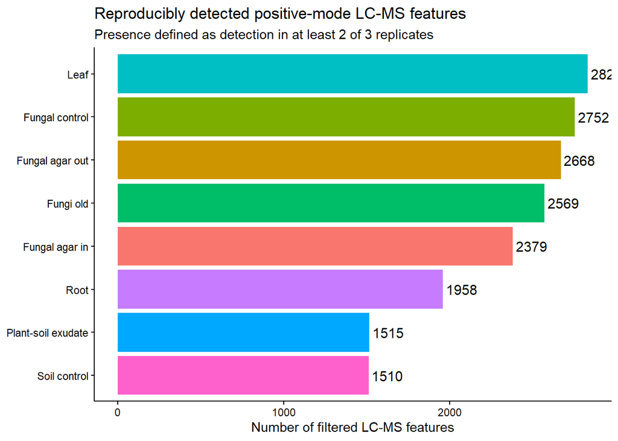

```r
compartment_feature_plot <- ggplot(
  compartment_feature_counts,
  aes(
    x = reorder(
      compartment,
      detected_features
    ),
    y = detected_features,
    fill = compartment
  )
) +

  geom_col() +

  coord_flip() +

  geom_text(
    aes(
      label = detected_features
    ),
    hjust = -0.1,
    size = 4
  ) +

  labs(
    title =
      "Reproducibly detected positive-mode LC-MS features",
    subtitle =
      "Presence defined as detection in at least 2 of 3 replicates",
    x = NULL,
    y = "Number of filtered LC-MS features"
  ) +

  theme_classic() +

  theme(
    legend.position = "none"
  )

compartment_feature_plot
```

Save it:

```r
ggsave(
  "PI_figure_feature_counts_by_compartment.png",
  compartment_feature_plot,
  width = 9,
  height = 6,
  dpi = 300
)
```

123. Create the broad plant–fungus overlap summary

These are the numbers you just obtained.

```r
plant_fungal_overlap_summary <- tibble(

  category = c(
    "All filtered features",
    "Plant-associated",
    "Fungus-associated",
    "Plant + fungus overlap",
    "Strict root-exudate-fungus candidates"
  ),

  n = c(

    nrow(
      cross_compartment_presence
    ),

    sum(
      cross_compartment_presence$plant_present,
      na.rm = TRUE
    ),

    sum(
      cross_compartment_presence$fungus_present,
      na.rm = TRUE
    ),

    sum(
      cross_compartment_presence$plant_and_fungus,
      na.rm = TRUE
    ),

    nrow(
      root_exudate_fungal_not_controls
    )
  )
)

plant_fungal_overlap_summary
```

```
## # A tibble: 5 × 2
##   category                                  n
##   <chr>                                 <int>
## 1 All filtered features                  4144
## 2 Plant-associated                       3211
## 3 Fungus-associated                      3037
## 4 Plant + fungus overlap                 2124
## 5 Strict root-exudate-fungus candidates     4
```

124. Plot the biological filtering funnel

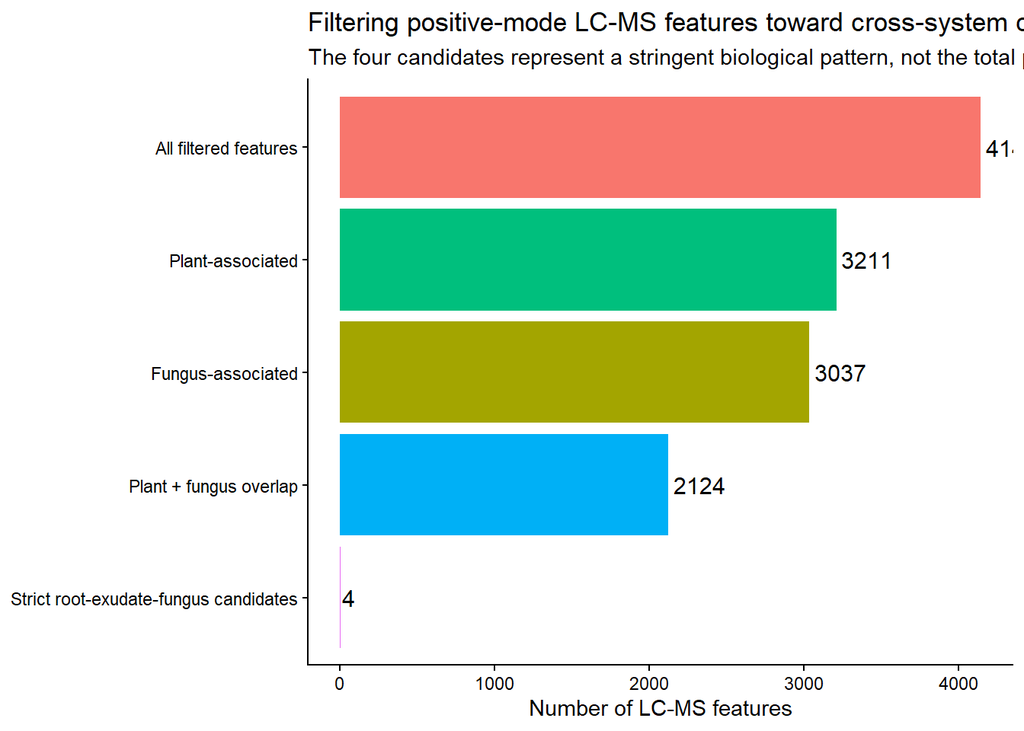

```r
candidate_funnel_plot <- ggplot(
  plant_fungal_overlap_summary,
  aes(
    x = factor(
      category,
      levels = rev(category)
    ),
    y = n,
    fill = category
  )
) +

  geom_col() +

  coord_flip() +

  geom_text(
    aes(label = n),
    hjust = -0.1,
    size = 4
  ) +

  labs(
    title =
      "Filtering positive-mode LC-MS features toward cross-system candidates",
    subtitle =
      "The four candidates represent a stringent biological pattern, not the total plant-fungal overlap",
    x = NULL,
    y = "Number of LC-MS features"
  ) +

  theme_classic() +

  theme(
    legend.position = "none"
  )

candidate_funnel_plot
```

125. Calculate plant-only, fungus-only, and shared feature numbers

```r
plant_fungal_partition <- cross_compartment_presence %>%
  summarise(

    plant_only =
      sum(
        plant_present &
          !fungus_present,
        na.rm = TRUE
      ),

    fungus_only =
      sum(
        fungus_present &
          !plant_present,
        na.rm = TRUE
      ),

    plant_and_fungus =
      sum(
        plant_present &
          fungus_present,
        na.rm = TRUE
      ),

    neither =
      sum(
        !plant_present &
          !fungus_present,
        na.rm = TRUE
      )
  )

plant_fungal_partition
```

```
## # A tibble: 1 × 4
##   plant_only fungus_only plant_and_fungus neither
##        <int>       <int>            <int>   <int>
## 1       1087         913             2124      20
```

126. Plot the plant–fungus partition

First reshape:

```r
plant_fungal_partition_long <-
  plant_fungal_partition %>%
  pivot_longer(
    everything(),
    names_to = "category",
    values_to = "features"
  ) %>%
  mutate(

    category = recode(
      category,

      plant_only =
        "Plant only",

      fungus_only =
        "Fungus only",

      plant_and_fungus =
        "Plant + fungus",

      neither =
        "Neither consistently detected"
    )
  )
```

Plot:

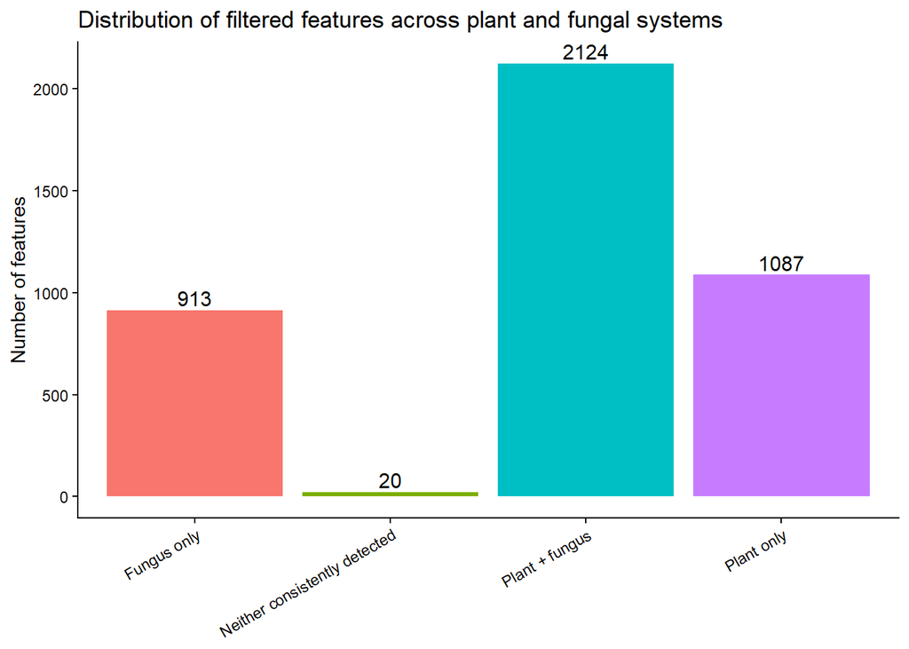

```r
plant_fungal_partition_plot <- ggplot(
  plant_fungal_partition_long,
  aes(
    x = category,
    y = features,
    fill = category
  )
) +

  geom_col() +

  geom_text(
    aes(label = features),
    vjust = -0.3,
    size = 4
  ) +

  labs(
    title =
      "Distribution of filtered features across plant and fungal systems",
    x = NULL,
    y = "Number of features"
  ) +

  theme_classic() +

  theme(
    legend.position = "none",
    axis.text.x =
      element_text(
        angle = 30,
        hjust = 1
      )
  )

plant_fungal_partition_plot
```

127. Pairwise overlap table across all eight biological compartments

How many features are shared between root and exudate? Root and fungal-in? Exudate and fungal-in? Fungal-in and old fungus?

Create a logical matrix:

```r
presence_matrix <- cross_compartment_presence %>%
  select(
    Leaf = leaf_present,
    Root = root_present,
    Exudate = exudate_present,
    Soil = soil_present,
    Fungal_control = fungal_control_present,
    Fungal_out = fungal_out_present,
    Fungal_in = fungal_in_present,
    Fungi_old = fungi_old_present
  )
```

Then:

```r
presence_matrix_numeric <-
  as.matrix(
    presence_matrix
  ) * 1
```

Calculate pairwise overlap:

```r
pairwise_overlap_matrix <-
  t(presence_matrix_numeric) %*%
  presence_matrix_numeric

pairwise_overlap_matrix
```

```
##                Leaf Root Exudate Soil Fungal_control Fungal_out Fungal_in
## Leaf           2829 1805    1214 1220           1641       1612      1477
## Root           1805 1958    1114 1113           1367       1358      1304
## Exudate        1214 1114    1515 1386           1354       1343      1276
## Soil           1220 1113    1386 1510           1351       1334      1273
## Fungal_control 1641 1367    1354 1351           2752       2556      2270
## Fungal_out     1612 1358    1343 1334           2556       2668      2290
## Fungal_in      1477 1304    1276 1273           2270       2290      2379
## Fungi_old      1637 1353    1350 1357           2269       2236      2053
##                Fungi_old
## Leaf                1637
## Root                1353
## Exudate             1350
## Soil                1357
## Fungal_control      2269
## Fungal_out          2236
## Fungal_in           2053
## Fungi_old           2569
```

This is a very important table.

The diagonal tells you:

Leaf vs Leaf = total leaf features Root vs Root = total root features …

And an off-diagonal cell such as:

Root × Exudate

tells you exactly how many filtered features are reproducibly present in both.

128. Make the overlap matrix into a heatmap

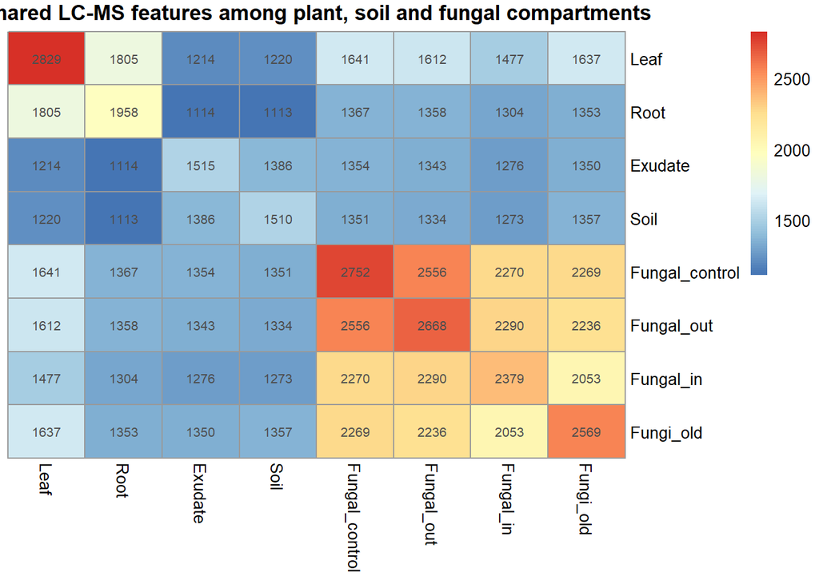

```r
pheatmap(
  pairwise_overlap_matrix,
  cluster_rows = FALSE,
  cluster_cols = FALSE,
  display_numbers = TRUE,
  number_format = "%.0f",
  main =
    "Shared LC-MS features among plant, soil and fungal compartments"
)
```

Which sample types have the most chemistry in common?

129. Calculate percent overlap

Raw counts are useful, but percent overlap can also help.

For each pair, use the smaller feature set as the denominator:

```r
pairwise_percent_overlap <-
  matrix(
    NA_real_,
    nrow = ncol(presence_matrix_numeric),
    ncol = ncol(presence_matrix_numeric)
  )

rownames(pairwise_percent_overlap) <-
  colnames(presence_matrix_numeric)

colnames(pairwise_percent_overlap) <-
  colnames(presence_matrix_numeric)
```

Calculate:

```r
for (
  i in seq_len(
    ncol(presence_matrix_numeric)
  )
) {

  for (
    j in seq_len(
      ncol(presence_matrix_numeric)
    )
  ) {

    overlap <-
      sum(
        presence_matrix_numeric[, i] == 1 &
          presence_matrix_numeric[, j] == 1
      )

    smaller_total <-
      min(
        sum(
          presence_matrix_numeric[, i]
        ),
        sum(
          presence_matrix_numeric[, j]
        )
      )

    pairwise_percent_overlap[i, j] <-
      100 *
      overlap /
      smaller_total
  }
}
```

View:

```r
round(
  pairwise_percent_overlap,
  1
)
```

```
##                 Leaf  Root Exudate  Soil Fungal_control Fungal_out Fungal_in
## Leaf           100.0  92.2    80.1  80.8           59.6       60.4      62.1
## Root            92.2 100.0    73.5  73.7           69.8       69.4      66.6
## Exudate         80.1  73.5   100.0  91.8           89.4       88.6      84.2
## Soil            80.8  73.7    91.8 100.0           89.5       88.3      84.3
## Fungal_control  59.6  69.8    89.4  89.5          100.0       95.8      95.4
## Fungal_out      60.4  69.4    88.6  88.3           95.8      100.0      96.3
## Fungal_in       62.1  66.6    84.2  84.3           95.4       96.3     100.0
## Fungi_old       63.7  69.1    89.1  89.9           88.3       87.0      86.3
##                Fungi_old
## Leaf                63.7
## Root                69.1
## Exudate             89.1
## Soil                89.9
## Fungal_control      88.3
## Fungal_out          87.0
## Fungal_in           86.3
## Fungi_old          100.0
```

Heatmap:

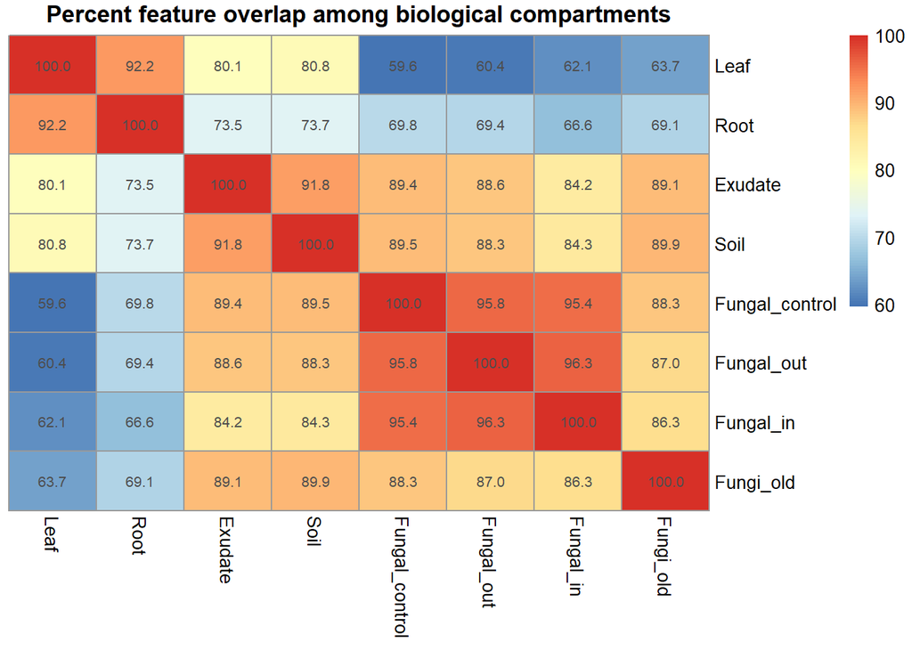

```r
pheatmap(
  pairwise_percent_overlap,
  cluster_rows = FALSE,
  cluster_cols = FALSE,
  display_numbers = TRUE,
  number_format = "%.1f",
  main =
    "Percent feature overlap among biological compartments"
)
```

130. Plant-specific feature-pattern table

Now summarize just:

Leaf Root Exudate Soil

```r
plant_pattern_detailed <- cross_compartment_presence %>%
  mutate(

    plant_detection_pattern =
      paste0(
        ifelse(
          leaf_present,
          "Leaf ",
          ""
        ),

        ifelse(
          root_present,
          "Root ",
          ""
        ),

        ifelse(
          exudate_present,
          "Exudate ",
          ""
        ),

        ifelse(
          soil_present,
          "Soil",
          ""
        )
      )
  ) %>%

  count(
    plant_detection_pattern,
    sort = TRUE
  )

plant_pattern_detailed
```

```
## # A tibble: 16 × 2
##    plant_detection_pattern      n
##    <chr>                    <int>
##  1 "Leaf Root Exudate Soil"   989
##  2 ""                         900
##  3 "Leaf "                    818
##  4 "Leaf Root "               709
##  5 "Exudate Soil"             187
##  6 "Leaf Exudate Soil"        143
##  7 "Root "                     78
##  8 "Root Exudate Soil"         67
##  9 "Leaf Root Soil"            54
## 10 "Leaf Root Exudate "        53
## 11 "Exudate "                  42
## 12 "Leaf Soil"                 34
## 13 "Soil"                      33
## 14 "Leaf Exudate "             29
## 15 "Root Exudate "              5
## 16 "Root Soil"                  3
```

This tells you how many features are:

Leaf only Root only Leaf + root Root + exudate Leaf + root + exudate Exudate + soil all four etc.

131. Fungal-specific feature-pattern table

Do the same for:

Fungal control Fungal out Fungal in Fungi old

```r
fungal_pattern_detailed <- cross_compartment_presence %>%
  mutate(

    fungal_detection_pattern =
      paste0(

        ifelse(
          fungal_control_present,
          "Control ",
          ""
        ),

        ifelse(
          fungal_out_present,
          "Out ",
          ""
        ),

        ifelse(
          fungal_in_present,
          "In ",
          ""
        ),

        ifelse(
          fungi_old_present,
          "Old",
          ""
        )
      )
  ) %>%

  count(
    fungal_detection_pattern,
    sort = TRUE
  )

fungal_pattern_detailed
```

```
## # A tibble: 16 × 2
##    fungal_detection_pattern     n
##    <chr>                    <int>
##  1 "Control Out In Old"      1960
##  2 ""                        1023
##  3 "Control Out In "          274
##  4 "Control Out Old"          211
##  5 "Old"                      204
##  6 "Control Out "             111
##  7 "Control "                  84
##  8 "Control Old"               76
##  9 "Out In Old"                40
## 10 "In Old"                    31
## 11 "Out "                      31
## 12 "Out Old"                   25
## 13 "Control In Old"            22
## 14 "In "                       22
## 15 "Out In "                   16
## 16 "Control In "               14
```

This is extremely useful for explaining fungal chemistry.

132. Plot the top fungal detection patterns

```r
fungal_pattern_plot_data <-
  fungal_pattern_detailed %>%
  filter(
    fungal_detection_pattern != ""
  ) %>%
  slice_head(
    n = 15
  )
```

Plot:

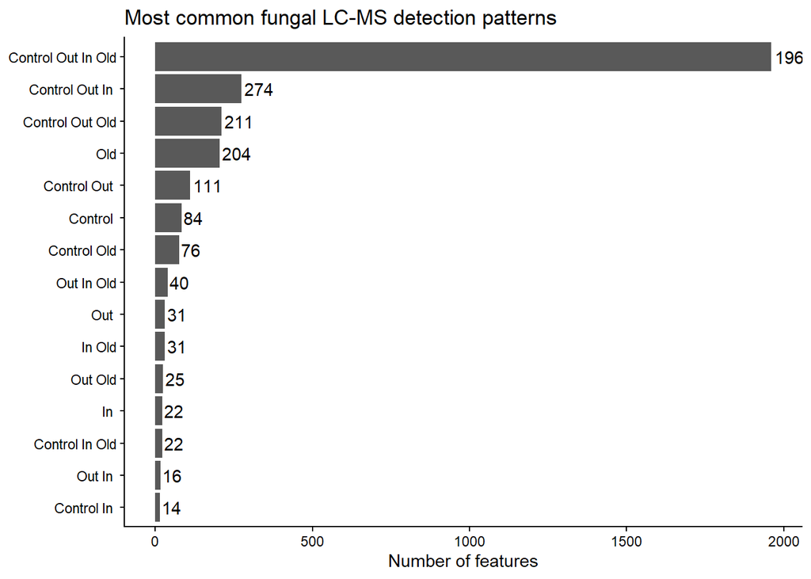

```r
fungal_pattern_plot <- ggplot(
  fungal_pattern_plot_data,
  aes(
    x = reorder(
      fungal_detection_pattern,
      n
    ),
    y = n
  )
) +

  geom_col() +

  coord_flip() +

  geom_text(
    aes(label = n),
    hjust = -0.1
  ) +

  labs(
    title =
      "Most common fungal LC-MS detection patterns",
    x = NULL,
    y = "Number of features"
  ) +

  theme_classic()

fungal_pattern_plot
```

133. Plot the top plant detection patterns

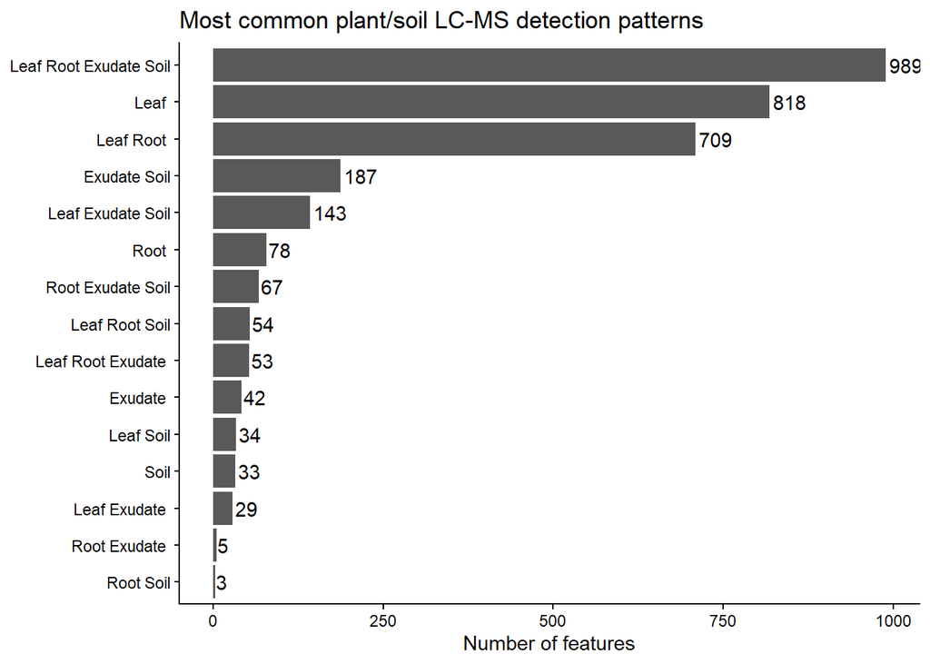

```r
plant_pattern_plot_data <-
  plant_pattern_detailed %>%
  filter(
    plant_detection_pattern != ""
  ) %>%
  slice_head(
    n = 15
  )
plant_pattern_plot <- ggplot(
  plant_pattern_plot_data,
  aes(
    x = reorder(
      plant_detection_pattern,
      n
    ),
    y = n
  )
) +

  geom_col() +

  coord_flip() +

  geom_text(
    aes(label = n),
    hjust = -0.1
  ) +

  labs(
    title =
      "Most common plant/soil LC-MS detection patterns",
    x = NULL,
    y = "Number of features"
  ) +

  theme_classic()

plant_pattern_plot
```

134. Strict cross-system candidate table

These are the four, and this is where you explain exactly what “four” means.

```r
strict_cross_system_candidates <-
  root_exudate_fungal_not_controls %>%

  select(
    feature_name,
    `Average Rt(min)`,
    `Average Mz`,
    `Metabolite name`,
    `Adduct type`,
    `MS/MS assigned`,
    Formula,
    Ontology,
    `Total score`,
    sample_to_blank_ratio,

    leaf_n,
    root_n,
    exudate_n,
    soil_n,

    fungal_control_n,
    fungal_out_n,
    fungal_in_n,
    fungi_old_n
  )

strict_cross_system_candidates
```

```
## # A tibble: 4 × 18
##   feature_name    `Average Rt(min)` `Average Mz` `Metabolite name` `Adduct type`
##   <chr>                       <dbl>        <dbl> <chr>             <chr>
## 1 F1105_mz156.98…             0.514         157. Unknown           [M+H]+
## 2 F3005_mz294.00…             0.456         294. Unknown           [M+H]+
## 3 F3515_mz335.22…             3.55          335. Unknown           [M+H]+
## 4 F5091_mz739.74…             9.70          740. Unknown           [M+H]+
## # ℹ 13 more variables: `MS/MS assigned` <lgl>, Formula <chr>, Ontology <chr>,
## #   `Total score` <chr>, sample_to_blank_ratio <dbl>, leaf_n <dbl>,
## #   root_n <dbl>, exudate_n <dbl>, soil_n <dbl>, fungal_control_n <dbl>,
## #   fungal_out_n <dbl>, fungal_in_n <dbl>, fungi_old_n <dbl>
```

Add a descriptive column:

```r
strict_cross_system_candidates <-
  strict_cross_system_candidates %>%
  mutate(

    interpretation =
      "Root + exudate + fungal-associated; not consistently detected in soil or fungal control"
  )
```

135. Cross-system candidate boxplots

You’ve already generated this, but save a presentation-quality copy:

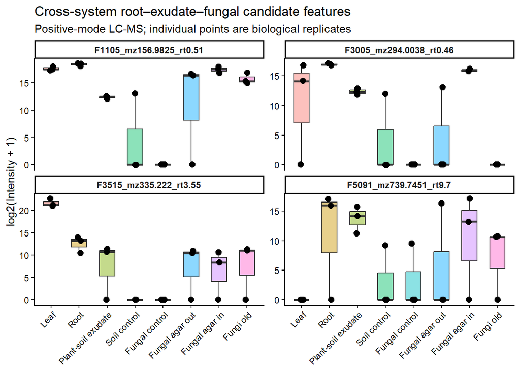

```r
cross_system_candidate_plot <- ggplot(
  cross_candidate_plot_data,
  aes(
    x = group,
    y = log2_intensity,
    fill = group
  )
) +

  geom_boxplot(
    width = 0.55,
    outlier.shape = NA,
    alpha = 0.45
  ) +

  geom_jitter(
    width = 0.08,
    size = 2.5
  ) +

  facet_wrap(
    ~ feature_name,
    scales = "free_y",
    ncol = 2
  ) +

  labs(
    title =
      "Cross-system root–exudate–fungal candidate features",

    subtitle =
      "Positive-mode LC-MS; individual points are biological replicates",

    x = NULL,

    y =
      "log2(Intensity + 1)"
  ) +

  theme_classic() +

  theme(
    legend.position = "none",

    axis.text.x =
      element_text(
        angle = 45,
        hjust = 1
      ),

    strip.text =
      element_text(
        face = "bold"
      )
  )

cross_system_candidate_plot
```

Save:

```r
ggsave(
  "PI_figure_cross_system_candidates.png",
  cross_system_candidate_plot,
  width = 12,
  height = 8,
  dpi = 300
)
```

136. Summarize exudate-vs-soil detection evidence

You already obtained:

129 exudate-associated 124 soil-associated 1,386 quantifiable in both 2,505 not consistently detected in either.

Let’s turn that into a PI figure.

```r
exudate_soil_detection_PI <-
  prepared_comparisons$
    Exudate_vs_Soil$
    detection_summary

exudate_soil_detection_PI
```

```
## # A tibble: 4 × 3
##   detection_category                      n percent
##   <chr>                               <int>   <dbl>
## 1 Exudate-associated detection          129    3.11
## 2 Not consistently detected in either  2505   60.4
## 3 Quantifiable in both                 1386   33.4
## 4 Soil-associated detection             124    2.99
```

Plot:

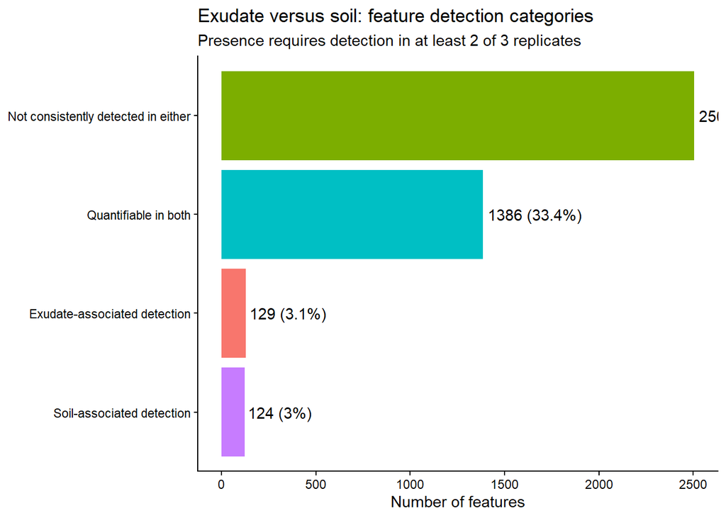

```r
exudate_soil_detection_plot <- ggplot(
  exudate_soil_detection_PI,
  aes(
    x = reorder(
      detection_category,
      n
    ),
    y = n,
    fill = detection_category
  )
) +

  geom_col() +

  coord_flip() +

  geom_text(
    aes(
      label = paste0(
        n,
        " (",
        round(
          percent,
          1
        ),
        "%)"
      )
    ),
    hjust = -0.05
  ) +

  labs(
    title =
      "Exudate versus soil: feature detection categories",
    subtitle =
      "Presence requires detection in at least 2 of 3 replicates",
    x = NULL,
    y = "Number of features"
  ) +

  theme_classic() +

  theme(
    legend.position = "none"
  )

exudate_soil_detection_plot
```

137. Exudate-vs-soil quantitative evidence tiers

You already obtained:

Tier 1 1 Tier 3 159 Tier 4 215 Tier 5 1011